# Analyses in Perceiving through the Grapevine: A Network Approach to Reputations (Revision 1)

Cory K. Costello & Sanjay Srivastava

last knitted: 2020-06-17 19:21:52

# Data & Libraries

Here I’ll read in the data and load the libraries I’ll use, including the `ReputationModelR` package I created for these analyses.

```r
set.seed(42)
knitr::opts_chunk$set(message = FALSE, warning = FALSE, cache = TRUE, cache.extra = knitr::rand_seed)
# Make sure necessary packages are installed
if("rio" %in% installed.packages()[,1] == FALSE){install.packages("rio")}
if("magrittr" %in% installed.packages()[,1] == FALSE){install.packages("tidyverse")}
if("ReputationModelR" %in% installed.packages()[,1] == FALSE){devtools::install_github("Coryc3133/ReputationModelR")}
if("lme4" %in% installed.packages()[,1] == FALSE){install.packages("lme4")}
if("lmerTest" %in% installed.packages()[,1] == FALSE){install.packages("lmerTest")}
if("broom.mixed" %in% installed.packages()[,1] == FALSE){install.packages("broom.mixed")}
if("kableExtra" %in% installed.packages()[,1] == FALSE){install.packages("kableExtra")}
library(rio)
library(tidyverse)
library(ReputationModelR)
library(lme4)
library(lmerTest)
library(kableExtra)
study1 <- import("Data/rep_s1_4ms.csv") %>%
  mutate(study = "study 1")
study2 <- import("Data/rep_s2_4ms.csv") %>%
  # missing condition are "", but need to be NA
  mutate(condition = ifelse(condition == "", NA, condition),
         study = "study 2")
item_pos <- import("Data/rep_BigSix_Evaluativeness.csv")
```

## Reshape Study 1 Data for Profile Analyses

```r
study1_profiles <-
  study1 %>%
  select(sess_id, contains("bfi")) %>%
  gather(var, rating, -sess_id) %>%
  separate(var, c("perceiver", "target", "item"),
           extra = "merge") %>%
  filter(target == "A" | target == "C") %>%
  mutate(triad_id =
           case_when(target == "A" ~ "ACD",
                     target == "C" ~ "CAB"),
         rating_type =
           case_when(perceiver == target ~ "self",
                     perceiver == "B" ~ "p2",
                     perceiver == "D" ~ "p2",
                     TRUE ~ "p1")) %>%
  select(sess_id, triad_id, item,
         rating_type, rating) %>%
  spread(rating_type, rating) %>%
  # center ratings
  mutate(p1_uncent = p1,
         p1 = p1 - mean(p1, na.rm = TRUE),
         p2_uncent = p2,
         p2 = p2 - mean(p2, na.rm = TRUE),
         self_uncent =  self,
         self = self - mean(self, na.rm = TRUE)) %>%
  # calculate normative and distinctive profiles
  group_by(item) %>%
  mutate(self_norm = mean(self, na.rm = TRUE),
         self_dist = self - self_norm,
         p1_norm = mean(p1, na.rm = TRUE),
         p1_dist = p1 - p1_norm)
```

## Reshape Study 2 Data for Profile Analyses

```r
study2_profiles <-
  study2 %>%
  select(sess_id, contains("bfi")) %>%
  gather(var, rating, -sess_id) %>%
  separate(var, c("perceiver", "target", "item"),
           extra = "merge") %>%
  filter(target == "A" | target == "C") %>%
  mutate(triad_id =
           case_when(target == "A" ~ "ACD",
                     target == "C" ~ "CAB"),
         rating_type =
           case_when(perceiver == target ~ "self",
                     perceiver == "B" ~ "p2",
                     perceiver == "D" ~ "p2",
                     TRUE ~ "p1")) %>%
  select(sess_id, triad_id, item,
         rating_type, rating) %>%
  spread(rating_type, rating) %>%
  # center ratings
  mutate(p1_uncent = p1,
         p1 = p1 - mean(p1, na.rm = TRUE),
         p2_uncent = p2,
         p2 = p2 - mean(p2, na.rm = TRUE),
         self_uncent =  self,
         self = self - mean(self, na.rm = TRUE)) %>%
  # calculate normative and distinctive profiles
  group_by(item) %>%
  mutate(self_norm = mean(self, na.rm = TRUE),
         self_dist = self - self_norm,
         p1_norm = mean(p1, na.rm = TRUE),
         p1_dist = p1 - p1_norm)
```

## ICCs and profile for Item Positivity

### ICC

```r
item_pos %>%
  t() %>%
  psych::ICC()
```

```
## Call: psych::ICC(x = .)
##
## Intraclass correlation coefficients
##                          type  ICC  F df1 df2        p lower bound upper bound
## Single_raters_absolute   ICC1 0.74 38  68 828 9.1e-210        0.68        0.80
## Single_random_raters     ICC2 0.74 38  68 816 3.5e-208        0.68        0.80
## Single_fixed_raters      ICC3 0.74 38  68 816 3.5e-208        0.68        0.80
## Average_raters_absolute ICC1k 0.97 38  68 828 9.1e-210        0.97        0.98
## Average_random_raters   ICC2k 0.97 38  68 816 3.5e-208        0.97        0.98
## Average_fixed_raters    ICC3k 0.97 38  68 816 3.5e-208        0.97        0.98
##
##  Number of subjects = 69     Number of Judges =  13
```

### Calculating Item Positivity Profile

```r
item_pos_prof <- item_pos %>%
  gather(item, rating, -subj) %>%
  # mean center it
  mutate(rating_cent = rating - mean(rating, na.rm = TRUE)) %>%
  group_by(item) %>%
  summarize(pos = mean(rating_cent, na.rm = TRUE),
            pos_uncent = mean(rating, na.rm = TRUE)) %>%
  mutate(item = str_to_lower(item),
         item = str_replace_all(item, "bfie_", "bfi_"))
```

#### Joining to other data

```r
# study 1
study1_profiles <- study1_profiles %>%
  left_join(item_pos_prof)

# study 2
study2_profiles <- study2_profiles %>%
  left_join(item_pos_prof)
```

## Calculate Scale Scores

Here I’ll score the BFI into domain scores and the IRI into its subscales. I’ll also produce coefficeint alphas and basic descriptives.

I’m going to use the `scoreItems()` function from the `psych` package. This both reverse scores items and calculates scale scores. It also provide some information about the scores.

### Study 1 Data: Score Big Six Domains

- agreeableness = 2, 7, 12R, 17R, 22R, 27, 32, 37R, 42R, 47R, 52, 57
- conscientiousness = 3R, 8R, 13, 18, 23R, 28R, 33, 38, 43, 48R, 53, 58R
- hp = HP45r HP46r HP47r HP48r HP49r HP50 HP51 HP52
- neuroticism = 4R, 9R, 14, 19, 24R, 29R, 34, 39, 44R, 49R, 54, 59
- extraversion = 1, 6, 11R, 16R, 21, 26R, 31R, 36R, 41, 46, 51R, 56
- openness = 5R, 10, 15, 20, 25R, 30R, 35, 40, 45R, 50R, 55R, 60

For now, first make the key:

```r
# Make keys
big6_keys <- list(
                 agreeableness = c("bfi_2", "bfi_7", "-bfi_12", "-bfi_17",
                                   "-bfi_22", "bfi_27", "bfi_32", "-bfi_37",
                                   "-bfi_42", "-bfi_47", "bfi_52", "bfi_57"),
                 conscientiousness = c("-bfi_3", "-bfi_8", "bfi_13", "bfi_18",
                                       "-bfi_23", "-bfi_28", "bfi_33", "bfi_38",
                                       "bfi_43", "-bfi_48", "bfi_53", "-bfi_58"),
                 hp = c("-bfi_hp45", "-bfi_hp46", "-bfi_hp47", "-bfi_hp48",
                            "-bfi_hp49", "bfi_hp50", "bfi_hp51", "bfi_hp52"),
                 neuroticism = c("-bfi_4", "-bfi_9", "bfi_14", "bfi_19",
                                 "-bfi_24", "-bfi_29", "bfi_34", "bfi_39",
                                 "-bfi_44", "-bfi_49", "bfi_54", "bfi_59"),
                 extraversion = c("bfi_1", "bfi_6", "-bfi_11", "-bfi_16",
                                  "bfi_21", "-bfi_26", "-bfi_31", "-bfi_36",
                                  "bfi_41", "bfi_46", "-bfi_51", "bfi_56"),
                 openness = c("-bfi_5", "bfi_10", "bfi_15", "bfi_20",
                              "-bfi_25", "-bfi_30", "bfi_35", "bfi_40",
                              "-bfi_45", "-bfi_50", "-bfi_55", "bfi_60"))
```

Next, I’ll score the Big Six. I’ll turn the data into long format to make things a little easier, since it’s the same scoring used for all of the Big Six ratings.

```r
# Lengthen Data
study1_big6_long <-
study1 %>%
  select(sess_id, contains("bfi")) %>%
  gather(variable, rating, -sess_id) %>%
  separate(variable,
           c("perceiver", "target", "item"),
           extra = "merge") %>%
  spread(item, rating)

# Score long data and bind the scores to
# the end of the long data, then widen it back out
# and call it study1, replacing the raw data
study1 <-
  psych::scoreItems(big6_keys,
                    items = study1_big6_long,
                    impute = "none") %>%
  .[["scores"]] %>%
  cbind(study1_big6_long, .) %>%
  gather(variable, rating, -(1:3)) %>%
  unite(variable, perceiver, target, variable) %>%
  spread(variable, rating) %>%
  select(sess_id,
         ends_with("agreeableness"),
         ends_with("conscientiousness"),
         ends_with("hp"),
         ends_with("neuroticism"),
         ends_with("extraversion"),
         ends_with("openness")) %>%
  right_join(study1)
```

Finally, I’ll get the coefficient alphas for each subscale.

```r
library(kableExtra)

study1_big6_long %>%
  mutate(rating_type = case_when(perceiver == target ~ "Self",
                               perceiver == "A" & target == "C" |
                                 perceiver == "C" & target == "A" ~ "P1",
                               perceiver == "B" & target == "C" |
                                 perceiver == "D" & target == "A" ~ "P2")) %>%
  split(.$rating_type) %>%
  map_df(~ psych::scoreItems(big6_keys,
                          items = .,
                          impute = "none") %>% pluck("alpha")) %>%
  mutate(domain = names(big6_keys),
         domain = ifelse(domain == "hp", "honesty-propriety", domain)) %>%
  gather(report, alpha, -domain) %>%
  mutate(report = fct_relevel(report,
                              "Self",
                              "P1",
                              "P2")) %>%
  select(report, domain, alpha) %>%
  arrange(report) %>%
  knitr::kable(digits = c(NA, NA, 2),
               caption = "Coefficient Alphas for Big Six Ratings Study 1",
               format = "html", escape = F) %>%
  kable_styling("striped", full_width = F)
```

Coefficient Alphas for Big Six Ratings Study 1

| report | domain | alpha |
| --- | --- | --- |
| Self | agreeableness | 0.76 |
| Self | conscientiousness | 0.83 |
| Self | honesty-propriety | 0.61 |
| Self | neuroticism | 0.89 |
| Self | extraversion | 0.87 |
| Self | openness | 0.81 |
| P1 | agreeableness | 0.80 |
| P1 | conscientiousness | 0.83 |
| P1 | honesty-propriety | 0.66 |
| P1 | neuroticism | 0.75 |
| P1 | extraversion | 0.88 |
| P1 | openness | 0.78 |
| P2 | agreeableness | 0.84 |
| P2 | conscientiousness | 0.89 |
| P2 | honesty-propriety | 0.75 |
| P2 | neuroticism | 0.87 |
| P2 | extraversion | 0.89 |
| P2 | openness | 0.83 |

### Study 1 Data: Calculate scale scores: IRI

- Empathic Concern = q2_emp, q4_empr, q9_emp, q14_empr, q18_empr, q20_emp, q22_emp
- Fantasy Scale = q1_fs, q5_fs, q7_fsr, q12_fsr, q16_fs, q23_fs, q26_fs
- Personal Distress = q6_pd, q10_pd, q13_pdr, q17_pd, q19_pdr, q24_pd, q27_pd
- Perspective Taking = q3_ptr, q8_pt, q11_pt, q15_ptr, q21_pt, q25_pt, q28_pt

Using the `scoreItems()` function from the psych package again. Then, Ill save out and cbind the scores to the data, and produce a table for the alphas.

First make the key:

```r
iri_keys <- list(
  iri_empathic = c("q2_emp", "-q4_emp", "q9_emp", "-q14_emp", "-q18_emp", "q20_emp", "q22_emp"),
  iri_fantasy = c("q1_fs", "q5_fs", "-q7_fs", "-q12_fs", "q16_fs", "q23_fs", "q26_fs"),
  iri_distress = c("q6_pd", "q10_pd", "-q13_pd", "q17_pd", "-q19_pd", "q24_pd", "q27_pd"),
  iri_perspective = c("-q3_pt", "q8_pt", "q11_pt", "-q15_pt", "q21_pt", "q25_pt", "q28_pt")
)
```

Next, I’ll score the IRI. I’ll turn the data into long format like above with the Big Six.

```r
# Lengthen Data
study1_iri_long <-
study1 %>%
  select(sess_id, starts_with("B_q"), starts_with("D_q")) %>%
  gather(variable, rating, -sess_id) %>%
  separate(variable,
           c("perceiver", "item"),
           extra = "merge") %>%
  spread(item, rating)

# Score long data and bind the scores to
# the end of the long data, then widen it back out
# and call it study1, replacing the raw data
study1 <-
  psych::scoreItems(iri_keys,
                    items = study1_iri_long,
                    impute = "none") %>%
  .[["scores"]] %>%
  cbind(study1_iri_long, .) %>%
  gather(variable, rating, -(1:2)) %>%
  unite(variable, perceiver, variable) %>%
  spread(variable, rating) %>%
  select(sess_id, contains("iri")) %>%
  right_join(study1)
```

Finally, I’ll get the coefficient alphas for each subscale.

```r
library(kableExtra)

 psych::scoreItems(iri_keys,
                    items = study1_iri_long,
                    impute = "none") %>%
  .[["alpha"]] %>%
   as_tibble() %>%
   gather(subscale, alpha) %>%
   mutate(subscale =
            case_when(subscale == "iri_empathic" ~ "empathic concern",
                      subscale == "iri_fantasy" ~ "fantasy",
                      subscale == "iri_distress" ~ "distress tolerance",
                      subscale == "iri_perspective" ~ "perspective taking")) %>%
  knitr::kable(digits = c(NA, 2),
               caption = "Coefficient Alphas for Perspective Taking Study 1",
               format = "html", escape = F) %>%
  kable_styling("striped", full_width = F)
```

Coefficient Alphas for Perspective Taking Study 1

| subscale | alpha |
| --- | --- |
| empathic concern | 0.73 |
| fantasy | 0.82 |
| distress tolerance | 0.82 |
| perspective taking | 0.76 |

### Study 2 Data: Score Big Six Domains

```r
# Lengthen Data
study2_big6_long <-
study2 %>%
  select(sess_id, contains("bfi")) %>%
  gather(variable, rating, -sess_id) %>%
  separate(variable,
           c("perceiver", "target", "item"),
           extra = "merge") %>%
  spread(item, rating)

# Score long data and bind the scores to
# the end of the long data, then widen it back out
# and call it study2, replacing the raw data
study2 <-
  psych::scoreItems(big6_keys,
                    items = study2_big6_long,
                    impute = "none") %>%
  .[["scores"]] %>%
  cbind(study2_big6_long, .) %>%
  gather(variable, rating, -(1:3)) %>%
  unite(variable, perceiver, target, variable) %>%
  spread(variable, rating) %>%
  select(sess_id,
         ends_with("agreeableness"),
         ends_with("conscientiousness"),
         ends_with("hp"),
         ends_with("neuroticism"),
         ends_with("extraversion"),
         ends_with("openness")) %>%
  right_join(study2)
```

Finally, I’ll get the coefficient alphas for each subscale.

```r
library(kableExtra)

study2_big6_long %>%
  mutate(rating_type = case_when(perceiver == target ~ "Self",
                               perceiver == "A" & target == "C" |
                                 perceiver == "C" & target == "A" ~ "P1",
                               perceiver == "B" & target == "C" |
                                 perceiver == "D" & target == "A" ~ "P2")) %>%
  split(.$rating_type) %>%
  map_df(~ psych::scoreItems(big6_keys,
                          items = .,
                          impute = "none") %>% pluck("alpha")) %>%
  mutate(domain = names(big6_keys),
         domain = ifelse(domain == "hp", "honesty-propriety", domain)) %>%
  gather(report, alpha, -domain) %>%
  mutate(report = fct_relevel(report,
                              "Self",
                              "P1",
                              "P2")) %>%
  select(report, domain, alpha) %>%
  arrange(report) %>%
  knitr::kable(digits = c(NA, NA, 2),
               caption = "Coefficient Alphas for Big Six Ratings Study 2",
               format = "html", escape = F) %>%
  kable_styling("striped", full_width = F)
```

Coefficient Alphas for Big Six Ratings Study 2

| report | domain | alpha |
| --- | --- | --- |
| Self | agreeableness | 0.76 |
| Self | conscientiousness | 0.86 |
| Self | honesty-propriety | 0.62 |
| Self | neuroticism | 0.88 |
| Self | extraversion | 0.87 |
| Self | openness | 0.81 |
| P1 | agreeableness | 0.82 |
| P1 | conscientiousness | 0.88 |
| P1 | honesty-propriety | 0.76 |
| P1 | neuroticism | 0.84 |
| P1 | extraversion | 0.88 |
| P1 | openness | 0.87 |
| P2 | agreeableness | 0.83 |
| P2 | conscientiousness | 0.91 |
| P2 | honesty-propriety | 0.79 |
| P2 | neuroticism | 0.83 |
| P2 | extraversion | 0.91 |
| P2 | openness | 0.77 |

### Study 2 Data: Calculate scale scores: IRI

Same keys as before

Next, I’ll score the IRI. I’ll turn the data into long format like above with the Big Six.

```r
# Lengthen Data
study2_iri_long <-
study2 %>%
  select(sess_id, starts_with("B_q"), starts_with("D_q")) %>%
  gather(variable, rating, -sess_id) %>%
  separate(variable,
           c("perceiver", "item"),
           extra = "merge") %>%
  spread(item, rating)

# Score long data and bind the scores to
# the end of the long data, then widen it back out
# and call it study2, replacing the raw data
study2 <-
  psych::scoreItems(iri_keys,
                    items = study2_iri_long,
                    impute = "none") %>%
  .[["scores"]] %>%
  cbind(study2_iri_long, .) %>%
  gather(variable, rating, -(1:2)) %>%
  unite(variable, perceiver, variable) %>%
  spread(variable, rating) %>%
  select(sess_id, contains("iri")) %>%
  right_join(study2)
```

Finally, I’ll get the coefficient alphas for each subscale.

```r
psych::scoreItems(iri_keys,
                    items = study2_iri_long,
                    impute = "none") %>%
  .[["alpha"]] %>%
   as_tibble() %>%
   gather(subscale, alpha) %>%
   mutate(subscale =
            case_when(subscale == "iri_empathic" ~ "empathic concern",
                      subscale == "iri_fantasy" ~ "fantasy",
                      subscale == "iri_distress" ~ "distress tolerance",
                      subscale == "iri_perspective" ~ "perspective taking")) %>%
  knitr::kable(digits = c(NA, 2),
               caption = "Coefficient Alphas for Perspective Taking Study 2",
               format = "html", escape = F) %>%
  kable_styling("striped", full_width = F)
```

Coefficient Alphas for Perspective Taking Study 2

| subscale | alpha |
| --- | --- |
| empathic concern | 0.70 |
| fantasy | 0.82 |
| distress tolerance | 0.78 |
| perspective taking | 0.75 |

# Hearsay SAM with Integrated (combined Study 1 & 2 data)

## functions for tables

```r
lm_beta_lmer <- function(mod) {
   b <- fixef(mod)[-1]
   sd.x <- apply(getME(mod,"X")[,-1],2,sd)
   sd.y <- sd(getME(mod,"y"))
   b*sd.x/sd.y
}

fixed_coefs_tbl <- function(model){
  model %>%
  broom.mixed::tidy(effects = "fixed", conf.int = TRUE) %>%
  transmute(
    term = term,
    est = estimate,
    ci_ll = conf.low,
    ci_ul = conf.high,
    se = std.error,
    t = statistic,
    df = df,
    p = p.value,
  ) %>%
  mutate(std_est = c(0, lm_beta_lmer(model)),
         p = ifelse(p > .001, round(p, 3), "<.001"),
         component = case_when(
           term == "(Intercept)" ~ "intercept",
           term == "self_norm" ~ "Normative Accuracy",
           term == "self_dist" ~ "Distinctive Accuracy",
           term == "p1_norm" ~ "Normative Consensus",
           term == "p1_dist" ~ "Distinctive Consensus",
           term == "pos" ~ "Positivity Bias",
           term == "distancep2" ~ "Distance (P1 vs. P2)",
           term == "self_norm:distancep2" ~ "Distance X Normative Accuracy",
           term == "self_dist:distancep2" ~ "Distance X Distinctive Accuracy",
           term == "pos:distancep2" ~ "Distance X Positivity Bias",
           # extraversion moderators
           term == "t_ext_cent" ~ "Target Extraversion",
           term == "p1_norm:t_ext_cent" ~ "Target Extraversion X Normative Consensus",
           term == "p1_dist:t_ext_cent" ~ "Target Extraversion X Distinctive Consensus",
           term == "pos:t_ext_cent" ~ "Target Extraversion X Positivity Bias",
           term == "t_ext_cent" ~ "Target Extraversion",
           term == "self_norm:t_ext_cent" ~ "Target Extraversion X Normative Accuracy",
           term == "self_dist:t_ext_cent" ~ "Target Extraversion X Distinctive Accuracy",
           term == "pos:t_ext_cent" ~ "Target Extraversion X Positivity Bias",
           term == "p1_ext_cent" ~ "P1 Extraversion",
           term == "p1_norm:p1_ext_cent" ~ "P1 Extraversion X Normative Consensus",
           term == "p1_dist:p1_ext_cent" ~ "P1 Extraversion X Distinctive Consensus",
           term == "pos:p1_ext_cent" ~ "P1 Extraversion X Positivity Bias",
           term == "p1_ext_cent" ~ "P1 Extraversion",
           term == "self_norm:p1_ext_cent" ~ "P1 Extraversion X Normative Accuracy",
           term == "self_dist:p1_ext_cent" ~ "P1 Extraversion X Distinctive Accuracy",
           term == "pos:p1_ext_cent" ~ "P1 Extraversion X Positivity Bias",
           term == "p2_ext_cent" ~ "P2 Extraversion",
           term == "p1_norm:p2_ext_cent" ~ "P2 Extraversion X Normative Consensus",
           term == "p1_dist:p2_ext_cent" ~ "P2 Extraversion X Distinctive Consensus",
           term == "pos:p2_ext_cent" ~ "P2 Extraversion X Positivity Bias",
           term == "p2_ext_cent" ~ "P2 Extraversion",
           term == "self_norm:p2_ext_cent" ~ "P2 Extraversion X Normative Accuracy",
           term == "self_dist:p2_ext_cent" ~ "P2 Extraversion X Distinctive Accuracy",
           term == "pos:p2_ext_cent" ~ "P2 Extraversion X Positivity Bias",
           # empathy moderators
           term == "distress_cent" ~ "P2 Distress",
           term == "p1_norm:distress_cent" ~ "P2 Distress X Normative Consensus",
           term == "p1_dist:distress_cent" ~ "P2 Distress X Distinctive Consensus",
           term == "pos:distress_cent" ~ "P2 Distress X Positivity Bias",
           term == "distress_cent" ~ "P2 Distress",
           term == "self_norm:distress_cent" ~ "P2 Distress X Normative Accuracy",
           term == "self_dist:distress_cent" ~ "P2 Distress X Distinctive Accuracy",
           term == "pos:distress_cent" ~ "P2 Distress X Positivity Bias",
           term == "fantasy_cent" ~ "P2 Fantasy",
           term == "p1_norm:fantasy_cent" ~ "P2 Fantasy X Normative Consensus",
           term == "p1_dist:fantasy_cent" ~ "P2 Fantasy X Distinctive Consensus",
           term == "pos:fantasy_cent" ~ "P2 Fantasy X Positivity Bias",
           term == "fantasy_cent" ~ "P2 Fantasy",
           term == "self_norm:fantasy_cent" ~ "P2 Fantasy X Normative Accuracy",
           term == "self_dist:fantasy_cent" ~ "P2 Fantasy X Distinctive Accuracy",
           term == "pos:fantasy_cent" ~ "P2 Fantasy X Positivity Bias",
           term == "empathic_cent" ~ "P2 Empathic Concern",
           term == "p1_norm:empathic_cent" ~ "P2 Empathic Concern X Normative Consensus",
           term == "p1_dist:empathic_cent" ~ "P2 Empathic Concern X Distinctive Consensus",
           term == "pos:empathic_cent" ~ "P2 Empathic Concern X Positivity Bias",
           term == "empathic_cent" ~ "P2 Empathic Concern",
           term == "self_norm:empathic_cent" ~ "P2 Empathic Concern X Normative Accuracy",
           term == "self_dist:empathic_cent" ~ "P2 Empathic Concern X Distinctive Accuracy",
           term == "pos:empathic_cent" ~ "P2 Empathic Concern X Positivity Bias",
           term == "perspective_cent" ~ "P2 Perspective Taking",
           term == "p1_norm:perspective_cent" ~ "P2 Perspective Taking X Normative Consensus",
           term == "p1_dist:perspective_cent" ~ "P2 Perspective Taking X Distinctive Consensus",
           term == "pos:perspective_cent" ~ "P2 Perspective Taking X Positivity Bias",
           term == "perspective_cent" ~ "P2 Perspective Taking",
           term == "self_norm:perspective_cent" ~ "P2 Perspective Taking X Normative Accuracy",
           term == "self_dist:perspective_cent" ~ "P2 Perspective Taking X Distinctive Accuracy",
           term == "pos:perspective_cent" ~ "P2 Perspective Taking X Positivity Bias"),
         term = case_when(
           term == "(Intercept)" ~ "$\\gamma_{000}$",
           term == "self_norm" ~ "$\\gamma_{100}$",
           term == "self_dist" ~ "$\\gamma_{200}$",
           term == "p1_norm" ~ "$\\gamma_{100}$",
           term == "p1_dist" ~ "$\\gamma_{200}$",
           term == "pos" ~ "$\\gamma_{300}$",
           term == "distancep2" ~ "$\\gamma_{010}$",
           term == "self_norm:distancep2" ~ "$\\gamma_{110}$",
           term == "self_dist:distancep2" ~ "$\\gamma_{210}$",
           term == "pos:distancep2" ~ "$\\gamma_{310}$",
                      # extraversion moderators
           term == "t_ext_cent" ~ "$\\gamma_{010}$",
           term == "p1_norm:t_ext_cent" ~ "$\\gamma_{110}$",
           term == "p1_dist:t_ext_cent" ~ "$\\gamma_{210}$",
           term == "pos:t_ext_cent" ~ "$\\gamma_{310}$",
           term == "t_ext_cent" ~ "$\\gamma_{010}$",
           term == "self_norm:t_ext_cent" ~ "$\\gamma_{110}$",
           term == "self_dist:t_ext_cent" ~ "$\\gamma_{210}$",
           term == "pos:t_ext_cent" ~ "$\\gamma_{310}$",
           term == "p1_ext_cent" ~ "$\\gamma_{010}$",
           term == "p1_norm:p1_ext_cent" ~ "$\\gamma_{110}$",
           term == "p1_dist:p1_ext_cent" ~ "$\\gamma_{210}$",
           term == "pos:p1_ext_cent" ~ "$\\gamma_{310}$",
           term == "p1_ext_cent" ~ "$\\gamma_{010}$",
           term == "self_norm:p1_ext_cent" ~ "$\\gamma_{110}$",
           term == "self_dist:p1_ext_cent" ~ "$\\gamma_{210}$",
           term == "pos:p1_ext_cent" ~ "$\\gamma_{310}$",
           term == "p2_ext_cent" ~ "$\\gamma_{010}$",
           term == "p1_norm:p2_ext_cent" ~ "$\\gamma_{110}$",
           term == "p1_dist:p2_ext_cent" ~ "$\\gamma_{210}$",
           term == "pos:p2_ext_cent" ~ "$\\gamma_{310}$",
           term == "p2_ext_cent" ~ "$\\gamma_{010}$",
           term == "self_norm:p2_ext_cent" ~ "$\\gamma_{110}$",
           term == "self_dist:p2_ext_cent" ~ "$\\gamma_{210}$",
           term == "pos:p2_ext_cent" ~ "$\\gamma_{310}$",
           # empathy moderators
           term == "distress_cent" ~ "$\\gamma_{010}$",
           term == "p1_norm:distress_cent" ~ "$\\gamma_{110}$",
           term == "p1_dist:distress_cent" ~ "$\\gamma_{210}$",
           term == "pos:distress_cent" ~ "$\\gamma_{310}$",
           term == "distress_cent" ~ "$\\gamma_{010}$",
           term == "self_norm:distress_cent" ~ "$\\gamma_{110}$",
           term == "self_dist:distress_cent" ~ "$\\gamma_{210}$",
           term == "pos:distress_cent" ~ "$\\gamma_{310}$",
           term == "fantasy_cent" ~ "$\\gamma_{010}$",
           term == "p1_norm:fantasy_cent" ~ "$\\gamma_{110}$",
           term == "p1_dist:fantasy_cent" ~ "$\\gamma_{210}$",
           term == "pos:fantasy_cent" ~ "$\\gamma_{310}$",
           term == "fantasy_cent" ~ "$\\gamma_{010}$",
           term == "self_norm:fantasy_cent" ~ "$\\gamma_{110}$",
           term == "self_dist:fantasy_cent" ~ "$\\gamma_{210}$",
           term == "pos:fantasy_cent" ~ "$\\gamma_{310}$",
           term == "empathic_cent" ~ "$\\gamma_{010}$",
           term == "p1_norm:empathic_cent" ~ "$\\gamma_{110}$",
           term == "p1_dist:empathic_cent" ~ "$\\gamma_{210}$",
           term == "pos:empathic_cent" ~ "$\\gamma_{310}$",
           term == "empathic_cent" ~ "$\\gamma_{010}$",
           term == "self_norm:empathic_cent" ~ "$\\gamma_{110}$",
           term == "self_dist:empathic_cent" ~ "$\\gamma_{210}$",
           term == "pos:empathic_cent" ~ "$\\gamma_{310}$",
           term == "perspective_cent" ~ "$\\gamma_{010}$",
           term == "p1_norm:perspective_cent" ~ "$\\gamma_{110}$",
           term == "p1_dist:perspective_cent" ~ "$\\gamma_{210}$",
           term == "pos:perspective_cent" ~ "$\\gamma_{310}$",
           term == "perspective_cent" ~ "$\\gamma_{010}$",
           term == "self_norm:perspective_cent" ~ "$\\gamma_{110}$",
           term == "self_dist:perspective_cent" ~ "$\\gamma_{210}$",
           term == "pos:perspective_cent" ~ "$\\gamma_{310}$"
           ))%>%
  select(term, component, est, ci_ll, ci_ul, se, t, df, p, std_est) %>%
  knitr::kable(style = "html",
               digits = c(NA, NA, 2, 2, 2, 2, 2, 2, 3, 2)) %>%
  kableExtra::kable_styling("striped", full_width = F)
}
```

```r
random_coefs_tbl <- function(model){
  model %>%
  broom.mixed::tidy(effects = "ran_pars", scales = "vcov") %>%
  transmute(
    source = group,
    term = term,
    est = estimate) %>%
  separate(term, c("type", "term"), extra = "merge") %>%
  mutate(type = str_replace_all(type, c(
           "var" = "variance",
           "cov" = "covariance")),
         source = str_replace_all(source, c(
           "triad_id" = "triad",
           "sess_id" = "group")),
         term = str_replace_all(term, c(
           #"(Intercept)" = "intercept",
           "self_norm" = "Normative Accuracy",
           "self_dist" = "Distinctive Accuracy",
           "p1_norm" = "Normative Consensus",
           "p1_dist" = "Distinctive Consensus",
           "pos" = "Positivity Bias",
           "self_norm:distancep2" = "Distance X Normative Accuracy",
           "self_dist:distancep2" = "Distance X Distinctive Accuracy",
           "pos:distancep2" = "Distance X Positivity Bias",
           # extraversion moderators
           "t_ext_cent" = "Target Extraversion",
           "p1_norm:t_ext_cent" = "Target Extraversion X Normative Consensus",
           "p1_dist:t_ext_cent" = "Target Extraversion X Distinctive Consensus",
           "pos:t_ext_cent" = "Target Extraversion X Positivity Bias",
           "t_ext_cent" = "Target Extraversion",
           "self_norm:t_ext_cent" = "Target Extraversion X Normative Accuracy",
           "self_dist:t_ext_cent" = "Target Extraversion X Distinctive Accuracy",
           "pos:t_ext_cent" = "Target Extraversion X Positivity Bias",
           "p1_ext_cent" = "P1 Extraversion",
           "p1_norm:p1_ext_cent" = "P1 Extraversion X Normative Consensus",
           "p1_dist:p1_ext_cent" = "P1 Extraversion X Distinctive Consensus",
           "pos:p1_ext_cent" = "P1 Extraversion X Positivity Bias",
           "p1_ext_cent" = "P1 Extraversion",
           "self_norm:p1_ext_cent" = "P1 Extraversion X Normative Accuracy",
           "self_dist:p1_ext_cent" = "P1 Extraversion X Distinctive Accuracy",
           "pos:p1_ext_cent" = "P1 Extraversion X Positivity Bias",
           "p2_ext_cent" = "P2 Extraversion",
           "p1_norm:p2_ext_cent" = "P2 Extraversion X Normative Consensus",
           "p1_dist:p2_ext_cent" = "P2 Extraversion X Distinctive Consensus",
           "pos:p2_ext_cent" = "P2 Extraversion X Positivity Bias",
           "p2_ext_cent" = "P2 Extraversion",
           "self_norm:p2_ext_cent" = "P2 Extraversion X Normative Accuracy",
           "self_dist:p2_ext_cent" = "P2 Extraversion X Distinctive Accuracy",
           "pos:p2_ext_cent" = "P2 Extraversion X Positivity Bias",
           # empathy moderators
           "distress_cent" = "P2 Distress",
           "p1_norm:distress_cent" = "P2 Distress X Normative Consensus",
           "p1_dist:distress_cent" = "P2 Distress X Distinctive Consensus",
           "pos:distress_cent" = "P2 Distress X Positivity Bias",
           "distress_cent" = "P2 Distress",
           "self_norm:distress_cent" = "P2 Distress X Normative Accuracy",
           "self_dist:distress_cent" = "P2 Distress X Distinctive Accuracy",
           "pos:distress_cent" = "P2 Distress X Positivity Bias",
           "fantasy_cent" = "P2 Fantasy",
           "p1_norm:fantasy_cent" = "P2 Fantasy X Normative Consensus",
           "p1_dist:fantasy_cent" = "P2 Fantasy X Distinctive Consensus",
           "pos:fantasy_cent" = "P2 Fantasy X Positivity Bias",
           "fantasy_cent" = "P2 Fantasy",
           "self_norm:fantasy_cent" = "P2 Fantasy X Normative Accuracy",
           "self_dist:fantasy_cent" = "P2 Fantasy X Distinctive Accuracy",
           "pos:fantasy_cent" = "P2 Fantasy X Positivity Bias",
           "empathic_cent" = "P2 Empathic Concern",
           "p1_norm:empathic_cent" = "P2 Empathic Concern X Normative Consensus",
           "p1_dist:empathic_cent" = "P2 Empathic Concern X Distinctive Consensus",
           "pos:empathic_cent" = "P2 Empathic Concern X Positivity Bias",
           "empathic_cent" = "P2 Empathic Concern",
           "self_norm:empathic_cent" = "P2 Empathic Concern X Normative Accuracy",
           "self_dist:empathic_cent" = "P2 Empathic Concern X Distinctive Accuracy",
           "pos:empathic_cent" = "P2 Empathic Concern X Positivity Bias",
           "perspective_cent" = "P2 Perspective Taking",
           "p1_norm:perspective_cent" = "P2 Perspective Taking X Normative Consensus",
           "p1_dist:perspective_cent" = "P2 Perspective Taking X Distinctive Consensus",
           "pos:perspective_cent" = "P2 Perspective Taking X Positivity Bias",
           "perspective_cent" = "P2 Perspective Taking",
           "self_norm:perspective_cent" = "P2 Perspective Taking X Normative Accuracy",
           "self_dist:perspective_cent" = "P2 Perspective Taking X Distinctive Accuracy",
           "pos:perspective_cent" = "P2 Perspective Taking X Positivity Bias",
           "\\." = ", ",
           "distancep2" = "distance (p1 vs. p2)",
           "\\:" = " X "))) %>%
  knitr::kable(style = "html",
               digits = c(NA, NA, NA, 2)) %>%
  kableExtra::kable_styling("striped", full_width = F)
}
```

## Combining Study 1 and 2 for integrated analyses

```r
# create study column
study1_profiles$study <- "study1"
study2_profiles$study <- "study2"

# join studies
integrated_profiles <- rbind(study1_profiles,
                             study2_profiles)
```

## Item-level Means for Each Rater (T(T), P1(T), P2(T)) and Desirability

```r
# item text
full_bigsix_text <-
  import("data/rep_bigsix_item_text.csv") %>%
  mutate(item = stringr::str_to_lower(item),
         item = stringr::str_replace_all(item, "bfii", "bfi"))

integrated_profiles %>%
  group_by(item) %>%
  summarize(self = mean(self_uncent, na.rm = TRUE),
         p1 = mean(p1_uncent, na.rm = TRUE),
         p2 = mean(p2_uncent, na.rm = TRUE),
         positivity = mean(pos_uncent, na.rm = TRUE)) %>%
  left_join(full_bigsix_text) %>%
  mutate(order = str_extract(item, "\\d*$"),
         order = as.numeric(order),
         # put hp at the end
         order = ifelse(str_detect(item, "hp"), order + 100, order)) %>%
  arrange(order) %>%
  select(item, text, self, p1, p2, positivity) %>%
  knitr::kable(style = "html",
               digits = c(NA, NA, 2, 2, 2, 2),
               caption = "Table of (Uncentered) Mean Ratings for Big Six Items by Rater Type") %>%
  kableExtra::kable_styling("striped", full_width = F)
```

Table of (Uncentered) Mean Ratings for Big Six Items by Rater Type

| item | text | self | p1 | p2 | positivity |
| --- | --- | --- | --- | --- | --- |
| bfi_1 | Is Outgoing, Sociable. | 3.93 | 3.86 | 3.71 | 4.46 |
| bfi_2 | Is Compassionate, has a soft heart. | 4.43 | 4.23 | 4.00 | 4.54 |
| bfi_3 | Tends to be disorganized. | 2.86 | 2.41 | 2.29 | 2.00 |
| bfi_4 | Is relaxed, handles stress well. | 3.07 | 3.57 | 3.39 | 4.54 |
| bfi_5 | Has few artistic interests. | 2.72 | 2.84 | 2.96 | 2.46 |
| bfi_6 | Has an assertive personality. | 3.09 | 2.79 | 2.88 | 3.15 |
| bfi_7 | Is respectful, treats others with respect. | 4.71 | 4.53 | 4.31 | 4.85 |
| bfi_8 | Tends to be lazy. | 3.15 | 2.35 | 2.12 | 1.46 |
| bfi_9 | Stays optimistic after experiencing a setback. | 3.61 | 3.73 | 3.55 | 4.62 |
| bfi_10 | Is curious about many different things. | 4.41 | 3.88 | 3.71 | 4.31 |
| bfi_11 | Rarely feels excited or eager. | 2.09 | 2.35 | 2.43 | 1.92 |
| bfi_12 | Tends to find fault with others. | 2.65 | 2.32 | 2.44 | 1.31 |
| bfi_13 | Is dependable, steady. | 4.20 | 3.95 | 3.89 | 4.62 |
| bfi_14 | Is moody, has up and down mood swings. | 2.89 | 2.42 | 2.54 | 1.92 |
| bfi_15 | Is inventive, finds clever ways to do things. | 3.70 | 3.39 | 3.29 | 4.38 |
| bfi_16 | Tends to be quiet. | 3.17 | 3.14 | 3.10 | 2.62 |
| bfi_17 | Feels little sympathy for others. | 2.68 | 2.73 | 2.90 | 1.38 |
| bfi_18 | Is systematic, likes to keep things in order. | 3.78 | 3.80 | 3.71 | 3.92 |
| bfi_19 | Can be tense. | 3.65 | 3.04 | 3.11 | 2.23 |
| bfi_20 | Is fascinated by art, music, or literature. | 3.90 | 3.44 | 3.28 | 3.69 |
| bfi_21 | Is dominant, acts as a leader. | 3.36 | 2.83 | 2.94 | 3.38 |
| bfi_22 | Starts arguments with others. | 2.09 | 2.11 | 2.20 | 1.46 |
| bfi_23 | Has difficulty getting started on tasks. | 3.32 | 2.59 | 2.49 | 2.08 |
| bfi_24 | Feels secure, comfortable with self. | 3.65 | 3.83 | 3.63 | 4.92 |
| bfi_25 | Avoids intellectual, philosophical discussions. | 2.09 | 2.41 | 2.57 | 2.08 |
| bfi_26 | Is less active than other people. | 2.44 | 2.38 | 2.42 | 2.31 |
| bfi_27 | Has a forgiving nature. | 4.19 | 4.08 | 3.77 | 4.38 |
| bfi_28 | Can be somewhat careless. | 3.00 | 2.66 | 2.61 | 2.23 |
| bfi_29 | Is emotionally stable, not easily upset. | 3.31 | 3.64 | 3.40 | 4.46 |
| bfi_30 | Has little creativity. | 2.33 | 2.42 | 2.62 | 2.31 |
| bfi_31 | Is sometimes shy, introverted. | 3.70 | 3.52 | 3.34 | 2.69 |
| bfi_32 | Is helpful and unselfish with others. | 4.23 | 4.01 | 3.69 | 4.69 |
| bfi_33 | Keeps things neat and tidy. | 3.48 | 3.75 | 3.61 | 3.77 |
| bfi_34 | Worries a lot. | 3.79 | 3.22 | 3.10 | 2.15 |
| bfi_35 | Values art and beauty. | 4.08 | 3.49 | 3.36 | 3.85 |
| bfi_36 | Finds it hard to influence people. | 2.58 | 3.03 | 2.90 | 2.77 |
| bfi_37 | Is sometimes rude to others. | 2.55 | 2.37 | 2.41 | 1.77 |
| bfi_38 | Is efficient, gets things done. | 4.00 | 3.92 | 3.86 | 4.23 |
| bfi_39 | Often feels sad. | 2.90 | 2.59 | 2.70 | 2.38 |
| bfi_40 | Is complex, a deep thinker. | 4.08 | 3.49 | 3.47 | 4.15 |
| bfi_41 | Is full of energy. | 3.57 | 3.44 | 3.54 | 4.31 |
| bfi_42 | Is suspicious of others’ intentions. | 3.45 | 2.70 | 2.86 | 2.00 |
| bfi_43 | Is reliable, can always be counted on. | 4.31 | 3.84 | 3.74 | 4.85 |
| bfi_44 | Keeps their emotions under control. | 3.67 | 3.87 | 3.51 | 4.00 |
| bfi_45 | Has difficulty imagining things. | 2.02 | 2.57 | 2.63 | 2.54 |
| bfi_46 | Is talkative. | 3.86 | 3.63 | 3.49 | 3.08 |
| bfi_47 | Can be cold and uncaring. | 2.23 | 1.98 | 2.21 | 1.38 |
| bfi_48 | Leaves a mess, doesn’t clean up. | 1.87 | 2.11 | 2.28 | 1.69 |
| bfi_49 | Rarely feels anxious or afraid. | 2.50 | 2.78 | 2.79 | 3.62 |
| bfi_50 | Thinks poetry and plays are boring. | 2.69 | 2.82 | 2.89 | 2.31 |
| bfi_51 | Prefers to have others take charge. | 2.83 | 3.13 | 2.99 | 2.46 |
| bfi_52 | Is polite, courteous to others. | 4.60 | 4.44 | 4.16 | 4.62 |
| bfi_53 | Is persistent, works until task is finished. | 3.98 | 3.99 | 3.85 | 4.54 |
| bfi_54 | Tends to feel depressed, blue. | 2.62 | 2.45 | 2.54 | 2.15 |
| bfi_55 | Has little interest in abstract ideas. | 2.31 | 2.60 | 2.77 | 2.46 |
| bfi_56 | Shows a lot of enthusiasm. | 3.78 | 3.51 | 3.55 | 4.31 |
| bfi_57 | Assumes the best about people. | 3.84 | 3.82 | 3.62 | 4.46 |
| bfi_58 | Sometimes behaves irresponsibly. | 3.25 | 2.77 | 2.82 | 2.00 |
| bfi_59 | Is temperamental, gets emotional easily. | 2.77 | 2.56 | 2.75 | 1.62 |
| bfi_60 | Is original, comes up with new ideas. | 3.59 | 3.35 | 3.25 | 4.15 |
| bfi_hp45 | Uses flattery to get ahead. | 2.62 | 2.24 | 2.50 | 1.85 |
| bfi_hp46 | Takes risks that could cause trouble for him or her. | 2.84 | 2.72 | 2.68 | 2.15 |
| bfi_hp47 | Uses others for his or her own ends. | 2.02 | 2.05 | 2.21 | 1.15 |
| bfi_hp48 | Misrepresents the facts. | 2.16 | 2.22 | 2.48 | 1.15 |
| bfi_hp49 | Has bad manners. | 1.51 | 1.47 | 2.04 | 1.25 |
| bfi_hp50 | Would never take things that aren’t their own. | 4.12 | 3.82 | 3.57 | 4.23 |
| bfi_hp51 | Sticks to the rules. | 3.58 | 3.62 | 3.34 | 3.38 |
| bfi_hp52 | Is not good at deceiving other people. | 3.06 | 3.30 | 3.04 | 3.31 |

## P1-P2 Agreement

### Level 1 Equation:

$P2_{itg} = \pi_{0tg} + \pi_{2tg}NormativeP1_{i} + \pi_{1tg}DistinctiveP1_{it} + \pi_{3tg}Positivity_{i} + \epsilon_{itg}$

### Level 2 Equation:

$\pi_{0tg} = \beta_{00g} + r_{0tg}$  
$\pi_{1tg} = \beta_{10g} + r_{1tg}$  
$\pi_{2tg} = \beta_{20g} + r_{2tg}$  
$\pi_{3tg} = \beta_{30g} + r_{3tg}$

### Level 3 Equation:

$\beta_{00g} = \gamma_{000} + u_{00g}$  
$\beta_{10g} = \gamma_{100} + u_{10g}$  
$\beta_{20g} = \gamma_{200} + u_{20g}$  
$\beta_{30g} = \gamma_{300} + u_{30g}$

*i* = item; *t* = triad; *g* = group

### Does study matter?

```r
integrated_consensus_sam_studyref <- lmer(p2 ~ p1_norm + p1_dist + pos +
                         (1 + p1_norm + p1_dist + pos | study/sess_id/triad_id),
                       data = integrated_profiles)

integrated_consensus_sam <- lmer(p2 ~ p1_norm + p1_dist + pos +
                         (1 + p1_norm + p1_dist + pos | sess_id/triad_id),
                       data = integrated_profiles)
```

```r
study_comp_consensus_sam <- anova(integrated_consensus_sam_studyref,
                                  integrated_consensus_sam) %>%
  as_tibble()

study_comp_consensus_sam
```

| Df | AIC | BIC | logLik | deviance | Chisq | Chi Df | Pr(>Chisq) |
| --- | --- | --- | --- | --- | --- | --- | --- |
| 25 | 46599.50 | 46794.94 | -23274.75 | 46549.50 | NA | NA | NA |
| 35 | 46613.46 | 46887.08 | -23271.73 | 46543.46 | 6.039255 | 10 | 0.8119545 |

```r
study_comp_consensus_sam %>%
  mutate(delt_aic = AIC - lag(AIC) ,
         delt_bic = BIC - lag(BIC)) %>%
  slice(-1)
```

| Df | AIC | BIC | logLik | deviance | Chisq | Chi Df | Pr(>Chisq) | delt_aic | delt_bic |
| --- | --- | --- | --- | --- | --- | --- | --- | --- | --- |
| 35 | 46613.46 | 46887.08 | -23271.73 | 46543.46 | 6.039255 | 10 | 0.8119545 | 13.96074 | 92.13786 |

```r
summary(integrated_consensus_sam)
```

```
## Linear mixed model fit by REML. t-tests use Satterthwaite's method [
## lmerModLmerTest]
## Formula: p2 ~ p1_norm + p1_dist + pos + (1 + p1_norm + p1_dist + pos |
##     sess_id/triad_id)
##    Data: integrated_profiles
##
## REML criterion at convergence: 46575.3
##
## Scaled residuals:
##     Min      1Q  Median      3Q     Max
## -4.0619 -0.6391  0.0269  0.6354  4.0308
##
## Random effects:
##  Groups           Name        Variance Std.Dev. Corr
##  triad_id:sess_id (Intercept) 0.004074 0.06383
##                   p1_norm     0.147152 0.38360  -0.74
##                   p1_dist     0.020157 0.14197  -0.25 -0.09
##                   pos         0.100102 0.31639  -0.03 -0.51  0.03
##  sess_id          (Intercept) 0.002821 0.05311
##                   p1_norm     0.052468 0.22906   0.29
##                   p1_dist     0.003948 0.06283   0.10  0.98
##                   pos         0.006024 0.07761  -0.06 -0.97 -1.00
##  Residual                     0.688852 0.82997
## Number of obs: 18356, groups:  triad_id:sess_id, 270; sess_id, 175
##
## Fixed effects:
##               Estimate Std. Error         df t value Pr(>|t|)
## (Intercept) -2.188e-05  8.404e-03  1.648e+02  -0.003   0.9979
## p1_norm      7.303e-01  3.651e-02  1.834e+02  20.002   <2e-16 ***
## p1_dist      2.029e-01  1.227e-02  1.868e+02  16.530   <2e-16 ***
## pos          4.567e-02  2.381e-02  2.338e+02   1.918   0.0563 .
## ---
## Signif. codes:  0 '***' 0.001 '**' 0.01 '*' 0.05 '.' 0.1 ' ' 1
##
## Correlation of Fixed Effects:
##         (Intr) p1_nrm p1_dst
## p1_norm -0.153
## p1_dist -0.065  0.152
## pos     -0.014 -0.668 -0.084
## convergence code: 0
## Model failed to converge with max|grad| = 0.0301401 (tol = 0.002, component 1)
```

```r
integrated_consensus_sam %>%
  fixed_coefs_tbl()
```

| term | component | est | ci_ll | ci_ul | se | t | df | p | std_est |
| --- | --- | --- | --- | --- | --- | --- | --- | --- | --- |
| $\gamma_{000}$ | intercept | 0.00 | -0.02 | 0.02 | 0.01 | 0.00 | 164.82 | 0.998 | 0.00 |
| $\gamma_{100}$ | Normative Consensus | 0.73 | 0.66 | 0.80 | 0.04 | 20.00 | 183.37 | <.001 | 0.46 |
| $\gamma_{200}$ | Distinctive Consensus | 0.20 | 0.18 | 0.23 | 0.01 | 16.53 | 186.83 | <.001 | 0.18 |
| $\gamma_{300}$ | Positivity Bias | 0.05 | 0.00 | 0.09 | 0.02 | 1.92 | 233.82 | 0.056 | 0.05 |

```r
integrated_consensus_sam %>%
  random_coefs_tbl()
```

| source | type | term | est |
| --- | --- | --- | --- |
| triad:group | variance | Intercept) | 0.00 |
| triad:group | covariance | Intercept), Normative Consensus | -0.02 |
| triad:group | covariance | Intercept), Distinctive Consensus | 0.00 |
| triad:group | covariance | Intercept), Positivity Bias | 0.00 |
| triad:group | variance | Normative Consensus | 0.15 |
| triad:group | covariance | Normative Consensus, Distinctive Consensus | 0.00 |
| triad:group | covariance | Normative Consensus, Positivity Bias | -0.06 |
| triad:group | variance | Distinctive Consensus | 0.02 |
| triad:group | covariance | Distinctive Consensus, Positivity Bias | 0.00 |
| triad:group | variance | Positivity Bias | 0.10 |
| group | variance | Intercept) | 0.00 |
| group | covariance | Intercept), Normative Consensus | 0.00 |
| group | covariance | Intercept), Distinctive Consensus | 0.00 |
| group | covariance | Intercept), Positivity Bias | 0.00 |
| group | variance | Normative Consensus | 0.05 |
| group | covariance | Normative Consensus, Distinctive Consensus | 0.01 |
| group | covariance | Normative Consensus, Positivity Bias | -0.02 |
| group | variance | Distinctive Consensus | 0.00 |
| group | covariance | Distinctive Consensus, Positivity Bias | 0.00 |
| group | variance | Positivity Bias | 0.01 |
| Residual | variance | Observation | 0.69 |

## Self-P1 & Self-P2 in same model

### Level 1 Equation:

$P_{itg} = \pi_{0tg} + \pi_{2tg}NormativeSelf_{i} + \pi_{1tg}DistinctiveSelf_{it} + \pi_{3tg}Positivity_{i} + \epsilon_{itg}$

### Level 2 Equation:

$\pi_{0tg} = \beta_{00g} + \beta_{01g}Distance_{tg} + r_{0tg}$  
$\pi_{1tg} = \beta_{10g} + \beta_{11g}Distance_{tg} + r_{1tg}$  
$\pi_{2tg} = \beta_{20g} + \beta_{21g}Distance_{tg} + r_{2tg}$  
$\pi_{3tg} = \beta_{30g} + \beta_{31g}Distance_{tg} + r_{2tg}$

### Level 3 Equation:

$\beta_{00g} = \gamma_{000} + u_{00g}$  
$\beta_{01g} = \gamma_{010} + u_{01g}$  
$\beta_{10g} = \gamma_{100} + u_{10g}$  
$\beta_{11g} = \gamma_{110} + u_{11g}$  
$\beta_{20g} = \gamma_{200} + u_{20g}$  
$\beta_{21g} = \gamma_{210} + u_{21g}$  
$\beta_{30g} = \gamma_{300} + u_{30g}$  
$\beta_{31g} = \gamma_{310} + u_{31g}$

```r
integrated_profiles2 <- integrated_profiles %>%
  select(sess_id, triad_id, study, item, self_norm, self_dist, pos, p1, p2) %>%
  gather(distance, rating, -(sess_id:pos))
```

```r
integrated_accuracy_sam_combined_studyref <- lmer(rating ~ self_norm + self_dist + pos + distance +
                               distance:self_norm + distance:self_dist + distance:pos +
                               (1 + self_norm + self_dist + distance +
                                  distance:self_norm + distance:self_dist + distance:pos |
                                  study/sess_id/triad_id),
                             data = integrated_profiles2)

integrated_accuracy_sam_combined <- lmer(rating ~ self_norm + self_dist + pos + distance +
                               distance:self_norm + distance:self_dist + distance:pos +
                               (1 + self_norm + self_dist + distance +
                                  distance:self_norm + distance:self_dist + distance:pos |
                                  sess_id/triad_id),
                             data = integrated_profiles2)
```

```r
study_comp_accuracy_sam <- anova(integrated_accuracy_sam_combined_studyref,
                                 integrated_accuracy_sam_combined) %>%
  as_tibble()
```

```r
study_comp_accuracy_sam %>%
  mutate(delt_aic = AIC - lag(AIC) ,
         delt_bic = BIC - lag(BIC)) %>%
  slice(-1)
```

| Df | AIC | BIC | logLik | deviance | Chisq | Chi Df | Pr(>Chisq) | delt_aic | delt_bic |
| --- | --- | --- | --- | --- | --- | --- | --- | --- | --- |
| 117 | 111765.1 | 112776.7 | -55765.57 | 111531.1 | 4.350531 | 36 | 1 | 67.64947 | 378.8968 |

```r
summary(integrated_accuracy_sam_combined)
```

```
## Linear mixed model fit by REML. t-tests use Satterthwaite's method [
## lmerModLmerTest]
## Formula:
## rating ~ self_norm + self_dist + pos + distance + distance:self_norm +
##     distance:self_dist + distance:pos + (1 + self_norm + self_dist +
##     distance + distance:self_norm + distance:self_dist + distance:pos |
##     sess_id/triad_id)
##    Data: integrated_profiles2
##
## REML criterion at convergence: 111591.3
##
## Scaled residuals:
##     Min      1Q  Median      3Q     Max
## -3.9837 -0.6541  0.0375  0.6537  4.4571
##
## Random effects:
##  Groups           Name                 Variance  Std.Dev. Corr
##  triad_id:sess_id (Intercept)          0.0090404 0.09508
##                   self_norm            0.0625666 0.25013   0.40
##                   self_dist            0.0114966 0.10722   0.18  0.19
##                   distancep2           0.0075190 0.08671  -0.81 -0.38 -0.23
##                   self_norm:distancep2 0.0644450 0.25386  -0.48 -0.73 -0.11
##                   self_dist:distancep2 0.0054164 0.07360  -0.18 -0.20 -0.41
##                   distancep1:pos       0.0776656 0.27869  -0.30 -0.32 -0.14
##                   distancep2:pos       0.0902064 0.30034   0.06 -0.09  0.08
##  sess_id          (Intercept)          0.0007695 0.02774
##                   self_norm            0.0102676 0.10133  -0.24
##                   self_dist            0.0017814 0.04221  -0.97  0.27
##                   distancep2           0.0033704 0.05805  -0.25  0.30  0.04
##                   self_norm:distancep2 0.0024521 0.04952  -0.32 -0.04  0.16
##                   self_dist:distancep2 0.0018887 0.04346   0.64 -0.79 -0.74
##                   distancep1:pos       0.0018544 0.04306   0.28 -0.55 -0.45
##                   distancep2:pos       0.0024745 0.04974   0.94 -0.26 -0.97
##  Residual                              0.7838372 0.88535
##
##
##
##
##
##   0.25
```

[output cut: 23 more lines]

```
## pos:distancep2       -4.608e-02  2.320e-02  2.706e+02  -1.986   0.0481 *
## ---
## Signif. codes:  0 '***' 0.001 '**' 0.01 '*' 0.05 '.' 0.1 ' ' 1
##
## Correlation of Fixed Effects:
##             (Intr) slf_nr slf_ds pos    dstnc2 slf_n:2 slf_d:2
## self_norm    0.145
## self_dist   -0.019  0.125
## pos         -0.153 -0.467 -0.113
## distancep2  -0.624 -0.062 -0.059  0.116
## slf_nrm:ds2 -0.183 -0.603 -0.034  0.264  0.083
## slf_dst:ds2  0.008 -0.149 -0.545  0.159 -0.027  0.166
## pos:dstncp2  0.181  0.288  0.065 -0.511 -0.229 -0.463  -0.126
## convergence code: 0
## boundary (singular) fit: see ?isSingular
```

```r
integrated_accuracy_sam_combined %>%
  fixed_coefs_tbl()
```

| term | component | est | ci_ll | ci_ul | se | t | df | p | std_est |
| --- | --- | --- | --- | --- | --- | --- | --- | --- | --- |
| $\gamma_{000}$ | intercept | 0.00 | -0.01 | 0.02 | 0.01 | 0.19 | 253.48 | 0.849 | 0.00 |
| $\gamma_{100}$ | Normative Accuracy | 0.45 | 0.41 | 0.49 | 0.02 | 22.48 | 210.50 | <.001 | 0.30 |
| $\gamma_{200}$ | Distinctive Accuracy | 0.11 | 0.10 | 0.13 | 0.01 | 13.15 | 214.07 | <.001 | 0.11 |
| $\gamma_{300}$ | Positivity Bias | 0.30 | 0.26 | 0.33 | 0.02 | 17.16 | 206.77 | <.001 | 0.31 |
| $\gamma_{010}$ | Distance (P1 vs. P2) | 0.00 | -0.02 | 0.02 | 0.01 | 0.00 | 188.11 | 0.998 | 0.00 |
| $\gamma_{110}$ | Distance X Normative Accuracy | -0.11 | -0.16 | -0.06 | 0.02 | -4.50 | 235.27 | <.001 | -0.05 |
| $\gamma_{210}$ | Distance X Distinctive Accuracy | -0.04 | -0.06 | -0.02 | 0.01 | -4.26 | 230.07 | <.001 | -0.03 |
| $\gamma_{310}$ | Distance X Positivity Bias | -0.05 | -0.09 | 0.00 | 0.02 | -1.99 | 270.64 | 0.048 | -0.03 |

```r
integrated_accuracy_sam_combined %>%
  random_coefs_tbl()
```

| source | type | term | est |
| --- | --- | --- | --- |
| triad:group | variance | Intercept) | 0.01 |
| triad:group | covariance | Intercept), Normative Accuracy | 0.01 |
| triad:group | covariance | Intercept), Distinctive Accuracy | 0.00 |
| triad:group | covariance | Intercept), distance (p1 vs. p2) | -0.01 |
| triad:group | covariance | Intercept), Normative Accuracy X distance (p1 vs. p2) | -0.01 |
| triad:group | covariance | Intercept), Distinctive Accuracy X distance (p1 vs. p2) | 0.00 |
| triad:group | covariance | Intercept), distancep1 X Positivity Bias | -0.01 |
| triad:group | covariance | Intercept), distance (p1 vs. p2) X Positivity Bias | 0.00 |
| triad:group | variance | Normative Accuracy | 0.06 |
| triad:group | covariance | Normative Accuracy, Distinctive Accuracy | 0.01 |
| triad:group | covariance | Normative Accuracy, distance (p1 vs. p2) | -0.01 |
| triad:group | covariance | Normative Accuracy, Normative Accuracy X distance (p1 vs. p2) | -0.05 |
| triad:group | covariance | Normative Accuracy, Distinctive Accuracy X distance (p1 vs. p2) | 0.00 |
| triad:group | covariance | Normative Accuracy, distancep1 X Positivity Bias | -0.02 |
| triad:group | covariance | Normative Accuracy, distance (p1 vs. p2) X Positivity Bias | -0.01 |
| triad:group | variance | Distinctive Accuracy | 0.01 |
| triad:group | covariance | Distinctive Accuracy, distance (p1 vs. p2) | 0.00 |
| triad:group | covariance | Distinctive Accuracy, Normative Accuracy X distance (p1 vs. p2) | 0.00 |
| triad:group | covariance | Distinctive Accuracy, Distinctive Accuracy X distance (p1 vs. p2) | 0.00 |
| triad:group | covariance | Distinctive Accuracy, distancep1 X Positivity Bias | 0.00 |
| triad:group | covariance | Distinctive Accuracy, distance (p1 vs. p2) X Positivity Bias | 0.00 |
| triad:group | variance | distance (p1 vs. p2) | 0.01 |
| triad:group | covariance | distance (p1 vs. p2), Normative Accuracy X distance (p1 vs. p2) | 0.01 |
| triad:group | covariance | distance (p1 vs. p2), Distinctive Accuracy X distance (p1 vs. p2) | 0.00 |
| triad:group | covariance | distance (p1 vs. p2), distancep1 X Positivity Bias | 0.01 |
| triad:group | covariance | distance (p1 vs. p2), distance (p1 vs. p2) X Positivity Bias | -0.01 |
| triad:group | variance | Normative Accuracy X distance (p1 vs. p2) | 0.06 |
| triad:group | covariance | Normative Accuracy X distance (p1 vs. p2), Distinctive Accuracy X distance (p1 vs. p2) | 0.01 |
| triad:group | covariance | Normative Accuracy X distance (p1 vs. p2), distancep1 X Positivity Bias | 0.01 |
| triad:group | covariance | Normative Accuracy X distance (p1 vs. p2), distance (p1 vs. p2) X Positivity Bias | -0.01 |
| triad:group | variance | Distinctive Accuracy X distance (p1 vs. p2) | 0.01 |
| triad:group | covariance | Distinctive Accuracy X distance (p1 vs. p2), distancep1 X Positivity Bias | 0.01 |
| triad:group | covariance | Distinctive Accuracy X distance (p1 vs. p2), distance (p1 vs. p2) X Positivity Bias | 0.00 |
| triad:group | variance | distancep1 X Positivity Bias | 0.08 |
| triad:group | covariance | distancep1 X Positivity Bias, distance (p1 vs. p2) X Positivity Bias | 0.03 |
| triad:group | variance | distance (p1 vs. p2) X Positivity Bias | 0.09 |
| group | variance | Intercept) | 0.00 |
| group | covariance | Intercept), Normative Accuracy | 0.00 |
| group | covariance | Intercept), Distinctive Accuracy | 0.00 |
| group | covariance | Intercept), distance (p1 vs. p2) | 0.00 |
| group | covariance | Intercept), Normative Accuracy X distance (p1 vs. p2) | 0.00 |
| group | covariance | Intercept), Distinctive Accuracy X distance (p1 vs. p2) | 0.00 |
| group | covariance | Intercept), distancep1 X Positivity Bias | 0.00 |
| group | covariance | Intercept), distance (p1 vs. p2) X Positivity Bias | 0.00 |
| group | variance | Normative Accuracy | 0.01 |
| group | covariance | Normative Accuracy, Distinctive Accuracy | 0.00 |
| group | covariance | Normative Accuracy, distance (p1 vs. p2) | 0.00 |
| group | covariance | Normative Accuracy, Normative Accuracy X distance (p1 vs. p2) | 0.00 |
| group | covariance | Normative Accuracy, Distinctive Accuracy X distance (p1 vs. p2) | 0.00 |
| group | covariance | Normative Accuracy, distancep1 X Positivity Bias | 0.00 |
| group | covariance | Normative Accuracy, distance (p1 vs. p2) X Positivity Bias | 0.00 |
| group | variance | Distinctive Accuracy | 0.00 |
| group | covariance | Distinctive Accuracy, distance (p1 vs. p2) | 0.00 |
| group | covariance | Distinctive Accuracy, Normative Accuracy X distance (p1 vs. p2) | 0.00 |
| group | covariance | Distinctive Accuracy, Distinctive Accuracy X distance (p1 vs. p2) | 0.00 |
| group | covariance | Distinctive Accuracy, distancep1 X Positivity Bias | 0.00 |
| group | covariance | Distinctive Accuracy, distance (p1 vs. p2) X Positivity Bias | 0.00 |
| group | variance | distance (p1 vs. p2) | 0.00 |
| group | covariance | distance (p1 vs. p2), Normative Accuracy X distance (p1 vs. p2) | 0.00 |
| group | covariance | distance (p1 vs. p2), Distinctive Accuracy X distance (p1 vs. p2) | 0.00 |
| group | covariance | distance (p1 vs. p2), distancep1 X Positivity Bias | 0.00 |
| group | covariance | distance (p1 vs. p2), distance (p1 vs. p2) X Positivity Bias | 0.00 |
| group | variance | Normative Accuracy X distance (p1 vs. p2) | 0.00 |
| group | covariance | Normative Accuracy X distance (p1 vs. p2), Distinctive Accuracy X distance (p1 vs. p2) | 0.00 |
| group | covariance | Normative Accuracy X distance (p1 vs. p2), distancep1 X Positivity Bias | 0.00 |
| group | covariance | Normative Accuracy X distance (p1 vs. p2), distance (p1 vs. p2) X Positivity Bias | 0.00 |
| group | variance | Distinctive Accuracy X distance (p1 vs. p2) | 0.00 |
| group | covariance | Distinctive Accuracy X distance (p1 vs. p2), distancep1 X Positivity Bias | 0.00 |
| group | covariance | Distinctive Accuracy X distance (p1 vs. p2), distance (p1 vs. p2) X Positivity Bias | 0.00 |
| group | variance | distancep1 X Positivity Bias | 0.00 |
| group | covariance | distancep1 X Positivity Bias, distance (p1 vs. p2) X Positivity Bias | 0.00 |
| group | variance | distance (p1 vs. p2) X Positivity Bias | 0.00 |
| Residual | variance | Observation | 0.78 |

### Simple Slope for p2

```r
integrated_accuracy_simple_sam_p2 <- lmer(p2 ~ self_norm + self_dist + pos +
                               (1 + self_norm + self_dist + pos |
                                  sess_id/triad_id),
                             data = integrated_profiles)
summary(integrated_accuracy_simple_sam_p2)
```

```
## Linear mixed model fit by REML. t-tests use Satterthwaite's method [
## lmerModLmerTest]
## Formula: p2 ~ self_norm + self_dist + pos + (1 + self_norm + self_dist +
##     pos | sess_id/triad_id)
##    Data: integrated_profiles
##
## REML criterion at convergence: 47850
##
## Scaled residuals:
##     Min      1Q  Median      3Q     Max
## -4.0392 -0.6276  0.0276  0.6343  4.0154
##
## Random effects:
##  Groups           Name        Variance  Std.Dev. Corr
##  triad_id:sess_id (Intercept) 0.0021937 0.04684
##                   self_norm   0.0358949 0.18946  -0.44
##                   self_dist   0.0107163 0.10352  -0.74  0.53
##                   pos         0.0931021 0.30513  -0.57 -0.37 -0.03
##  sess_id          (Intercept) 0.0041969 0.06478
##                   self_norm   0.0129906 0.11398   0.20
##                   self_dist   0.0007632 0.02763   0.41 -0.81
##                   pos         0.0002066 0.01437   0.91  0.59 -0.01
##  Residual                     0.7526423 0.86755
## Number of obs: 18290, groups:  triad_id:sess_id, 269; sess_id, 175
##
## Fixed effects:
##              Estimate Std. Error        df t value Pr(>|t|)
## (Intercept) 1.921e-03  8.693e-03 1.671e+02   0.221    0.825
## self_norm   3.400e-01  2.044e-02 1.751e+02  16.635  < 2e-16 ***
## self_dist   7.027e-02  9.239e-03 2.172e+02   7.605 8.48e-13 ***
## pos         2.553e-01  2.079e-02 2.658e+02  12.277  < 2e-16 ***
## ---
## Signif. codes:  0 '***' 0.001 '**' 0.01 '*' 0.05 '.' 0.1 ' ' 1
##
## Correlation of Fixed Effects:
##           (Intr) slf_nr slf_ds
## self_norm -0.030
## self_dist -0.111  0.124
## pos       -0.139 -0.419 -0.021
## convergence code: 0
## Model failed to converge with max|grad| = 0.0210559 (tol = 0.002, component 1)
```

```r
integrated_accuracy_simple_sam_p2 %>%
  fixed_coefs_tbl()
```

| term | component | est | ci_ll | ci_ul | se | t | df | p | std_est |
| --- | --- | --- | --- | --- | --- | --- | --- | --- | --- |
| $\gamma_{000}$ | intercept | 0.00 | -0.02 | 0.02 | 0.01 | 0.22 | 167.11 | 0.825 | 0.00 |
| $\gamma_{100}$ | Normative Accuracy | 0.34 | 0.30 | 0.38 | 0.02 | 16.63 | 175.13 | <.001 | 0.24 |
| $\gamma_{200}$ | Distinctive Accuracy | 0.07 | 0.05 | 0.09 | 0.01 | 7.61 | 217.20 | <.001 | 0.07 |
| $\gamma_{300}$ | Positivity Bias | 0.26 | 0.21 | 0.30 | 0.02 | 12.28 | 265.85 | <.001 | 0.28 |

```r
integrated_accuracy_simple_sam_p2 %>%
  random_coefs_tbl()
```

| source | type | term | est |
| --- | --- | --- | --- |
| triad:group | variance | Intercept) | 0.00 |
| triad:group | covariance | Intercept), Normative Accuracy | 0.00 |
| triad:group | covariance | Intercept), Distinctive Accuracy | 0.00 |
| triad:group | covariance | Intercept), Positivity Bias | -0.01 |
| triad:group | variance | Normative Accuracy | 0.04 |
| triad:group | covariance | Normative Accuracy, Distinctive Accuracy | 0.01 |
| triad:group | covariance | Normative Accuracy, Positivity Bias | -0.02 |
| triad:group | variance | Distinctive Accuracy | 0.01 |
| triad:group | covariance | Distinctive Accuracy, Positivity Bias | 0.00 |
| triad:group | variance | Positivity Bias | 0.09 |
| group | variance | Intercept) | 0.00 |
| group | covariance | Intercept), Normative Accuracy | 0.00 |
| group | covariance | Intercept), Distinctive Accuracy | 0.00 |
| group | covariance | Intercept), Positivity Bias | 0.00 |
| group | variance | Normative Accuracy | 0.01 |
| group | covariance | Normative Accuracy, Distinctive Accuracy | 0.00 |
| group | covariance | Normative Accuracy, Positivity Bias | 0.00 |
| group | variance | Distinctive Accuracy | 0.00 |
| group | covariance | Distinctive Accuracy, Positivity Bias | 0.00 |
| group | variance | Positivity Bias | 0.00 |
| Residual | variance | Observation | 0.75 |

## Individual Difference Moderators

### Extraversion Moderating Hearsay Consensus

#### Target Extraversion moderating Hearsay consensus

$P2_{itg} = \pi_{0tg} + \pi_{2tg}NormativeP1_{i} + \pi_{1tg}DistinctiveP1_{it} + \pi_{3tg}Positivity_{i} + \epsilon_{itg}$

#### Level 2 Equation:

$\pi_{0tg} = \beta_{00g} + \beta_{01g}targetExtraversion_{tg} + r_{0tg}$  
$\pi_{1tg} = \beta_{10g} + \beta_{11g}targetExtraversion_{tg} + r_{1tg}$  
$\pi_{2tg} = \beta_{20g} + \beta_{21g}targetExtraversion_{tg} + r_{2tg}$  
$\pi_{3tg} = \beta_{30g} + \beta_{31g}targetExtraversion_{tg} + r_{2tg}$

#### Level 3 Equation:

$\beta_{00g} = \gamma_{000} + u_{00g}$  
$\beta_{01g} = \gamma_{010} + u_{01g}$  
$\beta_{10g} = \gamma_{100} + u_{10g}$  
$\beta_{11g} = \gamma_{110} + u_{11g}$  
$\beta_{20g} = \gamma_{200} + u_{20g}$  
$\beta_{21g} = \gamma_{210} + u_{21g}$  
$\beta_{30g} = \gamma_{300} + u_{30g}$  
$\beta_{31g} = \gamma_{310} + u_{31g}$

```r
integrated_consensus_sam_t_ext <- lmer(p2 ~ p1_norm + p1_dist + pos + t_ext_cent +
                               t_ext_cent:p1_norm + t_ext_cent:p1_dist + t_ext_cent:pos +
                               (1 + p1_norm + p1_dist + t_ext_cent +
                                  t_ext_cent:p1_norm + t_ext_cent:p1_dist + t_ext_cent:pos |
                                  sess_id/triad_id),
                             data = integrated_profiles)
summary(integrated_consensus_sam_t_ext)
```

```
## Linear mixed model fit by REML. t-tests use Satterthwaite's method [
## lmerModLmerTest]
## Formula: p2 ~ p1_norm + p1_dist + pos + t_ext_cent + t_ext_cent:p1_norm +
##     t_ext_cent:p1_dist + t_ext_cent:pos + (1 + p1_norm + p1_dist +
##     t_ext_cent + t_ext_cent:p1_norm + t_ext_cent:p1_dist + t_ext_cent:pos |
##     sess_id/triad_id)
##    Data: integrated_profiles
##
## REML criterion at convergence: 46169.5
##
## Scaled residuals:
##     Min      1Q  Median      3Q     Max
## -4.0591 -0.6325  0.0275  0.6373  4.0800
##
## Random effects:
##  Groups           Name               Variance  Std.Dev. Corr
##  triad_id:sess_id (Intercept)        0.0018600 0.04313
##                   p1_norm            0.1115613 0.33401  -0.90
##                   p1_dist            0.0199455 0.14123  -0.43 -0.01
##                   t_ext_cent         0.0006569 0.02563   0.06 -0.21  0.30
##                   p1_norm:t_ext_cent 0.1221548 0.34951   0.08  0.07 -0.32  0.46
##                   p1_dist:t_ext_cent 0.0011049 0.03324   0.54 -0.22 -0.76  0.12
##                   t_ext_cent:pos     0.2669610 0.51668  -0.05 -0.02  0.16 -0.63
##  sess_id          (Intercept)        0.0033586 0.05795
##                   p1_norm            0.0347643 0.18645   0.07
##                   p1_dist            0.0036809 0.06067  -0.01  0.68
##                   t_ext_cent         0.0030053 0.05482  -0.06  0.69 -0.03
##                   p1_norm:t_ext_cent 0.0083413 0.09133   0.76 -0.29 -0.62  0.05
##                   p1_dist:t_ext_cent 0.0005917 0.02433  -0.07  0.88  0.94  0.30
##                   t_ext_cent:pos     0.0033521 0.05790   0.33 -0.48  0.22 -0.90
##  Residual                            0.6932069 0.83259
##
##
##
##
##
##
##   0.79
##  -0.98 -0.69
##
```

[output cut: 18 more lines]

```
## pos:t_ext_cent       0.074680   0.041973 121.517243   1.779  0.07770 .
## ---
## Signif. codes:  0 '***' 0.001 '**' 0.01 '*' 0.05 '.' 0.1 ' ' 1
##
## Correlation of Fixed Effects:
##             (Intr) p1_nrm p1_dst pos    t_xt_c p1_n:__ p1_d:__
## p1_norm     -0.147
## p1_dist     -0.097  0.118
## pos         -0.045 -0.579 -0.033
## t_ext_cent  -0.014  0.133  0.030 -0.017
## p1_nrm:t_x_  0.091  0.009 -0.110 -0.007 -0.134
## p1_dst:t_x_  0.034 -0.043 -0.051  0.054 -0.081  0.091
## ps:t_xt_cnt  0.008 -0.024  0.079 -0.014 -0.131 -0.665  -0.097
## convergence code: 0
## boundary (singular) fit: see ?isSingular
```

```r
integrated_consensus_sam_t_ext %>%
  fixed_coefs_tbl()
```

| term | component | est | ci_ll | ci_ul | se | t | df | p | std_est |
| --- | --- | --- | --- | --- | --- | --- | --- | --- | --- |
| $\gamma_{000}$ | intercept | 0.00 | -0.01 | 0.02 | 0.01 | 0.30 | 149.02 | 0.763 | 0.00 |
| $\gamma_{100}$ | Normative Consensus | 0.72 | 0.65 | 0.79 | 0.03 | 20.68 | 302.23 | <.001 | 0.46 |
| $\gamma_{200}$ | Distinctive Consensus | 0.21 | 0.18 | 0.23 | 0.01 | 16.59 | 175.45 | <.001 | 0.18 |
| $\gamma_{300}$ | Positivity Bias | 0.06 | 0.02 | 0.10 | 0.02 | 3.16 | 536.93 | 0.002 | 0.07 |
| $\gamma_{010}$ | Target Extraversion | 0.03 | 0.00 | 0.05 | 0.01 | 2.12 | 73.88 | 0.037 | 0.02 |
| $\gamma_{110}$ | Target Extraversion X Normative Consensus | -0.11 | -0.21 | -0.01 | 0.05 | -2.13 | 99.76 | 0.035 | -0.05 |
| $\gamma_{210}$ | Target Extraversion X Distinctive Consensus | 0.01 | -0.03 | 0.04 | 0.02 | 0.36 | 175.10 | 0.716 | 0.00 |
| $\gamma_{310}$ | Target Extraversion X Positivity Bias | 0.07 | -0.01 | 0.16 | 0.04 | 1.78 | 121.52 | 0.078 | 0.06 |

```r
integrated_consensus_sam_t_ext %>%
  random_coefs_tbl()
```

| source | type | term | est |
| --- | --- | --- | --- |
| triad:group | variance | Intercept) | 0.00 |
| triad:group | covariance | Intercept), Normative Consensus | -0.01 |
| triad:group | covariance | Intercept), Distinctive Consensus | 0.00 |
| triad:group | covariance | Intercept), Target Extraversion | 0.00 |
| triad:group | covariance | Intercept), Normative Consensus X Target Extraversion | 0.00 |
| triad:group | covariance | Intercept), Distinctive Consensus X Target Extraversion | 0.00 |
| triad:group | covariance | Intercept), Target Extraversion X Positivity Bias | 0.00 |
| triad:group | variance | Normative Consensus | 0.11 |
| triad:group | covariance | Normative Consensus, Distinctive Consensus | 0.00 |
| triad:group | covariance | Normative Consensus, Target Extraversion | 0.00 |
| triad:group | covariance | Normative Consensus, Normative Consensus X Target Extraversion | 0.01 |
| triad:group | covariance | Normative Consensus, Distinctive Consensus X Target Extraversion | 0.00 |
| triad:group | covariance | Normative Consensus, Target Extraversion X Positivity Bias | 0.00 |
| triad:group | variance | Distinctive Consensus | 0.02 |
| triad:group | covariance | Distinctive Consensus, Target Extraversion | 0.00 |
| triad:group | covariance | Distinctive Consensus, Normative Consensus X Target Extraversion | -0.02 |
| triad:group | covariance | Distinctive Consensus, Distinctive Consensus X Target Extraversion | 0.00 |
| triad:group | covariance | Distinctive Consensus, Target Extraversion X Positivity Bias | 0.01 |
| triad:group | variance | Target Extraversion | 0.00 |
| triad:group | covariance | Target Extraversion, Normative Consensus X Target Extraversion | 0.00 |
| triad:group | covariance | Target Extraversion, Distinctive Consensus X Target Extraversion | 0.00 |
| triad:group | covariance | Target Extraversion, Target Extraversion X Positivity Bias | -0.01 |
| triad:group | variance | Normative Consensus X Target Extraversion | 0.12 |
| triad:group | covariance | Normative Consensus X Target Extraversion, Distinctive Consensus X Target Extraversion | 0.01 |
| triad:group | covariance | Normative Consensus X Target Extraversion, Target Extraversion X Positivity Bias | -0.18 |
| triad:group | variance | Distinctive Consensus X Target Extraversion | 0.00 |
| triad:group | covariance | Distinctive Consensus X Target Extraversion, Target Extraversion X Positivity Bias | -0.01 |
| triad:group | variance | Target Extraversion X Positivity Bias | 0.27 |
| group | variance | Intercept) | 0.00 |
| group | covariance | Intercept), Normative Consensus | 0.00 |
| group | covariance | Intercept), Distinctive Consensus | 0.00 |
| group | covariance | Intercept), Target Extraversion | 0.00 |
| group | covariance | Intercept), Normative Consensus X Target Extraversion | 0.00 |
| group | covariance | Intercept), Distinctive Consensus X Target Extraversion | 0.00 |
| group | covariance | Intercept), Target Extraversion X Positivity Bias | 0.00 |
| group | variance | Normative Consensus | 0.03 |
| group | covariance | Normative Consensus, Distinctive Consensus | 0.01 |
| group | covariance | Normative Consensus, Target Extraversion | 0.01 |
| group | covariance | Normative Consensus, Normative Consensus X Target Extraversion | 0.00 |
| group | covariance | Normative Consensus, Distinctive Consensus X Target Extraversion | 0.00 |
| group | covariance | Normative Consensus, Target Extraversion X Positivity Bias | -0.01 |
| group | variance | Distinctive Consensus | 0.00 |
| group | covariance | Distinctive Consensus, Target Extraversion | 0.00 |
| group | covariance | Distinctive Consensus, Normative Consensus X Target Extraversion | 0.00 |
| group | covariance | Distinctive Consensus, Distinctive Consensus X Target Extraversion | 0.00 |
| group | covariance | Distinctive Consensus, Target Extraversion X Positivity Bias | 0.00 |
| group | variance | Target Extraversion | 0.00 |
| group | covariance | Target Extraversion, Normative Consensus X Target Extraversion | 0.00 |
| group | covariance | Target Extraversion, Distinctive Consensus X Target Extraversion | 0.00 |
| group | covariance | Target Extraversion, Target Extraversion X Positivity Bias | 0.00 |
| group | variance | Normative Consensus X Target Extraversion | 0.01 |
| group | covariance | Normative Consensus X Target Extraversion, Distinctive Consensus X Target Extraversion | 0.00 |
| group | covariance | Normative Consensus X Target Extraversion, Target Extraversion X Positivity Bias | 0.00 |
| group | variance | Distinctive Consensus X Target Extraversion | 0.00 |
| group | covariance | Distinctive Consensus X Target Extraversion, Target Extraversion X Positivity Bias | 0.00 |
| group | variance | Target Extraversion X Positivity Bias | 0.00 |
| Residual | variance | Observation | 0.69 |

#### P1 Extraversion moderating Hearsay Consensus

$P2_{itg} = \pi_{0tg} + \pi_{2tg}NormativeP1_{i} + \pi_{1tg}DistinctiveP1_{it} + \pi_{3tg}Positivity_{i} + \epsilon_{itg}$

##### Level 2 Equation:

$\pi_{0tg} = \beta_{00g} + \beta_{01g}P1Extraversion_{tg} + r_{0tg}$  
$\pi_{1tg} = \beta_{10g} + \beta_{11g}P1Extraversion_{tg} + r_{1tg}$  
$\pi_{2tg} = \beta_{20g} + \beta_{21g}P1Extraversion_{tg} + r_{2tg}$  
$\pi_{3tg} = \beta_{30g} + \beta_{31g}P1Extraversion_{tg} + r_{2tg}$

##### Level 3 Equation:

$\beta_{00g} = \gamma_{000} + u_{00g}$  
$\beta_{01g} = \gamma_{010} + u_{01g}$  
$\beta_{10g} = \gamma_{100} + u_{10g}$  
$\beta_{11g} = \gamma_{110} + u_{11g}$  
$\beta_{20g} = \gamma_{200} + u_{20g}$  
$\beta_{21g} = \gamma_{210} + u_{21g}$  
$\beta_{30g} = \gamma_{300} + u_{30g}$  
$\beta_{31g} = \gamma_{310} + u_{31g}$

```r
integrated_consensus_sam_p1_ext <- lmer(p2 ~ p1_norm + p1_dist + pos + p1_ext_cent +
                               p1_ext_cent:p1_norm + p1_ext_cent:p1_dist + p1_ext_cent:pos +
                               (1 + p1_norm + p1_dist + p1_ext_cent +
                                  p1_ext_cent:p1_norm + p1_ext_cent:p1_dist + p1_ext_cent:pos |
                                  sess_id/triad_id),
                             data = integrated_profiles)
summary(integrated_consensus_sam_p1_ext)
```

```
## Linear mixed model fit by REML. t-tests use Satterthwaite's method [
## lmerModLmerTest]
## Formula: p2 ~ p1_norm + p1_dist + pos + p1_ext_cent + p1_ext_cent:p1_norm +
##     p1_ext_cent:p1_dist + p1_ext_cent:pos + (1 + p1_norm + p1_dist +
##     p1_ext_cent + p1_ext_cent:p1_norm + p1_ext_cent:p1_dist +
##     p1_ext_cent:pos | sess_id/triad_id)
##    Data: integrated_profiles
##
## REML criterion at convergence: 46697.4
##
## Scaled residuals:
##     Min      1Q  Median      3Q     Max
## -4.0293 -0.6327  0.0295  0.6373  4.0440
##
## Random effects:
##  Groups           Name                Variance  Std.Dev. Corr
##  triad_id:sess_id (Intercept)         0.0008873 0.02979
##                   p1_norm             0.1162597 0.34097  -0.81
##                   p1_dist             0.0145235 0.12051   0.00 -0.19
##                   p1_ext_cent         0.0042865 0.06547  -0.01  0.31  0.14
##                   p1_norm:p1_ext_cent 0.0960955 0.30999   0.11 -0.03 -0.36
##                   p1_dist:p1_ext_cent 0.0131292 0.11458   0.15 -0.36 -0.56
##                   p1_ext_cent:pos     0.2672628 0.51697  -0.13 -0.03  0.19
##  sess_id          (Intercept)         0.0036808 0.06067
##                   p1_norm             0.0254528 0.15954   0.11
##                   p1_dist             0.0020026 0.04475   0.28  0.98
##                   p1_ext_cent         0.0010163 0.03188  -0.79  0.51  0.36
##                   p1_norm:p1_ext_cent 0.0304086 0.17438   0.67 -0.63 -0.49
##                   p1_dist:p1_ext_cent 0.0007884 0.02808  -0.18  0.74  0.68
##                   p1_ext_cent:pos     0.0128291 0.11327  -0.36  0.71  0.62
##  Residual                             0.6946075 0.83343
##
##
##
##
##
##   0.35
##  -0.75  0.31
##  -0.66 -0.93  0.04
##
```

[output cut: 18 more lines]

```
## pos:p1_ext_cent       0.173369   0.043465  80.536659   3.989 0.000145 ***
## ---
## Signif. codes:  0 '***' 0.001 '**' 0.01 '*' 0.05 '.' 0.1 ' ' 1
##
## Correlation of Fixed Effects:
##             (Intr) p1_nrm p1_dst pos    p1_xt_ p1_n:1__ p1_d:1__
## p1_norm     -0.107
## p1_dist     -0.021  0.062
## pos         -0.069 -0.573  0.007
## p1_ext_cent -0.133  0.158  0.049 -0.042
## p1_nrm:p1__  0.165 -0.093 -0.125  0.056 -0.143
## p1_dst:p1__  0.025 -0.096 -0.210  0.063 -0.138  0.034
## ps:p1_xt_cn -0.044  0.055  0.075 -0.066 -0.185 -0.645    0.046
## convergence code: 0
## boundary (singular) fit: see ?isSingular
```

```r
integrated_consensus_sam_p1_ext %>%
  fixed_coefs_tbl()
```

| term | component | est | ci_ll | ci_ul | se | t | df | p | std_est |
| --- | --- | --- | --- | --- | --- | --- | --- | --- | --- |
| $\gamma_{000}$ | intercept | 0.01 | -0.01 | 0.02 | 0.01 | 0.67 | 166.14 | 0.506 | 0.00 |
| $\gamma_{100}$ | Normative Consensus | 0.72 | 0.65 | 0.79 | 0.03 | 21.14 | 316.01 | <.001 | 0.46 |
| $\gamma_{200}$ | Distinctive Consensus | 0.19 | 0.17 | 0.21 | 0.01 | 16.03 | 198.41 | <.001 | 0.17 |
| $\gamma_{300}$ | Positivity Bias | 0.04 | 0.01 | 0.08 | 0.02 | 2.38 | 444.75 | 0.018 | 0.05 |
| $\gamma_{010}$ | P1 Extraversion | 0.01 | -0.01 | 0.04 | 0.01 | 1.07 | 120.40 | 0.285 | 0.01 |
| $\gamma_{110}$ | P1 Extraversion X Normative Consensus | -0.20 | -0.30 | -0.09 | 0.05 | -3.79 | 88.68 | <.001 | -0.09 |
| $\gamma_{210}$ | P1 Extraversion X Distinctive Consensus | 0.02 | -0.01 | 0.06 | 0.02 | 1.34 | 97.09 | 0.185 | 0.02 |
| $\gamma_{310}$ | P1 Extraversion X Positivity Bias | 0.17 | 0.09 | 0.26 | 0.04 | 3.99 | 80.54 | <.001 | 0.14 |

```r
integrated_consensus_sam_p1_ext %>%
  random_coefs_tbl()
```

| source | type | term | est |
| --- | --- | --- | --- |
| triad:group | variance | Intercept) | 0.00 |
| triad:group | covariance | Intercept), Normative Consensus | -0.01 |
| triad:group | covariance | Intercept), Distinctive Consensus | 0.00 |
| triad:group | covariance | Intercept), P1 Extraversion | 0.00 |
| triad:group | covariance | Intercept), Normative Consensus X P1 Extraversion | 0.00 |
| triad:group | covariance | Intercept), Distinctive Consensus X P1 Extraversion | 0.00 |
| triad:group | covariance | Intercept), P1 Extraversion X Positivity Bias | 0.00 |
| triad:group | variance | Normative Consensus | 0.12 |
| triad:group | covariance | Normative Consensus, Distinctive Consensus | -0.01 |
| triad:group | covariance | Normative Consensus, P1 Extraversion | 0.01 |
| triad:group | covariance | Normative Consensus, Normative Consensus X P1 Extraversion | 0.00 |
| triad:group | covariance | Normative Consensus, Distinctive Consensus X P1 Extraversion | -0.01 |
| triad:group | covariance | Normative Consensus, P1 Extraversion X Positivity Bias | 0.00 |
| triad:group | variance | Distinctive Consensus | 0.01 |
| triad:group | covariance | Distinctive Consensus, P1 Extraversion | 0.00 |
| triad:group | covariance | Distinctive Consensus, Normative Consensus X P1 Extraversion | -0.01 |
| triad:group | covariance | Distinctive Consensus, Distinctive Consensus X P1 Extraversion | -0.01 |
| triad:group | covariance | Distinctive Consensus, P1 Extraversion X Positivity Bias | 0.01 |
| triad:group | variance | P1 Extraversion | 0.00 |
| triad:group | covariance | P1 Extraversion, Normative Consensus X P1 Extraversion | 0.01 |
| triad:group | covariance | P1 Extraversion, Distinctive Consensus X P1 Extraversion | -0.01 |
| triad:group | covariance | P1 Extraversion, P1 Extraversion X Positivity Bias | -0.02 |
| triad:group | variance | Normative Consensus X P1 Extraversion | 0.10 |
| triad:group | covariance | Normative Consensus X P1 Extraversion, Distinctive Consensus X P1 Extraversion | 0.01 |
| triad:group | covariance | Normative Consensus X P1 Extraversion, P1 Extraversion X Positivity Bias | -0.15 |
| triad:group | variance | Distinctive Consensus X P1 Extraversion | 0.01 |
| triad:group | covariance | Distinctive Consensus X P1 Extraversion, P1 Extraversion X Positivity Bias | 0.00 |
| triad:group | variance | P1 Extraversion X Positivity Bias | 0.27 |
| group | variance | Intercept) | 0.00 |
| group | covariance | Intercept), Normative Consensus | 0.00 |
| group | covariance | Intercept), Distinctive Consensus | 0.00 |
| group | covariance | Intercept), P1 Extraversion | 0.00 |
| group | covariance | Intercept), Normative Consensus X P1 Extraversion | 0.01 |
| group | covariance | Intercept), Distinctive Consensus X P1 Extraversion | 0.00 |
| group | covariance | Intercept), P1 Extraversion X Positivity Bias | 0.00 |
| group | variance | Normative Consensus | 0.03 |
| group | covariance | Normative Consensus, Distinctive Consensus | 0.01 |
| group | covariance | Normative Consensus, P1 Extraversion | 0.00 |
| group | covariance | Normative Consensus, Normative Consensus X P1 Extraversion | -0.02 |
| group | covariance | Normative Consensus, Distinctive Consensus X P1 Extraversion | 0.00 |
| group | covariance | Normative Consensus, P1 Extraversion X Positivity Bias | 0.01 |
| group | variance | Distinctive Consensus | 0.00 |
| group | covariance | Distinctive Consensus, P1 Extraversion | 0.00 |
| group | covariance | Distinctive Consensus, Normative Consensus X P1 Extraversion | 0.00 |
| group | covariance | Distinctive Consensus, Distinctive Consensus X P1 Extraversion | 0.00 |
| group | covariance | Distinctive Consensus, P1 Extraversion X Positivity Bias | 0.00 |
| group | variance | P1 Extraversion | 0.00 |
| group | covariance | P1 Extraversion, Normative Consensus X P1 Extraversion | -0.01 |
| group | covariance | P1 Extraversion, Distinctive Consensus X P1 Extraversion | 0.00 |
| group | covariance | P1 Extraversion, P1 Extraversion X Positivity Bias | 0.00 |
| group | variance | Normative Consensus X P1 Extraversion | 0.03 |
| group | covariance | Normative Consensus X P1 Extraversion, Distinctive Consensus X P1 Extraversion | 0.00 |
| group | covariance | Normative Consensus X P1 Extraversion, P1 Extraversion X Positivity Bias | -0.02 |
| group | variance | Distinctive Consensus X P1 Extraversion | 0.00 |
| group | covariance | Distinctive Consensus X P1 Extraversion, P1 Extraversion X Positivity Bias | 0.00 |
| group | variance | P1 Extraversion X Positivity Bias | 0.01 |
| Residual | variance | Observation | 0.69 |

#### P2 Extraversion moderating Hearsay Consensus

$P2_{itg} = \pi_{0tg} + \pi_{2tg}NormativeP1_{i} + \pi_{1tg}DistinctiveP1_{it} + \pi_{3tg}Positivity_{i} + \epsilon_{itg}$

##### Level 2 Equation:

$\pi_{0tg} = \beta_{00g} + \beta_{01g}P2Extraversion_{tg} + r_{0tg}$  
$\pi_{1tg} = \beta_{10g} + \beta_{11g}P2Extraversion_{tg} + r_{1tg}$  
$\pi_{2tg} = \beta_{20g} + \beta_{21g}P2Extraversion_{tg} + r_{2tg}$  
$\pi_{3tg} = \beta_{30g} + \beta_{31g}P2Extraversion_{tg} + r_{2tg}$

##### Level 3 Equation:

$\beta_{00g} = \gamma_{000} + u_{00g}$  
$\beta_{01g} = \gamma_{010} + u_{01g}$  
$\beta_{10g} = \gamma_{100} + u_{10g}$  
$\beta_{11g} = \gamma_{110} + u_{11g}$  
$\beta_{20g} = \gamma_{200} + u_{20g}$  
$\beta_{21g} = \gamma_{210} + u_{21g}$  
$\beta_{30g} = \gamma_{300} + u_{30g}$  
$\beta_{31g} = \gamma_{310} + u_{31g}$

```r
integrated_consensus_sam_p2_ext <- lmer(p2 ~ p1_norm + p1_dist + pos + p2_ext_cent +
                               p2_ext_cent:p1_norm + p2_ext_cent:p1_dist + p2_ext_cent:pos +
                               (1 + p1_norm + p1_dist + p2_ext_cent +
                                  p2_ext_cent:p1_norm + p2_ext_cent:p1_dist + p2_ext_cent:pos |
                                  sess_id/triad_id),
                             data = integrated_profiles)
summary(integrated_consensus_sam_p2_ext)
```

```
## Linear mixed model fit by REML. t-tests use Satterthwaite's method [
## lmerModLmerTest]
## Formula: p2 ~ p1_norm + p1_dist + pos + p2_ext_cent + p2_ext_cent:p1_norm +
##     p2_ext_cent:p1_dist + p2_ext_cent:pos + (1 + p1_norm + p1_dist +
##     p2_ext_cent + p2_ext_cent:p1_norm + p2_ext_cent:p1_dist +
##     p2_ext_cent:pos | sess_id/triad_id)
##    Data: integrated_profiles
##
## REML criterion at convergence: 46417
##
## Scaled residuals:
##     Min      1Q  Median      3Q     Max
## -4.0555 -0.6413  0.0301  0.6383  4.2915
##
## Random effects:
##  Groups           Name                Variance  Std.Dev. Corr
##  triad_id:sess_id (Intercept)         0.0009236 0.03039
##                   p1_norm             0.1075246 0.32791  -0.88
##                   p1_dist             0.0140912 0.11871   0.21 -0.28
##                   p2_ext_cent         0.0042886 0.06549  -0.13 -0.20 -0.01
##                   p1_norm:p2_ext_cent 0.0028838 0.05370   0.94 -0.67  0.18
##                   p1_dist:p2_ext_cent 0.0032528 0.05703   0.69 -0.42 -0.29
##                   p2_ext_cent:pos     0.0344570 0.18563  -0.17  0.22 -0.70
##  sess_id          (Intercept)         0.0023224 0.04819
##                   p1_norm             0.0300096 0.17323   0.01
##                   p1_dist             0.0035310 0.05942   0.21  0.75
##                   p2_ext_cent         0.0022446 0.04738   0.80  0.30  0.45
##                   p1_norm:p2_ext_cent 0.0068833 0.08297  -0.35 -0.32  0.23
##                   p1_dist:p2_ext_cent 0.0071983 0.08484  -0.70  0.55  0.14
##                   p2_ext_cent:pos     0.0252845 0.15901  -0.29  0.16 -0.54
##  Residual                             0.6911951 0.83138
##
##
##
##
##
##  -0.35
##  -0.66  0.75
##  -0.50 -0.16  0.52
##
```

[output cut: 18 more lines]

```
## pos:p2_ext_cent       0.367645   0.025597  92.097119  14.363  < 2e-16 ***
## ---
## Signif. codes:  0 '***' 0.001 '**' 0.01 '*' 0.05 '.' 0.1 ' ' 1
##
## Correlation of Fixed Effects:
##             (Intr) p1_nrm p1_dst pos    p2_xt_ p1_n:2__ p1_d:2__
## p1_norm     -0.143
## p1_dist      0.000  0.033
## pos         -0.064 -0.532  0.059
## p2_ext_cent  0.116  0.003  0.037 -0.011
## p1_nrm:p2__ -0.021 -0.088  0.034  0.075 -0.166
## p1_dst:p2__ -0.109  0.063 -0.018 -0.199 -0.187  0.000
## ps:p2_xt_cn -0.086  0.099 -0.312 -0.039 -0.175 -0.493    0.245
## convergence code: 0
## boundary (singular) fit: see ?isSingular
```

```r
integrated_consensus_sam_p2_ext %>%
  fixed_coefs_tbl()
```

| term | component | est | ci_ll | ci_ul | se | t | df | p | std_est |
| --- | --- | --- | --- | --- | --- | --- | --- | --- | --- |
| $\gamma_{000}$ | intercept | 0.01 | -0.01 | 0.03 | 0.01 | 1.14 | 155.90 | 0.256 | 0.00 |
| $\gamma_{100}$ | Normative Consensus | 0.73 | 0.66 | 0.79 | 0.03 | 22.24 | 340.65 | <.001 | 0.46 |
| $\gamma_{200}$ | Distinctive Consensus | 0.19 | 0.16 | 0.21 | 0.01 | 15.68 | 178.94 | <.001 | 0.16 |
| $\gamma_{300}$ | Positivity Bias | 0.03 | 0.00 | 0.06 | 0.02 | 2.23 | 661.08 | 0.026 | 0.04 |
| $\gamma_{010}$ | P2 Extraversion | 0.02 | 0.00 | 0.04 | 0.01 | 1.78 | 113.61 | 0.078 | 0.01 |
| $\gamma_{110}$ | P2 Extraversion X Normative Consensus | -0.36 | -0.44 | -0.28 | 0.04 | -8.69 | 236.41 | <.001 | -0.18 |
| $\gamma_{210}$ | P2 Extraversion X Distinctive Consensus | -0.01 | -0.04 | 0.02 | 0.02 | -0.44 | 106.51 | 0.661 | 0.00 |
| $\gamma_{310}$ | P2 Extraversion X Positivity Bias | 0.37 | 0.32 | 0.42 | 0.03 | 14.36 | 92.10 | <.001 | 0.31 |

```r
integrated_consensus_sam_p2_ext %>%
  random_coefs_tbl()
```

| source | type | term | est |
| --- | --- | --- | --- |
| triad:group | variance | Intercept) | 0.00 |
| triad:group | covariance | Intercept), Normative Consensus | -0.01 |
| triad:group | covariance | Intercept), Distinctive Consensus | 0.00 |
| triad:group | covariance | Intercept), P2 Extraversion | 0.00 |
| triad:group | covariance | Intercept), Normative Consensus X P2 Extraversion | 0.00 |
| triad:group | covariance | Intercept), Distinctive Consensus X P2 Extraversion | 0.00 |
| triad:group | covariance | Intercept), P2 Extraversion X Positivity Bias | 0.00 |
| triad:group | variance | Normative Consensus | 0.11 |
| triad:group | covariance | Normative Consensus, Distinctive Consensus | -0.01 |
| triad:group | covariance | Normative Consensus, P2 Extraversion | 0.00 |
| triad:group | covariance | Normative Consensus, Normative Consensus X P2 Extraversion | -0.01 |
| triad:group | covariance | Normative Consensus, Distinctive Consensus X P2 Extraversion | -0.01 |
| triad:group | covariance | Normative Consensus, P2 Extraversion X Positivity Bias | 0.01 |
| triad:group | variance | Distinctive Consensus | 0.01 |
| triad:group | covariance | Distinctive Consensus, P2 Extraversion | 0.00 |
| triad:group | covariance | Distinctive Consensus, Normative Consensus X P2 Extraversion | 0.00 |
| triad:group | covariance | Distinctive Consensus, Distinctive Consensus X P2 Extraversion | 0.00 |
| triad:group | covariance | Distinctive Consensus, P2 Extraversion X Positivity Bias | -0.02 |
| triad:group | variance | P2 Extraversion | 0.00 |
| triad:group | covariance | P2 Extraversion, Normative Consensus X P2 Extraversion | 0.00 |
| triad:group | covariance | P2 Extraversion, Distinctive Consensus X P2 Extraversion | 0.00 |
| triad:group | covariance | P2 Extraversion, P2 Extraversion X Positivity Bias | -0.01 |
| triad:group | variance | Normative Consensus X P2 Extraversion | 0.00 |
| triad:group | covariance | Normative Consensus X P2 Extraversion, Distinctive Consensus X P2 Extraversion | 0.00 |
| triad:group | covariance | Normative Consensus X P2 Extraversion, P2 Extraversion X Positivity Bias | 0.00 |
| triad:group | variance | Distinctive Consensus X P2 Extraversion | 0.00 |
| triad:group | covariance | Distinctive Consensus X P2 Extraversion, P2 Extraversion X Positivity Bias | 0.01 |
| triad:group | variance | P2 Extraversion X Positivity Bias | 0.03 |
| group | variance | Intercept) | 0.00 |
| group | covariance | Intercept), Normative Consensus | 0.00 |
| group | covariance | Intercept), Distinctive Consensus | 0.00 |
| group | covariance | Intercept), P2 Extraversion | 0.00 |
| group | covariance | Intercept), Normative Consensus X P2 Extraversion | 0.00 |
| group | covariance | Intercept), Distinctive Consensus X P2 Extraversion | 0.00 |
| group | covariance | Intercept), P2 Extraversion X Positivity Bias | 0.00 |
| group | variance | Normative Consensus | 0.03 |
| group | covariance | Normative Consensus, Distinctive Consensus | 0.01 |
| group | covariance | Normative Consensus, P2 Extraversion | 0.00 |
| group | covariance | Normative Consensus, Normative Consensus X P2 Extraversion | 0.00 |
| group | covariance | Normative Consensus, Distinctive Consensus X P2 Extraversion | 0.01 |
| group | covariance | Normative Consensus, P2 Extraversion X Positivity Bias | 0.00 |
| group | variance | Distinctive Consensus | 0.00 |
| group | covariance | Distinctive Consensus, P2 Extraversion | 0.00 |
| group | covariance | Distinctive Consensus, Normative Consensus X P2 Extraversion | 0.00 |
| group | covariance | Distinctive Consensus, Distinctive Consensus X P2 Extraversion | 0.00 |
| group | covariance | Distinctive Consensus, P2 Extraversion X Positivity Bias | -0.01 |
| group | variance | P2 Extraversion | 0.00 |
| group | covariance | P2 Extraversion, Normative Consensus X P2 Extraversion | 0.00 |
| group | covariance | P2 Extraversion, Distinctive Consensus X P2 Extraversion | 0.00 |
| group | covariance | P2 Extraversion, P2 Extraversion X Positivity Bias | 0.00 |
| group | variance | Normative Consensus X P2 Extraversion | 0.01 |
| group | covariance | Normative Consensus X P2 Extraversion, Distinctive Consensus X P2 Extraversion | 0.00 |
| group | covariance | Normative Consensus X P2 Extraversion, P2 Extraversion X Positivity Bias | -0.01 |
| group | variance | Distinctive Consensus X P2 Extraversion | 0.01 |
| group | covariance | Distinctive Consensus X P2 Extraversion, P2 Extraversion X Positivity Bias | 0.01 |
| group | variance | P2 Extraversion X Positivity Bias | 0.03 |
| Residual | variance | Observation | 0.69 |

### Empathy Moderating Consensus

#### Distress moderating Hearsay consensus

$P2_{itg} = \pi_{0tg} + \pi_{2tg}NormativeP1_{i} + \pi_{1tg}DistinctiveP1_{it} + \pi_{3tg}Positivity_{i} + \epsilon_{itg}$

##### Level 2 Equation:

$\pi_{0tg} = \beta_{00g} + \beta_{01g}Distress_{tg} + r_{0tg}$  
$\pi_{1tg} = \beta_{10g} + \beta_{11g}Distress_{tg} + r_{1tg}$  
$\pi_{2tg} = \beta_{20g} + \beta_{21g}Distress_{tg} + r_{2tg}$  
$\pi_{3tg} = \beta_{30g} + \beta_{31g}Distress_{tg} + r_{2tg}$

##### Level 3 Equation:

$\beta_{00g} = \gamma_{000} + u_{00g}$  
$\beta_{01g} = \gamma_{010} + u_{01g}$  
$\beta_{10g} = \gamma_{100} + u_{10g}$  
$\beta_{11g} = \gamma_{110} + u_{11g}$  
$\beta_{20g} = \gamma_{200} + u_{20g}$  
$\beta_{21g} = \gamma_{210} + u_{21g}$  
$\beta_{30g} = \gamma_{300} + u_{30g}$  
$\beta_{31g} = \gamma_{310} + u_{31g}$

```r
integrated_consensus_sam_distress <- lmer(p2 ~ p1_norm + p1_dist + pos + distress_cent +
                               distress_cent:p1_norm + distress_cent:p1_dist +
                                 distress_cent:pos +
                               (1 + p1_norm + p1_dist + distress_cent +
                                  distress_cent:p1_norm +
                                  distress_cent:p1_dist + distress_cent:pos |
                                  sess_id/triad_id),
                             data = integrated_profiles)
summary(integrated_consensus_sam_distress)
```

```
## Linear mixed model fit by REML. t-tests use Satterthwaite's method [
## lmerModLmerTest]
## Formula:
## p2 ~ p1_norm + p1_dist + pos + distress_cent + distress_cent:p1_norm +
##     distress_cent:p1_dist + distress_cent:pos + (1 + p1_norm +
##     p1_dist + distress_cent + distress_cent:p1_norm + distress_cent:p1_dist +
##     distress_cent:pos | sess_id/triad_id)
##    Data: integrated_profiles
##
## REML criterion at convergence: 43405.3
##
## Scaled residuals:
##     Min      1Q  Median      3Q     Max
## -4.0735 -0.6326  0.0288  0.6259  4.0053
##
## Random effects:
##  Groups           Name                  Variance  Std.Dev. Corr
##  triad_id:sess_id (Intercept)           0.0023280 0.04825
##                   p1_norm               0.1353425 0.36789  -0.93
##                   p1_dist               0.0167435 0.12940  -0.33 -0.04
##                   distress_cent         0.0017539 0.04188  -0.21 -0.15  0.96
##                   p1_norm:distress_cent 0.0898642 0.29977   0.27 -0.36  0.17
##                   p1_dist:distress_cent 0.0053218 0.07295  -0.24 -0.13  1.00
##                   distress_cent:pos     0.1828690 0.42763  -0.10  0.24 -0.35
##  sess_id          (Intercept)           0.0029174 0.05401
##                   p1_norm               0.0192674 0.13881   0.45
##                   p1_dist               0.0057618 0.07591  -0.02  0.47
##                   distress_cent         0.0001845 0.01358   0.62 -0.38 -0.62
##                   p1_norm:distress_cent 0.0798783 0.28263  -0.31  0.68  0.36
##                   p1_dist:distress_cent 0.0020883 0.04570   0.48  0.73 -0.24
##                   distress_cent:pos     0.0928563 0.30472   0.60 -0.40 -0.25
##  Residual                               0.6882163 0.82959
##
##
##
##
##
##   0.37
##   0.97  0.22
##  -0.53 -0.97 -0.39
```

[output cut: 19 more lines]

```
## pos:distress_cent       0.038183   0.047808  75.727350   0.799   0.4270
## ---
## Signif. codes:  0 '***' 0.001 '**' 0.01 '*' 0.05 '.' 0.1 ' ' 1
##
## Correlation of Fixed Effects:
##             (Intr) p1_nrm p1_dst pos    dstrs_ p1_n:_ p1_d:_
## p1_norm     -0.155
## p1_dist     -0.045  0.068
## pos         -0.018 -0.593 -0.038
## distrss_cnt -0.002  0.002  0.108  0.032
## p1_nrm:dst_ -0.049 -0.001  0.103  0.012 -0.185
## p1_dst:dst_  0.110  0.032  0.220 -0.094  0.023  0.104
## ps:dstrss_c  0.140  0.014 -0.183  0.026 -0.031 -0.705 -0.117
## convergence code: 0
## boundary (singular) fit: see ?isSingular
```

```r
integrated_consensus_sam_distress %>%
  fixed_coefs_tbl()
```

| term | component | est | ci_ll | ci_ul | se | t | df | p | std_est |
| --- | --- | --- | --- | --- | --- | --- | --- | --- | --- |
| $\gamma_{000}$ | intercept | 0.00 | -0.02 | 0.01 | 0.01 | -0.37 | 170.59 | 0.712 | 0.00 |
| $\gamma_{100}$ | Normative Consensus | 0.75 | 0.68 | 0.82 | 0.04 | 20.92 | 345.33 | <.001 | 0.47 |
| $\gamma_{200}$ | Distinctive Consensus | 0.21 | 0.18 | 0.23 | 0.01 | 15.98 | 154.18 | <.001 | 0.18 |
| $\gamma_{300}$ | Positivity Bias | 0.03 | 0.00 | 0.07 | 0.02 | 1.85 | 608.46 | 0.065 | 0.04 |
| $\gamma_{010}$ | P2 Distress | 0.01 | -0.01 | 0.04 | 0.01 | 1.13 | 163.77 | 0.26 | 0.01 |
| $\gamma_{110}$ | P2 Distress X Normative Consensus | -0.06 | -0.18 | 0.06 | 0.06 | -1.05 | 77.94 | 0.296 | -0.03 |
| $\gamma_{210}$ | P2 Distress X Distinctive Consensus | 0.03 | 0.00 | 0.07 | 0.02 | 1.79 | 114.01 | 0.076 | 0.02 |
| $\gamma_{310}$ | P2 Distress X Positivity Bias | 0.04 | -0.06 | 0.13 | 0.05 | 0.80 | 75.73 | 0.427 | 0.03 |

```r
integrated_consensus_sam_distress %>%
  random_coefs_tbl()
```

| source | type | term | est |
| --- | --- | --- | --- |
| triad:group | variance | Intercept) | 0.00 |
| triad:group | covariance | Intercept), Normative Consensus | -0.02 |
| triad:group | covariance | Intercept), Distinctive Consensus | 0.00 |
| triad:group | covariance | Intercept), P2 Distress | 0.00 |
| triad:group | covariance | Intercept), Normative Consensus X P2 Distress | 0.00 |
| triad:group | covariance | Intercept), Distinctive Consensus X P2 Distress | 0.00 |
| triad:group | covariance | Intercept), P2 Distress X Positivity Bias | 0.00 |
| triad:group | variance | Normative Consensus | 0.14 |
| triad:group | covariance | Normative Consensus, Distinctive Consensus | 0.00 |
| triad:group | covariance | Normative Consensus, P2 Distress | 0.00 |
| triad:group | covariance | Normative Consensus, Normative Consensus X P2 Distress | -0.04 |
| triad:group | covariance | Normative Consensus, Distinctive Consensus X P2 Distress | 0.00 |
| triad:group | covariance | Normative Consensus, P2 Distress X Positivity Bias | 0.04 |
| triad:group | variance | Distinctive Consensus | 0.02 |
| triad:group | covariance | Distinctive Consensus, P2 Distress | 0.01 |
| triad:group | covariance | Distinctive Consensus, Normative Consensus X P2 Distress | 0.01 |
| triad:group | covariance | Distinctive Consensus, Distinctive Consensus X P2 Distress | 0.01 |
| triad:group | covariance | Distinctive Consensus, P2 Distress X Positivity Bias | -0.02 |
| triad:group | variance | P2 Distress | 0.00 |
| triad:group | covariance | P2 Distress, Normative Consensus X P2 Distress | 0.00 |
| triad:group | covariance | P2 Distress, Distinctive Consensus X P2 Distress | 0.00 |
| triad:group | covariance | P2 Distress, P2 Distress X Positivity Bias | -0.01 |
| triad:group | variance | Normative Consensus X P2 Distress | 0.09 |
| triad:group | covariance | Normative Consensus X P2 Distress, Distinctive Consensus X P2 Distress | 0.00 |
| triad:group | covariance | Normative Consensus X P2 Distress, P2 Distress X Positivity Bias | -0.12 |
| triad:group | variance | Distinctive Consensus X P2 Distress | 0.01 |
| triad:group | covariance | Distinctive Consensus X P2 Distress, P2 Distress X Positivity Bias | -0.01 |
| triad:group | variance | P2 Distress X Positivity Bias | 0.18 |
| group | variance | Intercept) | 0.00 |
| group | covariance | Intercept), Normative Consensus | 0.00 |
| group | covariance | Intercept), Distinctive Consensus | 0.00 |
| group | covariance | Intercept), P2 Distress | 0.00 |
| group | covariance | Intercept), Normative Consensus X P2 Distress | 0.00 |
| group | covariance | Intercept), Distinctive Consensus X P2 Distress | 0.00 |
| group | covariance | Intercept), P2 Distress X Positivity Bias | 0.01 |
| group | variance | Normative Consensus | 0.02 |
| group | covariance | Normative Consensus, Distinctive Consensus | 0.00 |
| group | covariance | Normative Consensus, P2 Distress | 0.00 |
| group | covariance | Normative Consensus, Normative Consensus X P2 Distress | 0.03 |
| group | covariance | Normative Consensus, Distinctive Consensus X P2 Distress | 0.00 |
| group | covariance | Normative Consensus, P2 Distress X Positivity Bias | -0.02 |
| group | variance | Distinctive Consensus | 0.01 |
| group | covariance | Distinctive Consensus, P2 Distress | 0.00 |
| group | covariance | Distinctive Consensus, Normative Consensus X P2 Distress | 0.01 |
| group | covariance | Distinctive Consensus, Distinctive Consensus X P2 Distress | 0.00 |
| group | covariance | Distinctive Consensus, P2 Distress X Positivity Bias | -0.01 |
| group | variance | P2 Distress | 0.00 |
| group | covariance | P2 Distress, Normative Consensus X P2 Distress | 0.00 |
| group | covariance | P2 Distress, Distinctive Consensus X P2 Distress | 0.00 |
| group | covariance | P2 Distress, P2 Distress X Positivity Bias | 0.00 |
| group | variance | Normative Consensus X P2 Distress | 0.08 |
| group | covariance | Normative Consensus X P2 Distress, Distinctive Consensus X P2 Distress | 0.01 |
| group | covariance | Normative Consensus X P2 Distress, P2 Distress X Positivity Bias | -0.08 |
| group | variance | Distinctive Consensus X P2 Distress | 0.00 |
| group | covariance | Distinctive Consensus X P2 Distress, P2 Distress X Positivity Bias | 0.00 |
| group | variance | P2 Distress X Positivity Bias | 0.09 |
| Residual | variance | Observation | 0.69 |

#### Empathic Concern moderating Hearsay consensus

$P2_{itg} = \pi_{0tg} + \pi_{2tg}NormativeP1_{i} + \pi_{1tg}DistinctiveP1_{it} + \pi_{3tg}Positivity_{i} + \epsilon_{itg}$

##### Level 2 Equation:

$\pi_{0tg} = \beta_{00g} + \beta_{01g}EmpathicConcern_{tg} + r_{0tg}$  
$\pi_{1tg} = \beta_{10g} + \beta_{11g}EmpathicConcern_{tg} + r_{1tg}$  
$\pi_{2tg} = \beta_{20g} + \beta_{21g}EmpathicConcern_{tg} + r_{2tg}$  
$\pi_{3tg} = \beta_{30g} + \beta_{31g}EmpathicConcern_{tg} + r_{2tg}$

##### Level 3 Equation:

$\beta_{00g} = \gamma_{000} + u_{00g}$  
$\beta_{01g} = \gamma_{010} + u_{01g}$  
$\beta_{10g} = \gamma_{100} + u_{10g}$  
$\beta_{11g} = \gamma_{110} + u_{11g}$  
$\beta_{20g} = \gamma_{200} + u_{20g}$  
$\beta_{21g} = \gamma_{210} + u_{21g}$  
$\beta_{30g} = \gamma_{300} + u_{30g}$  
$\beta_{31g} = \gamma_{310} + u_{31g}$

```r
integrated_consensus_sam_empathic <- lmer(p2 ~ p1_norm + p1_dist + pos + empathic_cent +
                               empathic_cent:p1_norm +
                                 empathic_cent:p1_dist + empathic_cent:pos +
                               (1 + p1_norm + p1_dist + empathic_cent +
                                  empathic_cent:p1_norm +
                                  empathic_cent:p1_dist + empathic_cent:pos |
                                  sess_id/triad_id),
                             data = integrated_profiles)
summary(integrated_consensus_sam_empathic)
```

```
## Linear mixed model fit by REML. t-tests use Satterthwaite's method [
## lmerModLmerTest]
## Formula:
## p2 ~ p1_norm + p1_dist + pos + empathic_cent + empathic_cent:p1_norm +
##     empathic_cent:p1_dist + empathic_cent:pos + (1 + p1_norm +
##     p1_dist + empathic_cent + empathic_cent:p1_norm + empathic_cent:p1_dist +
##     empathic_cent:pos | sess_id/triad_id)
##    Data: integrated_profiles
##
## REML criterion at convergence: 43409.8
##
## Scaled residuals:
##     Min      1Q  Median      3Q     Max
## -4.0426 -0.6340  0.0313  0.6284  4.0152
##
## Random effects:
##  Groups           Name                  Variance Std.Dev. Corr
##  triad_id:sess_id (Intercept)           0.002035 0.04512
##                   p1_norm               0.124272 0.35252  -0.93
##                   p1_dist               0.019259 0.13878  -0.24  0.08
##                   empathic_cent         0.001783 0.04222   0.38 -0.70  0.35
##                   p1_norm:empathic_cent 0.260008 0.50991   0.32 -0.08  0.30
##                   p1_dist:empathic_cent 0.001030 0.03209   0.22  0.14 -0.67
##                   empathic_cent:pos     0.449365 0.67035  -0.39  0.20 -0.39
##  sess_id          (Intercept)           0.002871 0.05358
##                   p1_norm               0.011112 0.10541   0.28
##                   p1_dist               0.005152 0.07178   0.26  0.13
##                   empathic_cent         0.002242 0.04735   0.10  0.49 -0.76
##                   p1_norm:empathic_cent 0.034102 0.18467   0.39  0.03  0.42
##                   p1_dist:empathic_cent 0.003012 0.05488   0.35 -0.03  0.55
##                   empathic_cent:pos     0.007891 0.08883   0.09 -0.86  0.12
##  Residual                               0.688593 0.82981
##
##
##
##
##
##  -0.34
##  -0.79  0.35
##   0.19 -0.99 -0.23
```

[output cut: 19 more lines]

```
## pos:empathic_cent       0.010019   0.058181  89.681270   0.172   0.8637
## ---
## Signif. codes:  0 '***' 0.001 '**' 0.01 '*' 0.05 '.' 0.1 ' ' 1
##
## Correlation of Fixed Effects:
##             (Intr) p1_nrm p1_dst pos    empth_ p1_n:_ p1_d:_
## p1_norm     -0.200
## p1_dist     -0.010  0.047
## pos          0.014 -0.616 -0.001
## empathc_cnt  0.043  0.004 -0.025 -0.047
## p1_nrm:mpt_  0.046 -0.034  0.118  0.050 -0.245
## p1_dst:mpt_  0.029  0.042 -0.019 -0.103 -0.110  0.052
## ps:mpthc_cn -0.087  0.073 -0.171 -0.028  0.026 -0.691 -0.005
## convergence code: 0
## boundary (singular) fit: see ?isSingular
```

```r
integrated_consensus_sam_empathic %>%
  fixed_coefs_tbl()
```

| term | component | est | ci_ll | ci_ul | se | t | df | p | std_est |
| --- | --- | --- | --- | --- | --- | --- | --- | --- | --- |
| $\gamma_{000}$ | intercept | 0.00 | -0.02 | 0.01 | 0.01 | -0.46 | 162.92 | 0.649 | 0.00 |
| $\gamma_{100}$ | Normative Consensus | 0.74 | 0.67 | 0.81 | 0.03 | 21.22 | 309.19 | <.001 | 0.47 |
| $\gamma_{200}$ | Distinctive Consensus | 0.21 | 0.19 | 0.24 | 0.01 | 16.21 | 163.95 | <.001 | 0.19 |
| $\gamma_{300}$ | Positivity Bias | 0.04 | 0.01 | 0.08 | 0.02 | 2.30 | 465.10 | 0.022 | 0.05 |
| $\gamma_{010}$ | P2 Empathic Concern | 0.00 | -0.03 | 0.03 | 0.02 | -0.14 | 122.38 | 0.886 | 0.00 |
| $\gamma_{110}$ | P2 Empathic Concern X Normative Consensus | 0.10 | -0.05 | 0.25 | 0.08 | 1.35 | 74.89 | 0.18 | 0.03 |
| $\gamma_{210}$ | P2 Empathic Concern X Distinctive Consensus | 0.00 | -0.05 | 0.04 | 0.02 | -0.12 | 93.52 | 0.903 | 0.00 |
| $\gamma_{310}$ | P2 Empathic Concern X Positivity Bias | 0.01 | -0.10 | 0.12 | 0.06 | 0.17 | 89.68 | 0.864 | 0.01 |

```r
integrated_consensus_sam_empathic %>%
  random_coefs_tbl()
```

| source | type | term | est |
| --- | --- | --- | --- |
| triad:group | variance | Intercept) | 0.00 |
| triad:group | covariance | Intercept), Normative Consensus | -0.01 |
| triad:group | covariance | Intercept), Distinctive Consensus | 0.00 |
| triad:group | covariance | Intercept), P2 Empathic Concern | 0.00 |
| triad:group | covariance | Intercept), Normative Consensus X P2 Empathic Concern | 0.01 |
| triad:group | covariance | Intercept), Distinctive Consensus X P2 Empathic Concern | 0.00 |
| triad:group | covariance | Intercept), P2 Empathic Concern X Positivity Bias | -0.01 |
| triad:group | variance | Normative Consensus | 0.12 |
| triad:group | covariance | Normative Consensus, Distinctive Consensus | 0.00 |
| triad:group | covariance | Normative Consensus, P2 Empathic Concern | -0.01 |
| triad:group | covariance | Normative Consensus, Normative Consensus X P2 Empathic Concern | -0.02 |
| triad:group | covariance | Normative Consensus, Distinctive Consensus X P2 Empathic Concern | 0.00 |
| triad:group | covariance | Normative Consensus, P2 Empathic Concern X Positivity Bias | 0.05 |
| triad:group | variance | Distinctive Consensus | 0.02 |
| triad:group | covariance | Distinctive Consensus, P2 Empathic Concern | 0.00 |
| triad:group | covariance | Distinctive Consensus, Normative Consensus X P2 Empathic Concern | 0.02 |
| triad:group | covariance | Distinctive Consensus, Distinctive Consensus X P2 Empathic Concern | 0.00 |
| triad:group | covariance | Distinctive Consensus, P2 Empathic Concern X Positivity Bias | -0.04 |
| triad:group | variance | P2 Empathic Concern | 0.00 |
| triad:group | covariance | P2 Empathic Concern, Normative Consensus X P2 Empathic Concern | -0.01 |
| triad:group | covariance | P2 Empathic Concern, Distinctive Consensus X P2 Empathic Concern | 0.00 |
| triad:group | covariance | P2 Empathic Concern, P2 Empathic Concern X Positivity Bias | 0.01 |
| triad:group | variance | Normative Consensus X P2 Empathic Concern | 0.26 |
| triad:group | covariance | Normative Consensus X P2 Empathic Concern, Distinctive Consensus X P2 Empathic Concern | 0.01 |
| triad:group | covariance | Normative Consensus X P2 Empathic Concern, P2 Empathic Concern X Positivity Bias | -0.34 |
| triad:group | variance | Distinctive Consensus X P2 Empathic Concern | 0.00 |
| triad:group | covariance | Distinctive Consensus X P2 Empathic Concern, P2 Empathic Concern X Positivity Bias | 0.00 |
| triad:group | variance | P2 Empathic Concern X Positivity Bias | 0.45 |
| group | variance | Intercept) | 0.00 |
| group | covariance | Intercept), Normative Consensus | 0.00 |
| group | covariance | Intercept), Distinctive Consensus | 0.00 |
| group | covariance | Intercept), P2 Empathic Concern | 0.00 |
| group | covariance | Intercept), Normative Consensus X P2 Empathic Concern | 0.00 |
| group | covariance | Intercept), Distinctive Consensus X P2 Empathic Concern | 0.00 |
| group | covariance | Intercept), P2 Empathic Concern X Positivity Bias | 0.00 |
| group | variance | Normative Consensus | 0.01 |
| group | covariance | Normative Consensus, Distinctive Consensus | 0.00 |
| group | covariance | Normative Consensus, P2 Empathic Concern | 0.00 |
| group | covariance | Normative Consensus, Normative Consensus X P2 Empathic Concern | 0.00 |
| group | covariance | Normative Consensus, Distinctive Consensus X P2 Empathic Concern | 0.00 |
| group | covariance | Normative Consensus, P2 Empathic Concern X Positivity Bias | -0.01 |
| group | variance | Distinctive Consensus | 0.01 |
| group | covariance | Distinctive Consensus, P2 Empathic Concern | 0.00 |
| group | covariance | Distinctive Consensus, Normative Consensus X P2 Empathic Concern | 0.01 |
| group | covariance | Distinctive Consensus, Distinctive Consensus X P2 Empathic Concern | 0.00 |
| group | covariance | Distinctive Consensus, P2 Empathic Concern X Positivity Bias | 0.00 |
| group | variance | P2 Empathic Concern | 0.00 |
| group | covariance | P2 Empathic Concern, Normative Consensus X P2 Empathic Concern | 0.00 |
| group | covariance | P2 Empathic Concern, Distinctive Consensus X P2 Empathic Concern | 0.00 |
| group | covariance | P2 Empathic Concern, P2 Empathic Concern X Positivity Bias | 0.00 |
| group | variance | Normative Consensus X P2 Empathic Concern | 0.03 |
| group | covariance | Normative Consensus X P2 Empathic Concern, Distinctive Consensus X P2 Empathic Concern | 0.00 |
| group | covariance | Normative Consensus X P2 Empathic Concern, P2 Empathic Concern X Positivity Bias | 0.00 |
| group | variance | Distinctive Consensus X P2 Empathic Concern | 0.00 |
| group | covariance | Distinctive Consensus X P2 Empathic Concern, P2 Empathic Concern X Positivity Bias | 0.00 |
| group | variance | P2 Empathic Concern X Positivity Bias | 0.01 |
| Residual | variance | Observation | 0.69 |

#### Fantasy moderating Hearsay consensus

$P2_{itg} = \pi_{0tg} + \pi_{2tg}NormativeP1_{i} + \pi_{1tg}DistinctiveP1_{it} + \pi_{3tg}Positivity_{i} + \epsilon_{itg}$

##### Level 2 Equation:

$\pi_{0tg} = \beta_{00g} + \beta_{01g}Fantasy_{tg} + r_{0tg}$  
$\pi_{1tg} = \beta_{10g} + \beta_{11g}Fantasy_{tg} + r_{1tg}$  
$\pi_{2tg} = \beta_{20g} + \beta_{21g}Fantasy_{tg} + r_{2tg}$  
$\pi_{3tg} = \beta_{30g} + \beta_{31g}Fantasy_{tg} + r_{2tg}$

##### Level 3 Equation:

$\beta_{00g} = \gamma_{000} + u_{00g}$  
$\beta_{01g} = \gamma_{010} + u_{01g}$  
$\beta_{10g} = \gamma_{100} + u_{10g}$  
$\beta_{11g} = \gamma_{110} + u_{11g}$  
$\beta_{20g} = \gamma_{200} + u_{20g}$  
$\beta_{21g} = \gamma_{210} + u_{21g}$  
$\beta_{30g} = \gamma_{300} + u_{30g}$  
$\beta_{31g} = \gamma_{310} + u_{31g}$

```r
integrated_consensus_sam_fantasy <- lmer(p2 ~ p1_norm + p1_dist + pos + fantasy_cent +
                               fantasy_cent:p1_norm + fantasy_cent:p1_dist +
                                 fantasy_cent:pos +
                               (1 + p1_norm + p1_dist + fantasy_cent +
                                  fantasy_cent:p1_norm + fantasy_cent:p1_dist +
                                  fantasy_cent:pos |
                                  sess_id/triad_id),
                             data = integrated_profiles)
summary(integrated_consensus_sam_fantasy)
```

```
## Linear mixed model fit by REML. t-tests use Satterthwaite's method [
## lmerModLmerTest]
## Formula: p2 ~ p1_norm + p1_dist + pos + fantasy_cent + fantasy_cent:p1_norm +
##     fantasy_cent:p1_dist + fantasy_cent:pos + (1 + p1_norm +
##     p1_dist + fantasy_cent + fantasy_cent:p1_norm + fantasy_cent:p1_dist +
##     fantasy_cent:pos | sess_id/triad_id)
##    Data: integrated_profiles
##
## REML criterion at convergence: 43369.7
##
## Scaled residuals:
##     Min      1Q  Median      3Q     Max
## -4.0634 -0.6368  0.0277  0.6318  3.9717
##
## Random effects:
##  Groups           Name                 Variance  Std.Dev. Corr
##  triad_id:sess_id (Intercept)          0.0021831 0.04672
##                   p1_norm              0.1227516 0.35036  -0.95
##                   p1_dist              0.0169680 0.13026  -0.05 -0.10
##                   fantasy_cent         0.0019944 0.04466  -0.08 -0.23  0.30
##                   p1_norm:fantasy_cent 0.1086202 0.32958   0.02 -0.06  0.23
##                   p1_dist:fantasy_cent 0.0038078 0.06171   0.85 -0.71 -0.08
##                   fantasy_cent:pos     0.1984614 0.44549   0.05  0.01 -0.39
##  sess_id          (Intercept)          0.0025967 0.05096
##                   p1_norm              0.0179276 0.13389   0.03
##                   p1_dist              0.0051091 0.07148   0.17  0.78
##                   fantasy_cent         0.0006238 0.02498   0.17  0.22  0.78
##                   p1_norm:fantasy_cent 0.0031273 0.05592   0.70  0.35  0.75
##                   p1_dist:fantasy_cent 0.0021953 0.04685  -0.99 -0.08 -0.28
##                   fantasy_cent:pos     0.0085052 0.09222  -0.31  0.87  0.85
##  Residual                              0.6865870 0.82861
##
##
##
##
##
##   0.07
##  -0.39  0.41
##  -0.15 -0.98 -0.31
##
```

[output cut: 18 more lines]

```
## pos:fantasy_cent       0.003306   0.039335 113.373193   0.084 0.933177
## ---
## Signif. codes:  0 '***' 0.001 '**' 0.01 '*' 0.05 '.' 0.1 ' ' 1
##
## Correlation of Fixed Effects:
##             (Intr) p1_nrm p1_dst pos    fntsy_ p1_n:_ p1_d:_
## p1_norm     -0.199
## p1_dist      0.004  0.082
## pos         -0.014 -0.599 -0.024
## fantasy_cnt  0.011 -0.010  0.114  0.007
## p1_nrm:fnt_  0.003  0.010 -0.007 -0.011 -0.145
## p1_dst:fnt_  0.034 -0.095 -0.059 -0.065 -0.073  0.069
## ps:fntsy_cn -0.018  0.042 -0.097  0.039 -0.020 -0.674 -0.074
## convergence code: 0
## boundary (singular) fit: see ?isSingular
```

```r
integrated_consensus_sam_fantasy %>%
  fixed_coefs_tbl()
```

| term | component | est | ci_ll | ci_ul | se | t | df | p | std_est |
| --- | --- | --- | --- | --- | --- | --- | --- | --- | --- |
| $\gamma_{000}$ | intercept | 0.00 | -0.02 | 0.01 | 0.01 | -0.50 | 159.54 | 0.618 | 0.00 |
| $\gamma_{100}$ | Normative Consensus | 0.73 | 0.66 | 0.80 | 0.03 | 20.95 | 318.59 | <.001 | 0.46 |
| $\gamma_{200}$ | Distinctive Consensus | 0.21 | 0.19 | 0.24 | 0.01 | 16.49 | 176.21 | <.001 | 0.19 |
| $\gamma_{300}$ | Positivity Bias | 0.06 | 0.03 | 0.10 | 0.02 | 3.39 | 556.31 | <.001 | 0.07 |
| $\gamma_{010}$ | P2 Fantasy | 0.00 | -0.02 | 0.02 | 0.01 | 0.25 | 106.16 | 0.806 | 0.00 |
| $\gamma_{110}$ | P2 Fantasy X Normative Consensus | 0.05 | -0.05 | 0.15 | 0.05 | 0.99 | 132.08 | 0.325 | 0.02 |
| $\gamma_{210}$ | P2 Fantasy X Distinctive Consensus | -0.02 | -0.05 | 0.01 | 0.02 | -1.33 | 121.16 | 0.185 | -0.02 |
| $\gamma_{310}$ | P2 Fantasy X Positivity Bias | 0.00 | -0.07 | 0.08 | 0.04 | 0.08 | 113.37 | 0.933 | 0.00 |

```r
integrated_consensus_sam_fantasy %>%
  random_coefs_tbl()
```

| source | type | term | est |
| --- | --- | --- | --- |
| triad:group | variance | Intercept) | 0.00 |
| triad:group | covariance | Intercept), Normative Consensus | -0.02 |
| triad:group | covariance | Intercept), Distinctive Consensus | 0.00 |
| triad:group | covariance | Intercept), P2 Fantasy | 0.00 |
| triad:group | covariance | Intercept), Normative Consensus X P2 Fantasy | 0.00 |
| triad:group | covariance | Intercept), Distinctive Consensus X P2 Fantasy | 0.00 |
| triad:group | covariance | Intercept), P2 Fantasy X Positivity Bias | 0.00 |
| triad:group | variance | Normative Consensus | 0.12 |
| triad:group | covariance | Normative Consensus, Distinctive Consensus | 0.00 |
| triad:group | covariance | Normative Consensus, P2 Fantasy | 0.00 |
| triad:group | covariance | Normative Consensus, Normative Consensus X P2 Fantasy | -0.01 |
| triad:group | covariance | Normative Consensus, Distinctive Consensus X P2 Fantasy | -0.02 |
| triad:group | covariance | Normative Consensus, P2 Fantasy X Positivity Bias | 0.00 |
| triad:group | variance | Distinctive Consensus | 0.02 |
| triad:group | covariance | Distinctive Consensus, P2 Fantasy | 0.00 |
| triad:group | covariance | Distinctive Consensus, Normative Consensus X P2 Fantasy | 0.01 |
| triad:group | covariance | Distinctive Consensus, Distinctive Consensus X P2 Fantasy | 0.00 |
| triad:group | covariance | Distinctive Consensus, P2 Fantasy X Positivity Bias | -0.02 |
| triad:group | variance | P2 Fantasy | 0.00 |
| triad:group | covariance | P2 Fantasy, Normative Consensus X P2 Fantasy | 0.00 |
| triad:group | covariance | P2 Fantasy, Distinctive Consensus X P2 Fantasy | 0.00 |
| triad:group | covariance | P2 Fantasy, P2 Fantasy X Positivity Bias | 0.00 |
| triad:group | variance | Normative Consensus X P2 Fantasy | 0.11 |
| triad:group | covariance | Normative Consensus X P2 Fantasy, Distinctive Consensus X P2 Fantasy | 0.01 |
| triad:group | covariance | Normative Consensus X P2 Fantasy, P2 Fantasy X Positivity Bias | -0.14 |
| triad:group | variance | Distinctive Consensus X P2 Fantasy | 0.00 |
| triad:group | covariance | Distinctive Consensus X P2 Fantasy, P2 Fantasy X Positivity Bias | -0.01 |
| triad:group | variance | P2 Fantasy X Positivity Bias | 0.20 |
| group | variance | Intercept) | 0.00 |
| group | covariance | Intercept), Normative Consensus | 0.00 |
| group | covariance | Intercept), Distinctive Consensus | 0.00 |
| group | covariance | Intercept), P2 Fantasy | 0.00 |
| group | covariance | Intercept), Normative Consensus X P2 Fantasy | 0.00 |
| group | covariance | Intercept), Distinctive Consensus X P2 Fantasy | 0.00 |
| group | covariance | Intercept), P2 Fantasy X Positivity Bias | 0.00 |
| group | variance | Normative Consensus | 0.02 |
| group | covariance | Normative Consensus, Distinctive Consensus | 0.01 |
| group | covariance | Normative Consensus, P2 Fantasy | 0.00 |
| group | covariance | Normative Consensus, Normative Consensus X P2 Fantasy | 0.00 |
| group | covariance | Normative Consensus, Distinctive Consensus X P2 Fantasy | 0.00 |
| group | covariance | Normative Consensus, P2 Fantasy X Positivity Bias | 0.01 |
| group | variance | Distinctive Consensus | 0.01 |
| group | covariance | Distinctive Consensus, P2 Fantasy | 0.00 |
| group | covariance | Distinctive Consensus, Normative Consensus X P2 Fantasy | 0.00 |
| group | covariance | Distinctive Consensus, Distinctive Consensus X P2 Fantasy | 0.00 |
| group | covariance | Distinctive Consensus, P2 Fantasy X Positivity Bias | 0.01 |
| group | variance | P2 Fantasy | 0.00 |
| group | covariance | P2 Fantasy, Normative Consensus X P2 Fantasy | 0.00 |
| group | covariance | P2 Fantasy, Distinctive Consensus X P2 Fantasy | 0.00 |
| group | covariance | P2 Fantasy, P2 Fantasy X Positivity Bias | 0.00 |
| group | variance | Normative Consensus X P2 Fantasy | 0.00 |
| group | covariance | Normative Consensus X P2 Fantasy, Distinctive Consensus X P2 Fantasy | 0.00 |
| group | covariance | Normative Consensus X P2 Fantasy, P2 Fantasy X Positivity Bias | 0.00 |
| group | variance | Distinctive Consensus X P2 Fantasy | 0.00 |
| group | covariance | Distinctive Consensus X P2 Fantasy, P2 Fantasy X Positivity Bias | 0.00 |
| group | variance | P2 Fantasy X Positivity Bias | 0.01 |
| Residual | variance | Observation | 0.69 |

#### Perspective Taking moderating Hearsay consensus

$P2_{itg} = \pi_{0tg} + \pi_{2tg}NormativeP1_{i} + \pi_{1tg}DistinctiveP1_{it} + \pi_{3tg}Positivity_{i} + \epsilon_{itg}$

#### Level 2 Equation:

$\pi_{0tg} = \beta_{00g} + \beta_{01g}PerspectiveTaking_{tg} + r_{0tg}$  
$\pi_{1tg} = \beta_{10g} + \beta_{11g}PerspectiveTaking_{tg} + r_{1tg}$  
$\pi_{2tg} = \beta_{20g} + \beta_{21g}PerspectiveTaking_{tg} + r_{2tg}$  
$\pi_{3tg} = \beta_{30g} + \beta_{31g}PerspectiveTaking_{tg} + r_{2tg}$

#### Level 3 Equation:

$\beta_{00g} = \gamma_{000} + u_{00g}$  
$\beta_{01g} = \gamma_{010} + u_{01g}$  
$\beta_{10g} = \gamma_{100} + u_{10g}$  
$\beta_{11g} = \gamma_{110} + u_{11g}$  
$\beta_{20g} = \gamma_{200} + u_{20g}$  
$\beta_{21g} = \gamma_{210} + u_{21g}$  
$\beta_{30g} = \gamma_{300} + u_{30g}$  
$\beta_{31g} = \gamma_{310} + u_{31g}$

```r
integrated_consensus_sam_perspective <- lmer(p2 ~ p1_norm + p1_dist + pos + perspective_cent +
                               perspective_cent:p1_norm +
                                 perspective_cent:p1_dist + perspective_cent:pos +
                               (1 + p1_norm + p1_dist + perspective_cent +
                                  perspective_cent:p1_norm +
                                  perspective_cent:p1_dist + perspective_cent:pos |
                                  sess_id/triad_id),
                             data = integrated_profiles)
summary(integrated_consensus_sam_perspective)
```

```
## Linear mixed model fit by REML. t-tests use Satterthwaite's method [
## lmerModLmerTest]
## Formula:
## p2 ~ p1_norm + p1_dist + pos + perspective_cent + perspective_cent:p1_norm +
##     perspective_cent:p1_dist + perspective_cent:pos + (1 + p1_norm +
##     p1_dist + perspective_cent + perspective_cent:p1_norm + perspective_cent:p1_dist +
##     perspective_cent:pos | sess_id/triad_id)
##    Data: integrated_profiles
##
## REML criterion at convergence: 43403.3
##
## Scaled residuals:
##     Min      1Q  Median      3Q     Max
## -4.0601 -0.6309  0.0261  0.6349  3.8988
##
## Random effects:
##  Groups           Name                     Variance Std.Dev. Corr
##  triad_id:sess_id (Intercept)              0.002004 0.04476
##                   p1_norm                  0.120743 0.34748  -1.00
##                   p1_dist                  0.017780 0.13334   0.04 -0.04
##                   perspective_cent         0.001861 0.04313  -0.57  0.57  0.19
##                   p1_norm:perspective_cent 0.191418 0.43751   0.11 -0.11  0.26
##                   p1_dist:perspective_cent 0.006990 0.08361   0.07 -0.07 -0.75
##                   perspective_cent:pos     0.342156 0.58494  -0.09  0.09 -0.34
##  sess_id          (Intercept)              0.000000 0.00000
##                   p1_norm                  0.036878 0.19204    NaN
##                   p1_dist                  0.004903 0.07002    NaN  0.31
##                   perspective_cent         0.003237 0.05689    NaN -0.19 -0.08
##                   p1_norm:perspective_cent 0.012089 0.10995    NaN  0.47 -0.49
##                   p1_dist:perspective_cent 0.001998 0.04470    NaN -0.15  0.07
##                   perspective_cent:pos     0.012279 0.11081    NaN -0.58  0.58
##  Residual                                  0.689247 0.83021
##
##
##
##
##
##   0.57
##  -0.31  0.10
##  -0.63 -0.99  0.03
```

[output cut: 19 more lines]

```
## pos:perspective_cent       0.055233   0.051147 113.073831   1.080  0.28249
## ---
## Signif. codes:  0 '***' 0.001 '**' 0.01 '*' 0.05 '.' 0.1 ' ' 1
##
## Correlation of Fixed Effects:
##             (Intr) p1_nrm p1_dst pos    prspc_ p1_n:_ p1_d:_
## p1_norm     -0.200
## p1_dist      0.024  0.062
## pos         -0.061 -0.587 -0.002
## prspctv_cnt -0.067  0.061  0.019 -0.035
## p1_nrm:prs_  0.069 -0.001  0.022 -0.010 -0.074
## p1_dst:prs_  0.022 -0.017 -0.210 -0.075  0.087  0.062
## ps:prspctv_ -0.027 -0.012 -0.112  0.029 -0.147 -0.699 -0.012
## convergence code: 0
## boundary (singular) fit: see ?isSingular
```

```r
integrated_consensus_sam_perspective %>%
  fixed_coefs_tbl()
```

| term | component | est | ci_ll | ci_ul | se | t | df | p | std_est |
| --- | --- | --- | --- | --- | --- | --- | --- | --- | --- |
| $\gamma_{000}$ | intercept | 0.00 | -0.02 | 0.01 | 0.01 | -0.32 | 215.28 | 0.752 | 0.00 |
| $\gamma_{100}$ | Normative Consensus | 0.74 | 0.67 | 0.81 | 0.04 | 20.19 | 284.12 | <.001 | 0.47 |
| $\gamma_{200}$ | Distinctive Consensus | 0.21 | 0.18 | 0.23 | 0.01 | 16.09 | 139.56 | <.001 | 0.19 |
| $\gamma_{300}$ | Positivity Bias | 0.05 | 0.01 | 0.09 | 0.02 | 2.63 | 526.28 | 0.009 | 0.05 |
| $\gamma_{010}$ | P2 Perspective Taking | 0.00 | -0.02 | 0.03 | 0.01 | 0.14 | 60.60 | 0.892 | 0.00 |
| $\gamma_{110}$ | P2 Perspective Taking X Normative Consensus | 0.01 | -0.12 | 0.14 | 0.07 | 0.17 | 123.68 | 0.866 | 0.00 |
| $\gamma_{210}$ | P2 Perspective Taking X Distinctive Consensus | -0.02 | -0.06 | 0.03 | 0.02 | -0.71 | 86.35 | 0.477 | -0.01 |
| $\gamma_{310}$ | P2 Perspective Taking X Positivity Bias | 0.06 | -0.05 | 0.16 | 0.05 | 1.08 | 113.07 | 0.282 | 0.04 |

```r
integrated_consensus_sam_perspective %>%
  random_coefs_tbl()
```

| source | type | term | est |
| --- | --- | --- | --- |
| triad:group | variance | Intercept) | 0.00 |
| triad:group | covariance | Intercept), Normative Consensus | -0.02 |
| triad:group | covariance | Intercept), Distinctive Consensus | 0.00 |
| triad:group | covariance | Intercept), P2 Perspective Taking | 0.00 |
| triad:group | covariance | Intercept), Normative Consensus X P2 Perspective Taking | 0.00 |
| triad:group | covariance | Intercept), Distinctive Consensus X P2 Perspective Taking | 0.00 |
| triad:group | covariance | Intercept), P2 Perspective Taking X Positivity Bias | 0.00 |
| triad:group | variance | Normative Consensus | 0.12 |
| triad:group | covariance | Normative Consensus, Distinctive Consensus | 0.00 |
| triad:group | covariance | Normative Consensus, P2 Perspective Taking | 0.01 |
| triad:group | covariance | Normative Consensus, Normative Consensus X P2 Perspective Taking | -0.02 |
| triad:group | covariance | Normative Consensus, Distinctive Consensus X P2 Perspective Taking | 0.00 |
| triad:group | covariance | Normative Consensus, P2 Perspective Taking X Positivity Bias | 0.02 |
| triad:group | variance | Distinctive Consensus | 0.02 |
| triad:group | covariance | Distinctive Consensus, P2 Perspective Taking | 0.00 |
| triad:group | covariance | Distinctive Consensus, Normative Consensus X P2 Perspective Taking | 0.02 |
| triad:group | covariance | Distinctive Consensus, Distinctive Consensus X P2 Perspective Taking | -0.01 |
| triad:group | covariance | Distinctive Consensus, P2 Perspective Taking X Positivity Bias | -0.03 |
| triad:group | variance | P2 Perspective Taking | 0.00 |
| triad:group | covariance | P2 Perspective Taking, Normative Consensus X P2 Perspective Taking | 0.01 |
| triad:group | covariance | P2 Perspective Taking, Distinctive Consensus X P2 Perspective Taking | 0.00 |
| triad:group | covariance | P2 Perspective Taking, P2 Perspective Taking X Positivity Bias | -0.02 |
| triad:group | variance | Normative Consensus X P2 Perspective Taking | 0.19 |
| triad:group | covariance | Normative Consensus X P2 Perspective Taking, Distinctive Consensus X P2 Perspective Taking | 0.00 |
| triad:group | covariance | Normative Consensus X P2 Perspective Taking, P2 Perspective Taking X Positivity Bias | -0.25 |
| triad:group | variance | Distinctive Consensus X P2 Perspective Taking | 0.01 |
| triad:group | covariance | Distinctive Consensus X P2 Perspective Taking, P2 Perspective Taking X Positivity Bias | 0.00 |
| triad:group | variance | P2 Perspective Taking X Positivity Bias | 0.34 |
| group | variance | Intercept) | 0.00 |
| group | covariance | Intercept), Normative Consensus | 0.00 |
| group | covariance | Intercept), Distinctive Consensus | 0.00 |
| group | covariance | Intercept), P2 Perspective Taking | 0.00 |
| group | covariance | Intercept), Normative Consensus X P2 Perspective Taking | 0.00 |
| group | covariance | Intercept), Distinctive Consensus X P2 Perspective Taking | 0.00 |
| group | covariance | Intercept), P2 Perspective Taking X Positivity Bias | 0.00 |
| group | variance | Normative Consensus | 0.04 |
| group | covariance | Normative Consensus, Distinctive Consensus | 0.00 |
| group | covariance | Normative Consensus, P2 Perspective Taking | 0.00 |
| group | covariance | Normative Consensus, Normative Consensus X P2 Perspective Taking | 0.01 |
| group | covariance | Normative Consensus, Distinctive Consensus X P2 Perspective Taking | 0.00 |
| group | covariance | Normative Consensus, P2 Perspective Taking X Positivity Bias | -0.01 |
| group | variance | Distinctive Consensus | 0.00 |
| group | covariance | Distinctive Consensus, P2 Perspective Taking | 0.00 |
| group | covariance | Distinctive Consensus, Normative Consensus X P2 Perspective Taking | 0.00 |
| group | covariance | Distinctive Consensus, Distinctive Consensus X P2 Perspective Taking | 0.00 |
| group | covariance | Distinctive Consensus, P2 Perspective Taking X Positivity Bias | 0.00 |
| group | variance | P2 Perspective Taking | 0.00 |
| group | covariance | P2 Perspective Taking, Normative Consensus X P2 Perspective Taking | 0.00 |
| group | covariance | P2 Perspective Taking, Distinctive Consensus X P2 Perspective Taking | 0.00 |
| group | covariance | P2 Perspective Taking, P2 Perspective Taking X Positivity Bias | 0.00 |
| group | variance | Normative Consensus X P2 Perspective Taking | 0.01 |
| group | covariance | Normative Consensus X P2 Perspective Taking, Distinctive Consensus X P2 Perspective Taking | 0.00 |
| group | covariance | Normative Consensus X P2 Perspective Taking, P2 Perspective Taking X Positivity Bias | -0.01 |
| group | variance | Distinctive Consensus X P2 Perspective Taking | 0.00 |
| group | covariance | Distinctive Consensus X P2 Perspective Taking, P2 Perspective Taking X Positivity Bias | 0.00 |
| group | variance | P2 Perspective Taking X Positivity Bias | 0.01 |
| Residual | variance | Observation | 0.69 |

### Extraversion Moderating Hearsay Accuracy

#### Target Extraversion moderating Hearsay Accuracy

$P2_{itg} = \pi_{0tg} + \pi_{2tg}NormativeSelf_{i} + \pi_{1tg}DistinctiveSelf_{it} + \pi_{3tg}Positivity_{i} + \epsilon_{itg}$

##### Level 2 Equation:

$\pi_{0tg} = \beta_{00g} + \beta_{01g}targetExtraversion_{tg} + r_{0tg}$  
$\pi_{1tg} = \beta_{10g} + \beta_{11g}targetExtraversion_{tg} + r_{1tg}$  
$\pi_{2tg} = \beta_{20g} + \beta_{21g}targetExtraversion_{tg} + r_{2tg}$  
$\pi_{3tg} = \beta_{30g} + \beta_{31g}targetExtraversion_{tg} + r_{2tg}$

##### Level 3 Equation:

$\beta_{00g} = \gamma_{000} + u_{00g}$  
$\beta_{01g} = \gamma_{010} + u_{01g}$  
$\beta_{10g} = \gamma_{100} + u_{10g}$  
$\beta_{11g} = \gamma_{110} + u_{11g}$  
$\beta_{20g} = \gamma_{200} + u_{20g}$  
$\beta_{21g} = \gamma_{210} + u_{21g}$  
$\beta_{30g} = \gamma_{300} + u_{30g}$  
$\beta_{31g} = \gamma_{310} + u_{31g}$

```r
integrated_accuracy_sam_t_ext <- lmer(p2 ~ self_norm + self_dist + pos + t_ext_cent +
                               t_ext_cent:self_norm + t_ext_cent:self_dist + t_ext_cent:pos +
                               (1 + self_norm + self_dist + t_ext_cent +
                                  t_ext_cent:self_norm + t_ext_cent:self_dist + t_ext_cent:pos |
                                  sess_id/triad_id),
                             data = integrated_profiles)
summary(integrated_accuracy_sam_t_ext)
```

```
## Linear mixed model fit by REML. t-tests use Satterthwaite's method [
## lmerModLmerTest]
## Formula:
## p2 ~ self_norm + self_dist + pos + t_ext_cent + t_ext_cent:self_norm +
##     t_ext_cent:self_dist + t_ext_cent:pos + (1 + self_norm +
##     self_dist + t_ext_cent + t_ext_cent:self_norm + t_ext_cent:self_dist +
##     t_ext_cent:pos | sess_id/triad_id)
##    Data: integrated_profiles
##
## REML criterion at convergence: 48071.6
##
## Scaled residuals:
##     Min      1Q  Median      3Q     Max
## -4.0265 -0.6378  0.0349  0.6343  3.9347
##
## Random effects:
##  Groups           Name                 Variance  Std.Dev. Corr
##  triad_id:sess_id (Intercept)          9.184e-04 0.030305
##                   self_norm            5.405e-02 0.232481 -0.83
##                   self_dist            7.142e-03 0.084513 -0.82  0.36
##                   t_ext_cent           4.449e-03 0.066698 -0.23  0.21  0.07
##                   self_norm:t_ext_cent 2.194e-02 0.148109  0.05  0.12 -0.30
##                   self_dist:t_ext_cent 7.673e-03 0.087593  0.41 -0.25 -0.40
##                   t_ext_cent:pos       3.579e-01 0.598260 -0.03 -0.12  0.26
##  sess_id          (Intercept)          4.107e-03 0.064082
##                   self_norm            7.832e-03 0.088497  0.45
##                   self_dist            3.274e-04 0.018093 -0.12 -0.94
##                   t_ext_cent           9.827e-04 0.031348 -0.62  0.38 -0.66
##                   self_norm:t_ext_cent 1.515e-03 0.038927  0.00 -0.42  0.47
##                   self_dist:t_ext_cent 7.031e-05 0.008385 -0.65 -0.15 -0.09
##                   t_ext_cent:pos       1.226e-02 0.110711  0.43  0.68 -0.59
##  Residual                              7.583e-01 0.870815
##
##
##
##
##
##   0.91
##  -0.15  0.18
##  -0.94 -0.99 -0.05
```

[output cut: 19 more lines]

```
## pos:t_ext_cent        2.939e-03  4.424e-02  1.087e+02   0.066   0.9472
## ---
## Signif. codes:  0 '***' 0.001 '**' 0.01 '*' 0.05 '.' 0.1 ' ' 1
##
## Correlation of Fixed Effects:
##             (Intr) slf_nr slf_ds pos    t_xt_c slf_n:__ slf_d:__
## self_norm   -0.015
## self_dist   -0.134  0.104
## pos         -0.126 -0.427  0.003
## t_ext_cent  -0.140  0.088  0.023 -0.009
## slf_nrm:t__  0.047  0.009 -0.090 -0.026  0.013
## slf_dst:t__  0.039 -0.080 -0.202  0.050 -0.126  0.145
## ps:t_xt_cnt  0.045 -0.022  0.066  0.005 -0.328 -0.481   -0.016
## convergence code: 0
## boundary (singular) fit: see ?isSingular
```

```r
integrated_accuracy_sam_t_ext %>%
  fixed_coefs_tbl()
```

| term | component | est | ci_ll | ci_ul | se | t | df | p | std_est |
| --- | --- | --- | --- | --- | --- | --- | --- | --- | --- |
| $\gamma_{000}$ | intercept | 0.00 | -0.01 | 0.02 | 0.01 | 0.29 | 162.84 | 0.771 | 0.00 |
| $\gamma_{100}$ | Normative Accuracy | 0.34 | 0.30 | 0.38 | 0.02 | 15.68 | 227.70 | <.001 | 0.24 |
| $\gamma_{200}$ | Distinctive Accuracy | 0.07 | 0.05 | 0.08 | 0.01 | 7.24 | 214.03 | <.001 | 0.07 |
| $\gamma_{300}$ | Positivity Bias | 0.26 | 0.23 | 0.29 | 0.02 | 16.39 | 588.91 | <.001 | 0.29 |
| $\gamma_{010}$ | Target Extraversion | 0.02 | 0.00 | 0.05 | 0.01 | 2.07 | 104.22 | 0.041 | 0.02 |
| $\gamma_{110}$ | Target Extraversion X Normative Accuracy | -0.01 | -0.07 | 0.05 | 0.03 | -0.32 | 140.07 | 0.748 | 0.00 |
| $\gamma_{210}$ | Target Extraversion X Distinctive Accuracy | 0.00 | -0.03 | 0.03 | 0.01 | 0.03 | 109.76 | 0.978 | 0.00 |
| $\gamma_{310}$ | Target Extraversion X Positivity Bias | 0.00 | -0.08 | 0.09 | 0.04 | 0.07 | 108.68 | 0.947 | 0.00 |

```r
integrated_accuracy_sam_t_ext %>%
  random_coefs_tbl()
```

| source | type | term | est |
| --- | --- | --- | --- |
| triad:group | variance | Intercept) | 0.00 |
| triad:group | covariance | Intercept), Normative Accuracy | -0.01 |
| triad:group | covariance | Intercept), Distinctive Accuracy | 0.00 |
| triad:group | covariance | Intercept), Target Extraversion | 0.00 |
| triad:group | covariance | Intercept), Normative Accuracy X Target Extraversion | 0.00 |
| triad:group | covariance | Intercept), Distinctive Accuracy X Target Extraversion | 0.00 |
| triad:group | covariance | Intercept), Target Extraversion X Positivity Bias | 0.00 |
| triad:group | variance | Normative Accuracy | 0.05 |
| triad:group | covariance | Normative Accuracy, Distinctive Accuracy | 0.01 |
| triad:group | covariance | Normative Accuracy, Target Extraversion | 0.00 |
| triad:group | covariance | Normative Accuracy, Normative Accuracy X Target Extraversion | 0.00 |
| triad:group | covariance | Normative Accuracy, Distinctive Accuracy X Target Extraversion | -0.01 |
| triad:group | covariance | Normative Accuracy, Target Extraversion X Positivity Bias | -0.02 |
| triad:group | variance | Distinctive Accuracy | 0.01 |
| triad:group | covariance | Distinctive Accuracy, Target Extraversion | 0.00 |
| triad:group | covariance | Distinctive Accuracy, Normative Accuracy X Target Extraversion | 0.00 |
| triad:group | covariance | Distinctive Accuracy, Distinctive Accuracy X Target Extraversion | 0.00 |
| triad:group | covariance | Distinctive Accuracy, Target Extraversion X Positivity Bias | 0.01 |
| triad:group | variance | Target Extraversion | 0.00 |
| triad:group | covariance | Target Extraversion, Normative Accuracy X Target Extraversion | 0.01 |
| triad:group | covariance | Target Extraversion, Distinctive Accuracy X Target Extraversion | 0.00 |
| triad:group | covariance | Target Extraversion, Target Extraversion X Positivity Bias | -0.04 |
| triad:group | variance | Normative Accuracy X Target Extraversion | 0.02 |
| triad:group | covariance | Normative Accuracy X Target Extraversion, Distinctive Accuracy X Target Extraversion | 0.00 |
| triad:group | covariance | Normative Accuracy X Target Extraversion, Target Extraversion X Positivity Bias | -0.09 |
| triad:group | variance | Distinctive Accuracy X Target Extraversion | 0.01 |
| triad:group | covariance | Distinctive Accuracy X Target Extraversion, Target Extraversion X Positivity Bias | 0.00 |
| triad:group | variance | Target Extraversion X Positivity Bias | 0.36 |
| group | variance | Intercept) | 0.00 |
| group | covariance | Intercept), Normative Accuracy | 0.00 |
| group | covariance | Intercept), Distinctive Accuracy | 0.00 |
| group | covariance | Intercept), Target Extraversion | 0.00 |
| group | covariance | Intercept), Normative Accuracy X Target Extraversion | 0.00 |
| group | covariance | Intercept), Distinctive Accuracy X Target Extraversion | 0.00 |
| group | covariance | Intercept), Target Extraversion X Positivity Bias | 0.00 |
| group | variance | Normative Accuracy | 0.01 |
| group | covariance | Normative Accuracy, Distinctive Accuracy | 0.00 |
| group | covariance | Normative Accuracy, Target Extraversion | 0.00 |
| group | covariance | Normative Accuracy, Normative Accuracy X Target Extraversion | 0.00 |
| group | covariance | Normative Accuracy, Distinctive Accuracy X Target Extraversion | 0.00 |
| group | covariance | Normative Accuracy, Target Extraversion X Positivity Bias | 0.01 |
| group | variance | Distinctive Accuracy | 0.00 |
| group | covariance | Distinctive Accuracy, Target Extraversion | 0.00 |
| group | covariance | Distinctive Accuracy, Normative Accuracy X Target Extraversion | 0.00 |
| group | covariance | Distinctive Accuracy, Distinctive Accuracy X Target Extraversion | 0.00 |
| group | covariance | Distinctive Accuracy, Target Extraversion X Positivity Bias | 0.00 |
| group | variance | Target Extraversion | 0.00 |
| group | covariance | Target Extraversion, Normative Accuracy X Target Extraversion | 0.00 |
| group | covariance | Target Extraversion, Distinctive Accuracy X Target Extraversion | 0.00 |
| group | covariance | Target Extraversion, Target Extraversion X Positivity Bias | 0.00 |
| group | variance | Normative Accuracy X Target Extraversion | 0.00 |
| group | covariance | Normative Accuracy X Target Extraversion, Distinctive Accuracy X Target Extraversion | 0.00 |
| group | covariance | Normative Accuracy X Target Extraversion, Target Extraversion X Positivity Bias | 0.00 |
| group | variance | Distinctive Accuracy X Target Extraversion | 0.00 |
| group | covariance | Distinctive Accuracy X Target Extraversion, Target Extraversion X Positivity Bias | 0.00 |
| group | variance | Target Extraversion X Positivity Bias | 0.01 |
| Residual | variance | Observation | 0.76 |

#### P1 Extraversion moderating Hearsay Accuracy

$P2_{itg} = \pi_{0tg} + \pi_{2tg}NormativeSelf_{i} + \pi_{1tg}DistinctiveSelf_{it} + \pi_{3tg}Positivity_{i} + \epsilon_{itg}$

#### Level 2 Equation:

$\pi_{0tg} = \beta_{00g} + \beta_{01g}P1Extraversion_{tg} + r_{0tg}$  
$\pi_{1tg} = \beta_{10g} + \beta_{11g}P1Extraversion_{tg} + r_{1tg}$  
$\pi_{2tg} = \beta_{20g} + \beta_{21g}P1Extraversion_{tg} + r_{2tg}$  
$\pi_{3tg} = \beta_{30g} + \beta_{31g}P1Extraversion_{tg} + r_{2tg}$

#### Level 3 Equation:

$\beta_{00g} = \gamma_{000} + u_{00g}$  
$\beta_{01g} = \gamma_{010} + u_{01g}$  
$\beta_{10g} = \gamma_{100} + u_{10g}$  
$\beta_{11g} = \gamma_{110} + u_{11g}$  
$\beta_{20g} = \gamma_{200} + u_{20g}$  
$\beta_{21g} = \gamma_{210} + u_{21g}$  
$\beta_{30g} = \gamma_{300} + u_{30g}$  
$\beta_{31g} = \gamma_{310} + u_{31g}$

```r
integrated_accuracy_sam_p1_ext <- lmer(p2 ~ self_norm + self_dist + pos + p1_ext_cent +
                               p1_ext_cent:self_norm + p1_ext_cent:self_dist + p1_ext_cent:pos +
                               (1 + self_norm + self_dist + p1_ext_cent +
                                  p1_ext_cent:self_norm + p1_ext_cent:self_dist + p1_ext_cent:pos |
                                  sess_id/triad_id),
                             data = integrated_profiles)
summary(integrated_accuracy_sam_p1_ext)
```

```
## Linear mixed model fit by REML. t-tests use Satterthwaite's method [
## lmerModLmerTest]
## Formula:
## p2 ~ self_norm + self_dist + pos + p1_ext_cent + p1_ext_cent:self_norm +
##     p1_ext_cent:self_dist + p1_ext_cent:pos + (1 + self_norm +
##     self_dist + p1_ext_cent + p1_ext_cent:self_norm + p1_ext_cent:self_dist +
##     p1_ext_cent:pos | sess_id/triad_id)
##    Data: integrated_profiles
##
## REML criterion at convergence: 47695.4
##
## Scaled residuals:
##     Min      1Q  Median      3Q     Max
## -3.9448 -0.6343  0.0358  0.6288  4.0703
##
## Random effects:
##  Groups           Name                  Variance  Std.Dev. Corr
##  triad_id:sess_id (Intercept)           0.0007026 0.02651
##                   self_norm             0.0505073 0.22474  -0.73
##                   self_dist             0.0069701 0.08349  -0.81  0.51
##                   p1_ext_cent           0.0065910 0.08119   0.31  0.13 -0.16
##                   self_norm:p1_ext_cent 0.0360097 0.18976   0.31 -0.09 -0.34
##                   self_dist:p1_ext_cent 0.0066167 0.08134  -0.14  0.12 -0.31
##                   p1_ext_cent:pos       0.4120803 0.64193  -0.29 -0.05  0.24
##  sess_id          (Intercept)           0.0039244 0.06265
##                   self_norm             0.0170937 0.13074   0.29
##                   self_dist             0.0006728 0.02594  -0.07 -0.71
##                   p1_ext_cent           0.0008726 0.02954  -0.99 -0.19 -0.05
##                   self_norm:p1_ext_cent 0.0051214 0.07156   0.17 -0.89  0.66
##                   self_dist:p1_ext_cent 0.0019501 0.04416  -0.85  0.00  0.18
##                   p1_ext_cent:pos       0.0236842 0.15390   0.39  0.99 -0.71
##  Residual                               0.7568225 0.86996
##
##
##
##
##
##   0.73
##  -0.20  0.43
##  -0.91 -0.94 -0.17
```

[output cut: 19 more lines]

```
## pos:p1_ext_cent         0.107078   0.048503 110.696340   2.208   0.0293 *
## ---
## Signif. codes:  0 '***' 0.001 '**' 0.01 '*' 0.05 '.' 0.1 ' ' 1
##
## Correlation of Fixed Effects:
##             (Intr) slf_nr slf_ds pos    p1_xt_ slf_n:1__ slf_d:1__
## self_norm   -0.003
## self_dist   -0.120  0.123
## pos         -0.139 -0.427 -0.016
## p1_ext_cent -0.119  0.046 -0.090  0.001
## slf_nrm:1__  0.062 -0.135 -0.008  0.071  0.049
## slf_dst:1__ -0.132 -0.003 -0.121  0.026 -0.107  0.198
## ps:p1_xt_cn  0.030  0.098  0.048 -0.076 -0.397 -0.519    -0.072
## convergence code: 0
## boundary (singular) fit: see ?isSingular
```

```r
integrated_accuracy_sam_p1_ext %>%
  fixed_coefs_tbl()
```

| term | component | est | ci_ll | ci_ul | se | t | df | p | std_est |
| --- | --- | --- | --- | --- | --- | --- | --- | --- | --- |
| $\gamma_{000}$ | intercept | 0.00 | -0.01 | 0.02 | 0.01 | 0.27 | 179.80 | 0.785 | 0.00 |
| $\gamma_{100}$ | Normative Accuracy | 0.33 | 0.29 | 0.38 | 0.02 | 14.49 | 213.41 | <.001 | 0.23 |
| $\gamma_{200}$ | Distinctive Accuracy | 0.07 | 0.05 | 0.08 | 0.01 | 7.20 | 184.44 | <.001 | 0.07 |
| $\gamma_{300}$ | Positivity Bias | 0.27 | 0.24 | 0.31 | 0.02 | 16.91 | 544.72 | <.001 | 0.30 |
| $\gamma_{010}$ | P1 Extraversion | 0.03 | 0.01 | 0.05 | 0.01 | 2.37 | 117.82 | 0.02 | 0.02 |
| $\gamma_{110}$ | P1 Extraversion X Normative Accuracy | -0.06 | -0.13 | 0.00 | 0.03 | -1.87 | 113.00 | 0.065 | -0.03 |
| $\gamma_{210}$ | P1 Extraversion X Distinctive Accuracy | 0.00 | -0.03 | 0.03 | 0.01 | -0.10 | 111.03 | 0.919 | 0.00 |
| $\gamma_{310}$ | P1 Extraversion X Positivity Bias | 0.11 | 0.01 | 0.20 | 0.05 | 2.21 | 110.70 | 0.029 | 0.08 |

```r
integrated_accuracy_sam_p1_ext %>%
  random_coefs_tbl()
```

| source | type | term | est |
| --- | --- | --- | --- |
| triad:group | variance | Intercept) | 0.00 |
| triad:group | covariance | Intercept), Normative Accuracy | 0.00 |
| triad:group | covariance | Intercept), Distinctive Accuracy | 0.00 |
| triad:group | covariance | Intercept), P1 Extraversion | 0.00 |
| triad:group | covariance | Intercept), Normative Accuracy X P1 Extraversion | 0.00 |
| triad:group | covariance | Intercept), Distinctive Accuracy X P1 Extraversion | 0.00 |
| triad:group | covariance | Intercept), P1 Extraversion X Positivity Bias | 0.00 |
| triad:group | variance | Normative Accuracy | 0.05 |
| triad:group | covariance | Normative Accuracy, Distinctive Accuracy | 0.01 |
| triad:group | covariance | Normative Accuracy, P1 Extraversion | 0.00 |
| triad:group | covariance | Normative Accuracy, Normative Accuracy X P1 Extraversion | 0.00 |
| triad:group | covariance | Normative Accuracy, Distinctive Accuracy X P1 Extraversion | 0.00 |
| triad:group | covariance | Normative Accuracy, P1 Extraversion X Positivity Bias | -0.01 |
| triad:group | variance | Distinctive Accuracy | 0.01 |
| triad:group | covariance | Distinctive Accuracy, P1 Extraversion | 0.00 |
| triad:group | covariance | Distinctive Accuracy, Normative Accuracy X P1 Extraversion | -0.01 |
| triad:group | covariance | Distinctive Accuracy, Distinctive Accuracy X P1 Extraversion | 0.00 |
| triad:group | covariance | Distinctive Accuracy, P1 Extraversion X Positivity Bias | 0.01 |
| triad:group | variance | P1 Extraversion | 0.01 |
| triad:group | covariance | P1 Extraversion, Normative Accuracy X P1 Extraversion | 0.01 |
| triad:group | covariance | P1 Extraversion, Distinctive Accuracy X P1 Extraversion | 0.00 |
| triad:group | covariance | P1 Extraversion, P1 Extraversion X Positivity Bias | -0.05 |
| triad:group | variance | Normative Accuracy X P1 Extraversion | 0.04 |
| triad:group | covariance | Normative Accuracy X P1 Extraversion, Distinctive Accuracy X P1 Extraversion | 0.01 |
| triad:group | covariance | Normative Accuracy X P1 Extraversion, P1 Extraversion X Positivity Bias | -0.11 |
| triad:group | variance | Distinctive Accuracy X P1 Extraversion | 0.01 |
| triad:group | covariance | Distinctive Accuracy X P1 Extraversion, P1 Extraversion X Positivity Bias | -0.01 |
| triad:group | variance | P1 Extraversion X Positivity Bias | 0.41 |
| group | variance | Intercept) | 0.00 |
| group | covariance | Intercept), Normative Accuracy | 0.00 |
| group | covariance | Intercept), Distinctive Accuracy | 0.00 |
| group | covariance | Intercept), P1 Extraversion | 0.00 |
| group | covariance | Intercept), Normative Accuracy X P1 Extraversion | 0.00 |
| group | covariance | Intercept), Distinctive Accuracy X P1 Extraversion | 0.00 |
| group | covariance | Intercept), P1 Extraversion X Positivity Bias | 0.00 |
| group | variance | Normative Accuracy | 0.02 |
| group | covariance | Normative Accuracy, Distinctive Accuracy | 0.00 |
| group | covariance | Normative Accuracy, P1 Extraversion | 0.00 |
| group | covariance | Normative Accuracy, Normative Accuracy X P1 Extraversion | -0.01 |
| group | covariance | Normative Accuracy, Distinctive Accuracy X P1 Extraversion | 0.00 |
| group | covariance | Normative Accuracy, P1 Extraversion X Positivity Bias | 0.02 |
| group | variance | Distinctive Accuracy | 0.00 |
| group | covariance | Distinctive Accuracy, P1 Extraversion | 0.00 |
| group | covariance | Distinctive Accuracy, Normative Accuracy X P1 Extraversion | 0.00 |
| group | covariance | Distinctive Accuracy, Distinctive Accuracy X P1 Extraversion | 0.00 |
| group | covariance | Distinctive Accuracy, P1 Extraversion X Positivity Bias | 0.00 |
| group | variance | P1 Extraversion | 0.00 |
| group | covariance | P1 Extraversion, Normative Accuracy X P1 Extraversion | 0.00 |
| group | covariance | P1 Extraversion, Distinctive Accuracy X P1 Extraversion | 0.00 |
| group | covariance | P1 Extraversion, P1 Extraversion X Positivity Bias | 0.00 |
| group | variance | Normative Accuracy X P1 Extraversion | 0.01 |
| group | covariance | Normative Accuracy X P1 Extraversion, Distinctive Accuracy X P1 Extraversion | 0.00 |
| group | covariance | Normative Accuracy X P1 Extraversion, P1 Extraversion X Positivity Bias | -0.01 |
| group | variance | Distinctive Accuracy X P1 Extraversion | 0.00 |
| group | covariance | Distinctive Accuracy X P1 Extraversion, P1 Extraversion X Positivity Bias | 0.00 |
| group | variance | P1 Extraversion X Positivity Bias | 0.02 |
| Residual | variance | Observation | 0.76 |

#### P2 Extraversion moderating Hearsay Accuracy

$P2_{itg} = \pi_{0tg} + \pi_{2tg}NormativeSelf_{i} + \pi_{1tg}DistinctiveSelf_{it} + \pi_{3tg}Positivity_{i} + \epsilon_{itg}$

#### Level 2 Equation:

$\pi_{0tg} = \beta_{00g} + \beta_{01g}P2Extraversion_{tg} + r_{0tg}$  
$\pi_{1tg} = \beta_{10g} + \beta_{11g}P2Extraversion_{tg} + r_{1tg}$  
$\pi_{2tg} = \beta_{20g} + \beta_{21g}P2Extraversion_{tg} + r_{2tg}$  
$\pi_{3tg} = \beta_{30g} + \beta_{31g}P2Extraversion_{tg} + r_{2tg}$

#### Level 3 Equation:

$\beta_{00g} = \gamma_{000} + u_{00g}$  
$\beta_{01g} = \gamma_{010} + u_{01g}$  
$\beta_{10g} = \gamma_{100} + u_{10g}$  
$\beta_{11g} = \gamma_{110} + u_{11g}$  
$\beta_{20g} = \gamma_{200} + u_{20g}$  
$\beta_{21g} = \gamma_{210} + u_{21g}$  
$\beta_{30g} = \gamma_{300} + u_{30g}$  
$\beta_{31g} = \gamma_{310} + u_{31g}$

```r
integrated_accuracy_sam_p2_ext <- lmer(p2 ~ self_norm + self_dist + pos + p2_ext_cent +
                               p2_ext_cent:self_norm + p2_ext_cent:self_dist + p2_ext_cent:pos +
                               (1 + self_norm + self_dist + p2_ext_cent +
                                  p2_ext_cent:self_norm +
                                  p2_ext_cent:self_dist + p2_ext_cent:pos |
                                  sess_id/triad_id),
                             data = integrated_profiles)
summary(integrated_accuracy_sam_p2_ext)
```

```
## Linear mixed model fit by REML. t-tests use Satterthwaite's method [
## lmerModLmerTest]
## Formula:
## p2 ~ self_norm + self_dist + pos + p2_ext_cent + p2_ext_cent:self_norm +
##     p2_ext_cent:self_dist + p2_ext_cent:pos + (1 + self_norm +
##     self_dist + p2_ext_cent + p2_ext_cent:self_norm + p2_ext_cent:self_dist +
##     p2_ext_cent:pos | sess_id/triad_id)
##    Data: integrated_profiles
##
## REML criterion at convergence: 47936.6
##
## Scaled residuals:
##     Min      1Q  Median      3Q     Max
## -4.0434 -0.6360  0.0409  0.6294  3.9843
##
## Random effects:
##  Groups           Name                  Variance  Std.Dev. Corr
##  triad_id:sess_id (Intercept)           0.0000000 0.00000
##                   self_norm             0.0330572 0.18182    NaN
##                   self_dist             0.0017815 0.04221    NaN  0.25
##                   p2_ext_cent           0.0059571 0.07718    NaN -0.28 -0.21
##                   self_norm:p2_ext_cent 0.0102107 0.10105    NaN  0.04  0.52
##                   self_dist:p2_ext_cent 0.0127241 0.11280    NaN  0.21  0.05
##                   p2_ext_cent:pos       0.1261512 0.35518    NaN  0.09 -0.01
##  sess_id          (Intercept)           0.0030310 0.05505
##                   self_norm             0.0278832 0.16698  -0.30
##                   self_dist             0.0006278 0.02506   0.93 -0.62
##                   p2_ext_cent           0.0012472 0.03532   0.44  0.12  0.32
##                   self_norm:p2_ext_cent 0.0036483 0.06040  -0.24 -0.50 -0.01
##                   self_dist:p2_ext_cent 0.0028494 0.05338  -0.88 -0.09 -0.69
##                   p2_ext_cent:pos       0.0382484 0.19557  -0.06  0.24 -0.14
##  Residual                               0.7575786 0.87039
##
##
##
##
##
##   0.00
##  -0.60  0.62
##  -0.69 -0.38  0.16
```

[output cut: 19 more lines]

```
## pos:p2_ext_cent         0.191455   0.032480 114.042990   5.895 3.90e-08 ***
## ---
## Signif. codes:  0 '***' 0.001 '**' 0.01 '*' 0.05 '.' 0.1 ' ' 1
##
## Correlation of Fixed Effects:
##             (Intr) slf_nr slf_ds pos    p2_xt_ slf_n:2__ slf_d:2__
## self_norm   -0.089
## self_dist    0.014  0.017
## pos         -0.118 -0.375  0.011
## p2_ext_cent  0.039 -0.042 -0.041  0.020
## slf_nrm:2__ -0.049 -0.075  0.049  0.057 -0.042
## slf_dst:2__ -0.146  0.056 -0.110 -0.035 -0.202  0.160
## ps:p2_xt_cn -0.007  0.100 -0.035 -0.046 -0.280 -0.310     0.050
## convergence code: 0
## boundary (singular) fit: see ?isSingular
```

```r
integrated_accuracy_sam_p2_ext %>%
  fixed_coefs_tbl()
```

| term | component | est | ci_ll | ci_ul | se | t | df | p | std_est |
| --- | --- | --- | --- | --- | --- | --- | --- | --- | --- |
| $\gamma_{000}$ | intercept | 0.01 | -0.01 | 0.03 | 0.01 | 1.12 | 176.96 | 0.264 | 0.00 |
| $\gamma_{100}$ | Normative Accuracy | 0.34 | 0.30 | 0.38 | 0.02 | 14.92 | 202.11 | <.001 | 0.24 |
| $\gamma_{200}$ | Distinctive Accuracy | 0.06 | 0.04 | 0.08 | 0.01 | 7.18 | 171.38 | <.001 | 0.06 |
| $\gamma_{300}$ | Positivity Bias | 0.24 | 0.21 | 0.26 | 0.01 | 16.59 | 626.77 | <.001 | 0.26 |
| $\gamma_{010}$ | P2 Extraversion | 0.03 | 0.00 | 0.05 | 0.01 | 2.40 | 118.23 | 0.018 | 0.02 |
| $\gamma_{110}$ | P2 Extraversion X Normative Accuracy | -0.08 | -0.13 | -0.02 | 0.03 | -2.78 | 94.51 | 0.007 | -0.04 |
| $\gamma_{210}$ | P2 Extraversion X Distinctive Accuracy | -0.01 | -0.03 | 0.02 | 0.01 | -0.40 | 135.70 | 0.692 | 0.00 |
| $\gamma_{310}$ | P2 Extraversion X Positivity Bias | 0.19 | 0.13 | 0.26 | 0.03 | 5.89 | 114.04 | <.001 | 0.16 |

```r
integrated_accuracy_sam_p2_ext %>%
  random_coefs_tbl()
```

| source | type | term | est |
| --- | --- | --- | --- |
| triad:group | variance | Intercept) | 0.00 |
| triad:group | covariance | Intercept), Normative Accuracy | 0.00 |
| triad:group | covariance | Intercept), Distinctive Accuracy | 0.00 |
| triad:group | covariance | Intercept), P2 Extraversion | 0.00 |
| triad:group | covariance | Intercept), Normative Accuracy X P2 Extraversion | 0.00 |
| triad:group | covariance | Intercept), Distinctive Accuracy X P2 Extraversion | 0.00 |
| triad:group | covariance | Intercept), P2 Extraversion X Positivity Bias | 0.00 |
| triad:group | variance | Normative Accuracy | 0.03 |
| triad:group | covariance | Normative Accuracy, Distinctive Accuracy | 0.00 |
| triad:group | covariance | Normative Accuracy, P2 Extraversion | 0.00 |
| triad:group | covariance | Normative Accuracy, Normative Accuracy X P2 Extraversion | 0.00 |
| triad:group | covariance | Normative Accuracy, Distinctive Accuracy X P2 Extraversion | 0.00 |
| triad:group | covariance | Normative Accuracy, P2 Extraversion X Positivity Bias | 0.01 |
| triad:group | variance | Distinctive Accuracy | 0.00 |
| triad:group | covariance | Distinctive Accuracy, P2 Extraversion | 0.00 |
| triad:group | covariance | Distinctive Accuracy, Normative Accuracy X P2 Extraversion | 0.00 |
| triad:group | covariance | Distinctive Accuracy, Distinctive Accuracy X P2 Extraversion | 0.00 |
| triad:group | covariance | Distinctive Accuracy, P2 Extraversion X Positivity Bias | 0.00 |
| triad:group | variance | P2 Extraversion | 0.01 |
| triad:group | covariance | P2 Extraversion, Normative Accuracy X P2 Extraversion | 0.00 |
| triad:group | covariance | P2 Extraversion, Distinctive Accuracy X P2 Extraversion | -0.01 |
| triad:group | covariance | P2 Extraversion, P2 Extraversion X Positivity Bias | -0.02 |
| triad:group | variance | Normative Accuracy X P2 Extraversion | 0.01 |
| triad:group | covariance | Normative Accuracy X P2 Extraversion, Distinctive Accuracy X P2 Extraversion | 0.01 |
| triad:group | covariance | Normative Accuracy X P2 Extraversion, P2 Extraversion X Positivity Bias | -0.01 |
| triad:group | variance | Distinctive Accuracy X P2 Extraversion | 0.01 |
| triad:group | covariance | Distinctive Accuracy X P2 Extraversion, P2 Extraversion X Positivity Bias | 0.01 |
| triad:group | variance | P2 Extraversion X Positivity Bias | 0.13 |
| group | variance | Intercept) | 0.00 |
| group | covariance | Intercept), Normative Accuracy | 0.00 |
| group | covariance | Intercept), Distinctive Accuracy | 0.00 |
| group | covariance | Intercept), P2 Extraversion | 0.00 |
| group | covariance | Intercept), Normative Accuracy X P2 Extraversion | 0.00 |
| group | covariance | Intercept), Distinctive Accuracy X P2 Extraversion | 0.00 |
| group | covariance | Intercept), P2 Extraversion X Positivity Bias | 0.00 |
| group | variance | Normative Accuracy | 0.03 |
| group | covariance | Normative Accuracy, Distinctive Accuracy | 0.00 |
| group | covariance | Normative Accuracy, P2 Extraversion | 0.00 |
| group | covariance | Normative Accuracy, Normative Accuracy X P2 Extraversion | -0.01 |
| group | covariance | Normative Accuracy, Distinctive Accuracy X P2 Extraversion | 0.00 |
| group | covariance | Normative Accuracy, P2 Extraversion X Positivity Bias | 0.01 |
| group | variance | Distinctive Accuracy | 0.00 |
| group | covariance | Distinctive Accuracy, P2 Extraversion | 0.00 |
| group | covariance | Distinctive Accuracy, Normative Accuracy X P2 Extraversion | 0.00 |
| group | covariance | Distinctive Accuracy, Distinctive Accuracy X P2 Extraversion | 0.00 |
| group | covariance | Distinctive Accuracy, P2 Extraversion X Positivity Bias | 0.00 |
| group | variance | P2 Extraversion | 0.00 |
| group | covariance | P2 Extraversion, Normative Accuracy X P2 Extraversion | 0.00 |
| group | covariance | P2 Extraversion, Distinctive Accuracy X P2 Extraversion | 0.00 |
| group | covariance | P2 Extraversion, P2 Extraversion X Positivity Bias | 0.00 |
| group | variance | Normative Accuracy X P2 Extraversion | 0.00 |
| group | covariance | Normative Accuracy X P2 Extraversion, Distinctive Accuracy X P2 Extraversion | 0.00 |
| group | covariance | Normative Accuracy X P2 Extraversion, P2 Extraversion X Positivity Bias | 0.00 |
| group | variance | Distinctive Accuracy X P2 Extraversion | 0.00 |
| group | covariance | Distinctive Accuracy X P2 Extraversion, P2 Extraversion X Positivity Bias | 0.00 |
| group | variance | P2 Extraversion X Positivity Bias | 0.04 |
| Residual | variance | Observation | 0.76 |

### Empathy Moderating Accuracy

#### Distress moderating Hearsay accuracy

$P2_{itg} = \pi_{0tg} + \pi_{2tg}NormativeSelf_{i} + \pi_{1tg}DistinctiveSelf_{it} + \pi_{3tg}Positivity_{i} + \epsilon_{itg}$

##### Level 2 Equation:

$\pi_{0tg} = \beta_{00g} + \beta_{01g}Distress_{tg} + r_{0tg}$  
$\pi_{1tg} = \beta_{10g} + \beta_{11g}Distress_{tg} + r_{1tg}$  
$\pi_{2tg} = \beta_{20g} + \beta_{21g}Distress_{tg} + r_{2tg}$  
$\pi_{3tg} = \beta_{30g} + \beta_{31g}Distress_{tg} + r_{2tg}$

##### Level 3 Equation:

$\beta_{00g} = \gamma_{000} + u_{00g}$  
$\beta_{01g} = \gamma_{010} + u_{01g}$  
$\beta_{10g} = \gamma_{100} + u_{10g}$  
$\beta_{11g} = \gamma_{110} + u_{11g}$  
$\beta_{20g} = \gamma_{200} + u_{20g}$  
$\beta_{21g} = \gamma_{210} + u_{21g}$  
$\beta_{30g} = \gamma_{300} + u_{30g}$  
$\beta_{31g} = \gamma_{310} + u_{31g}$

```r
integrated_accuracy_sam_distress <- lmer(p2 ~ self_norm + self_dist + pos + distress_cent +
                               distress_cent:self_norm + distress_cent:self_dist +
                                 distress_cent:pos +
                               (1 + self_norm + self_dist + distress_cent +
                                  distress_cent:self_norm +
                                  distress_cent:self_dist + distress_cent:pos |
                                  sess_id/triad_id),
                             data = integrated_profiles)
summary(integrated_accuracy_sam_distress)
```

```
## Linear mixed model fit by REML. t-tests use Satterthwaite's method [
## lmerModLmerTest]
## Formula:
## p2 ~ self_norm + self_dist + pos + distress_cent + distress_cent:self_norm +
##     distress_cent:self_dist + distress_cent:pos + (1 + self_norm +
##     self_dist + distress_cent + distress_cent:self_norm + distress_cent:self_dist +
##     distress_cent:pos | sess_id/triad_id)
##    Data: integrated_profiles
##
## REML criterion at convergence: 44743.7
##
## Scaled residuals:
##     Min      1Q  Median      3Q     Max
## -4.0341 -0.6255  0.0347  0.6223  4.1700
##
## Random effects:
##  Groups           Name                    Variance  Std.Dev. Corr
##  triad_id:sess_id (Intercept)             0.0010623 0.03259
##                   self_norm               0.0559527 0.23654  -0.94
##                   self_dist               0.0086056 0.09277  -0.49  0.44
##                   distress_cent           0.0039474 0.06283  -0.51  0.21  0.14
##                   self_norm:distress_cent 0.0115145 0.10731  -0.33  0.07  0.22
##                   self_dist:distress_cent 0.0045383 0.06737   0.15 -0.06 -0.02
##                   distress_cent:pos       0.2939428 0.54216   0.40 -0.14 -0.26
##  sess_id          (Intercept)             0.0029894 0.05468
##                   self_norm               0.0058970 0.07679   0.69
##                   self_dist               0.0006399 0.02530   0.34 -0.36
##                   distress_cent           0.0017125 0.04138  -0.28 -0.79  0.39
##                   self_norm:distress_cent 0.0110593 0.10516  -0.45 -0.79  0.26
##                   self_dist:distress_cent 0.0013492 0.03673  -0.67 -0.32 -0.62
##                   distress_cent:pos       0.1315128 0.36265   0.28  0.72 -0.32
##  Residual                                 0.7552228 0.86904
##
##
##
##
##
##   0.81
##  -0.34  0.19
##  -0.80 -0.97 -0.23
```

[output cut: 19 more lines]

```
## pos:distress_cent        4.362e-02  5.272e-02  5.871e+01   0.827    0.411
## ---
## Signif. codes:  0 '***' 0.001 '**' 0.01 '*' 0.05 '.' 0.1 ' ' 1
##
## Correlation of Fixed Effects:
##             (Intr) slf_nr slf_ds pos    dstrs_ slf_n:_ slf_d:_
## self_norm   -0.032
## self_dist   -0.075  0.171
## pos         -0.118 -0.423 -0.018
## distrss_cnt -0.096 -0.030  0.029  0.032
## slf_nrm:ds_ -0.059 -0.069  0.025 -0.005  0.047
## slf_dst:ds_ -0.061 -0.021 -0.057 -0.070 -0.109  0.211
## ps:dstrss_c  0.131  0.045 -0.139  0.041 -0.375 -0.467  -0.129
## convergence code: 0
## boundary (singular) fit: see ?isSingular
```

```r
integrated_accuracy_sam_distress %>%
  fixed_coefs_tbl()
```

| term | component | est | ci_ll | ci_ul | se | t | df | p | std_est |
| --- | --- | --- | --- | --- | --- | --- | --- | --- | --- |
| $\gamma_{000}$ | intercept | 0.00 | -0.02 | 0.02 | 0.01 | 0.08 | 166.71 | 0.939 | 0.00 |
| $\gamma_{100}$ | Normative Accuracy | 0.35 | 0.31 | 0.39 | 0.02 | 15.83 | 180.85 | <.001 | 0.24 |
| $\gamma_{200}$ | Distinctive Accuracy | 0.07 | 0.05 | 0.09 | 0.01 | 7.60 | 167.77 | <.001 | 0.07 |
| $\gamma_{300}$ | Positivity Bias | 0.24 | 0.21 | 0.27 | 0.02 | 15.32 | 483.87 | <.001 | 0.26 |
| $\gamma_{010}$ | P2 Distress | 0.01 | -0.01 | 0.04 | 0.01 | 1.07 | 103.49 | 0.285 | 0.01 |
| $\gamma_{110}$ | P2 Distress X Normative Accuracy | -0.04 | -0.10 | 0.03 | 0.03 | -1.08 | 106.09 | 0.284 | -0.02 |
| $\gamma_{210}$ | P2 Distress X Distinctive Accuracy | 0.00 | -0.03 | 0.03 | 0.02 | -0.08 | 111.69 | 0.938 | 0.00 |
| $\gamma_{310}$ | P2 Distress X Positivity Bias | 0.04 | -0.06 | 0.15 | 0.05 | 0.83 | 58.71 | 0.411 | 0.03 |

```r
integrated_accuracy_sam_distress %>%
  random_coefs_tbl()
```

| source | type | term | est |
| --- | --- | --- | --- |
| triad:group | variance | Intercept) | 0.00 |
| triad:group | covariance | Intercept), Normative Accuracy | -0.01 |
| triad:group | covariance | Intercept), Distinctive Accuracy | 0.00 |
| triad:group | covariance | Intercept), P2 Distress | 0.00 |
| triad:group | covariance | Intercept), Normative Accuracy X P2 Distress | 0.00 |
| triad:group | covariance | Intercept), Distinctive Accuracy X P2 Distress | 0.00 |
| triad:group | covariance | Intercept), P2 Distress X Positivity Bias | 0.01 |
| triad:group | variance | Normative Accuracy | 0.06 |
| triad:group | covariance | Normative Accuracy, Distinctive Accuracy | 0.01 |
| triad:group | covariance | Normative Accuracy, P2 Distress | 0.00 |
| triad:group | covariance | Normative Accuracy, Normative Accuracy X P2 Distress | 0.00 |
| triad:group | covariance | Normative Accuracy, Distinctive Accuracy X P2 Distress | 0.00 |
| triad:group | covariance | Normative Accuracy, P2 Distress X Positivity Bias | -0.02 |
| triad:group | variance | Distinctive Accuracy | 0.01 |
| triad:group | covariance | Distinctive Accuracy, P2 Distress | 0.00 |
| triad:group | covariance | Distinctive Accuracy, Normative Accuracy X P2 Distress | 0.00 |
| triad:group | covariance | Distinctive Accuracy, Distinctive Accuracy X P2 Distress | 0.00 |
| triad:group | covariance | Distinctive Accuracy, P2 Distress X Positivity Bias | -0.01 |
| triad:group | variance | P2 Distress | 0.00 |
| triad:group | covariance | P2 Distress, Normative Accuracy X P2 Distress | 0.01 |
| triad:group | covariance | P2 Distress, Distinctive Accuracy X P2 Distress | 0.00 |
| triad:group | covariance | P2 Distress, P2 Distress X Positivity Bias | -0.03 |
| triad:group | variance | Normative Accuracy X P2 Distress | 0.01 |
| triad:group | covariance | Normative Accuracy X P2 Distress, Distinctive Accuracy X P2 Distress | 0.00 |
| triad:group | covariance | Normative Accuracy X P2 Distress, P2 Distress X Positivity Bias | -0.06 |
| triad:group | variance | Distinctive Accuracy X P2 Distress | 0.00 |
| triad:group | covariance | Distinctive Accuracy X P2 Distress, P2 Distress X Positivity Bias | -0.01 |
| triad:group | variance | P2 Distress X Positivity Bias | 0.29 |
| group | variance | Intercept) | 0.00 |
| group | covariance | Intercept), Normative Accuracy | 0.00 |
| group | covariance | Intercept), Distinctive Accuracy | 0.00 |
| group | covariance | Intercept), P2 Distress | 0.00 |
| group | covariance | Intercept), Normative Accuracy X P2 Distress | 0.00 |
| group | covariance | Intercept), Distinctive Accuracy X P2 Distress | 0.00 |
| group | covariance | Intercept), P2 Distress X Positivity Bias | 0.01 |
| group | variance | Normative Accuracy | 0.01 |
| group | covariance | Normative Accuracy, Distinctive Accuracy | 0.00 |
| group | covariance | Normative Accuracy, P2 Distress | 0.00 |
| group | covariance | Normative Accuracy, Normative Accuracy X P2 Distress | -0.01 |
| group | covariance | Normative Accuracy, Distinctive Accuracy X P2 Distress | 0.00 |
| group | covariance | Normative Accuracy, P2 Distress X Positivity Bias | 0.02 |
| group | variance | Distinctive Accuracy | 0.00 |
| group | covariance | Distinctive Accuracy, P2 Distress | 0.00 |
| group | covariance | Distinctive Accuracy, Normative Accuracy X P2 Distress | 0.00 |
| group | covariance | Distinctive Accuracy, Distinctive Accuracy X P2 Distress | 0.00 |
| group | covariance | Distinctive Accuracy, P2 Distress X Positivity Bias | 0.00 |
| group | variance | P2 Distress | 0.00 |
| group | covariance | P2 Distress, Normative Accuracy X P2 Distress | 0.00 |
| group | covariance | P2 Distress, Distinctive Accuracy X P2 Distress | 0.00 |
| group | covariance | P2 Distress, P2 Distress X Positivity Bias | -0.01 |
| group | variance | Normative Accuracy X P2 Distress | 0.01 |
| group | covariance | Normative Accuracy X P2 Distress, Distinctive Accuracy X P2 Distress | 0.00 |
| group | covariance | Normative Accuracy X P2 Distress, P2 Distress X Positivity Bias | -0.04 |
| group | variance | Distinctive Accuracy X P2 Distress | 0.00 |
| group | covariance | Distinctive Accuracy X P2 Distress, P2 Distress X Positivity Bias | -0.01 |
| group | variance | P2 Distress X Positivity Bias | 0.13 |
| Residual | variance | Observation | 0.76 |

#### Empathic Concern moderating Hearsay accuracy

$P2_{itg} = \pi_{0tg} + \pi_{2tg}NormativeSelf_{i} + \pi_{1tg}DistinctiveSelf_{it} + \pi_{3tg}Positivity_{i} + \epsilon_{itg}$

##### Level 2 Equation:

$\pi_{0tg} = \beta_{00g} + \beta_{01g}EmpathicConcern_{tg} + r_{0tg}$  
$\pi_{1tg} = \beta_{10g} + \beta_{11g}EmpathicConcern_{tg} + r_{1tg}$  
$\pi_{2tg} = \beta_{20g} + \beta_{21g}EmpathicConcern_{tg} + r_{2tg}$  
$\pi_{3tg} = \beta_{30g} + \beta_{31g}EmpathicConcern_{tg} + r_{2tg}$

##### Level 3 Equation:

$\beta_{00g} = \gamma_{000} + u_{00g}$  
$\beta_{01g} = \gamma_{010} + u_{01g}$  
$\beta_{10g} = \gamma_{100} + u_{10g}$  
$\beta_{11g} = \gamma_{110} + u_{11g}$  
$\beta_{20g} = \gamma_{200} + u_{20g}$  
$\beta_{21g} = \gamma_{210} + u_{21g}$  
$\beta_{30g} = \gamma_{300} + u_{30g}$  
$\beta_{31g} = \gamma_{310} + u_{31g}$

```r
integrated_accuracy_sam_empathic <- lmer(p2 ~ self_norm + self_dist + pos + empathic_cent +
                               empathic_cent:self_norm + empathic_cent:self_dist +
                                 empathic_cent:pos +
                               (1 + self_norm + self_dist + empathic_cent +
                                  empathic_cent:self_norm +
                                  empathic_cent:self_dist + empathic_cent:pos |
                                  sess_id/triad_id),
                             data = integrated_profiles)
summary(integrated_accuracy_sam_empathic)
```

```
## Linear mixed model fit by REML. t-tests use Satterthwaite's method [
## lmerModLmerTest]
## Formula:
## p2 ~ self_norm + self_dist + pos + empathic_cent + empathic_cent:self_norm +
##     empathic_cent:self_dist + empathic_cent:pos + (1 + self_norm +
##     self_dist + empathic_cent + empathic_cent:self_norm + empathic_cent:self_dist +
##     empathic_cent:pos | sess_id/triad_id)
##    Data: integrated_profiles
##
## REML criterion at convergence: 44728.7
##
## Scaled residuals:
##     Min      1Q  Median      3Q     Max
## -3.9653 -0.6300  0.0350  0.6247  3.9905
##
## Random effects:
##  Groups           Name                    Variance  Std.Dev. Corr
##  triad_id:sess_id (Intercept)             0.0008000 0.02828
##                   self_norm               0.0443228 0.21053  -0.63
##                   self_dist               0.0088305 0.09397  -0.98  0.45
##                   empathic_cent           0.0097682 0.09883   0.24 -0.12 -0.25
##                   self_norm:empathic_cent 0.0368431 0.19195  -0.48  0.20  0.49
##                   self_dist:empathic_cent 0.0043245 0.06576  -0.78  0.03  0.88
##                   empathic_cent:pos       0.8346095 0.91357   0.10 -0.10 -0.09
##  sess_id          (Intercept)             0.0038405 0.06197
##                   self_norm               0.0015539 0.03942  -0.23
##                   self_dist               0.0013710 0.03703   0.19 -0.58
##                   empathic_cent           0.0003524 0.01877  -0.56  0.93 -0.65
##                   self_norm:empathic_cent 0.0088258 0.09395   0.92 -0.45  0.55
##                   self_dist:empathic_cent 0.0014050 0.03748   0.91 -0.47  0.07
##                   empathic_cent:pos       0.0354060 0.18816   0.38  0.17 -0.79
##  Residual                                 0.7536108 0.86811
##
##
##
##
##
##   0.72
##  -0.07  0.59
##  -0.94 -0.90 -0.20
```

[output cut: 19 more lines]

```
## pos:empathic_cent         0.013733   0.069647  82.900908   0.197    0.844
## ---
## Signif. codes:  0 '***' 0.001 '**' 0.01 '*' 0.05 '.' 0.1 ' ' 1
##
## Correlation of Fixed Effects:
##             (Intr) slf_nr slf_ds pos    empth_ slf_n:_ slf_d:_
## self_norm   -0.098
## self_dist   -0.111  0.193
## pos         -0.122 -0.432 -0.013
## empathc_cnt  0.005  0.033 -0.056  0.013
## slf_nrm:mp_  0.038  0.033  0.102 -0.023 -0.015
## slf_dst:mp_ -0.032  0.058  0.227 -0.035 -0.097  0.273
## ps:mpthc_cn  0.065 -0.048 -0.094 -0.003 -0.375 -0.420  -0.031
## convergence code: 0
## boundary (singular) fit: see ?isSingular
```

```r
integrated_accuracy_sam_empathic %>%
  fixed_coefs_tbl()
```

| term | component | est | ci_ll | ci_ul | se | t | df | p | std_est |
| --- | --- | --- | --- | --- | --- | --- | --- | --- | --- |
| $\gamma_{000}$ | intercept | 0.00 | -0.02 | 0.02 | 0.01 | -0.22 | 168.52 | 0.823 | 0.00 |
| $\gamma_{100}$ | Normative Accuracy | 0.35 | 0.31 | 0.39 | 0.02 | 16.76 | 257.23 | <.001 | 0.24 |
| $\gamma_{200}$ | Distinctive Accuracy | 0.07 | 0.05 | 0.09 | 0.01 | 7.19 | 174.99 | <.001 | 0.07 |
| $\gamma_{300}$ | Positivity Bias | 0.26 | 0.22 | 0.29 | 0.02 | 15.40 | 415.14 | <.001 | 0.28 |
| $\gamma_{010}$ | P2 Empathic Concern | 0.01 | -0.03 | 0.04 | 0.02 | 0.33 | 120.95 | 0.739 | 0.00 |
| $\gamma_{110}$ | P2 Empathic Concern X Normative Accuracy | 0.07 | -0.01 | 0.15 | 0.04 | 1.61 | 104.32 | 0.111 | 0.02 |
| $\gamma_{210}$ | P2 Empathic Concern X Distinctive Accuracy | -0.01 | -0.05 | 0.02 | 0.02 | -0.75 | 107.83 | 0.455 | -0.01 |
| $\gamma_{310}$ | P2 Empathic Concern X Positivity Bias | 0.01 | -0.12 | 0.15 | 0.07 | 0.20 | 82.90 | 0.844 | 0.01 |

```r
integrated_accuracy_sam_empathic %>%
  random_coefs_tbl()
```

| source | type | term | est |
| --- | --- | --- | --- |
| triad:group | variance | Intercept) | 0.00 |
| triad:group | covariance | Intercept), Normative Accuracy | 0.00 |
| triad:group | covariance | Intercept), Distinctive Accuracy | 0.00 |
| triad:group | covariance | Intercept), P2 Empathic Concern | 0.00 |
| triad:group | covariance | Intercept), Normative Accuracy X P2 Empathic Concern | 0.00 |
| triad:group | covariance | Intercept), Distinctive Accuracy X P2 Empathic Concern | 0.00 |
| triad:group | covariance | Intercept), P2 Empathic Concern X Positivity Bias | 0.00 |
| triad:group | variance | Normative Accuracy | 0.04 |
| triad:group | covariance | Normative Accuracy, Distinctive Accuracy | 0.01 |
| triad:group | covariance | Normative Accuracy, P2 Empathic Concern | 0.00 |
| triad:group | covariance | Normative Accuracy, Normative Accuracy X P2 Empathic Concern | 0.01 |
| triad:group | covariance | Normative Accuracy, Distinctive Accuracy X P2 Empathic Concern | 0.00 |
| triad:group | covariance | Normative Accuracy, P2 Empathic Concern X Positivity Bias | -0.02 |
| triad:group | variance | Distinctive Accuracy | 0.01 |
| triad:group | covariance | Distinctive Accuracy, P2 Empathic Concern | 0.00 |
| triad:group | covariance | Distinctive Accuracy, Normative Accuracy X P2 Empathic Concern | 0.01 |
| triad:group | covariance | Distinctive Accuracy, Distinctive Accuracy X P2 Empathic Concern | 0.01 |
| triad:group | covariance | Distinctive Accuracy, P2 Empathic Concern X Positivity Bias | -0.01 |
| triad:group | variance | P2 Empathic Concern | 0.01 |
| triad:group | covariance | P2 Empathic Concern, Normative Accuracy X P2 Empathic Concern | 0.01 |
| triad:group | covariance | P2 Empathic Concern, Distinctive Accuracy X P2 Empathic Concern | 0.00 |
| triad:group | covariance | P2 Empathic Concern, P2 Empathic Concern X Positivity Bias | -0.08 |
| triad:group | variance | Normative Accuracy X P2 Empathic Concern | 0.04 |
| triad:group | covariance | Normative Accuracy X P2 Empathic Concern, Distinctive Accuracy X P2 Empathic Concern | 0.01 |
| triad:group | covariance | Normative Accuracy X P2 Empathic Concern, P2 Empathic Concern X Positivity Bias | -0.16 |
| triad:group | variance | Distinctive Accuracy X P2 Empathic Concern | 0.00 |
| triad:group | covariance | Distinctive Accuracy X P2 Empathic Concern, P2 Empathic Concern X Positivity Bias | -0.01 |
| triad:group | variance | P2 Empathic Concern X Positivity Bias | 0.83 |
| group | variance | Intercept) | 0.00 |
| group | covariance | Intercept), Normative Accuracy | 0.00 |
| group | covariance | Intercept), Distinctive Accuracy | 0.00 |
| group | covariance | Intercept), P2 Empathic Concern | 0.00 |
| group | covariance | Intercept), Normative Accuracy X P2 Empathic Concern | 0.01 |
| group | covariance | Intercept), Distinctive Accuracy X P2 Empathic Concern | 0.00 |
| group | covariance | Intercept), P2 Empathic Concern X Positivity Bias | 0.00 |
| group | variance | Normative Accuracy | 0.00 |
| group | covariance | Normative Accuracy, Distinctive Accuracy | 0.00 |
| group | covariance | Normative Accuracy, P2 Empathic Concern | 0.00 |
| group | covariance | Normative Accuracy, Normative Accuracy X P2 Empathic Concern | 0.00 |
| group | covariance | Normative Accuracy, Distinctive Accuracy X P2 Empathic Concern | 0.00 |
| group | covariance | Normative Accuracy, P2 Empathic Concern X Positivity Bias | 0.00 |
| group | variance | Distinctive Accuracy | 0.00 |
| group | covariance | Distinctive Accuracy, P2 Empathic Concern | 0.00 |
| group | covariance | Distinctive Accuracy, Normative Accuracy X P2 Empathic Concern | 0.00 |
| group | covariance | Distinctive Accuracy, Distinctive Accuracy X P2 Empathic Concern | 0.00 |
| group | covariance | Distinctive Accuracy, P2 Empathic Concern X Positivity Bias | -0.01 |
| group | variance | P2 Empathic Concern | 0.00 |
| group | covariance | P2 Empathic Concern, Normative Accuracy X P2 Empathic Concern | 0.00 |
| group | covariance | P2 Empathic Concern, Distinctive Accuracy X P2 Empathic Concern | 0.00 |
| group | covariance | P2 Empathic Concern, P2 Empathic Concern X Positivity Bias | 0.00 |
| group | variance | Normative Accuracy X P2 Empathic Concern | 0.01 |
| group | covariance | Normative Accuracy X P2 Empathic Concern, Distinctive Accuracy X P2 Empathic Concern | 0.00 |
| group | covariance | Normative Accuracy X P2 Empathic Concern, P2 Empathic Concern X Positivity Bias | 0.00 |
| group | variance | Distinctive Accuracy X P2 Empathic Concern | 0.00 |
| group | covariance | Distinctive Accuracy X P2 Empathic Concern, P2 Empathic Concern X Positivity Bias | 0.00 |
| group | variance | P2 Empathic Concern X Positivity Bias | 0.04 |
| Residual | variance | Observation | 0.75 |

#### Fantasy moderating Hearsay accuracy

$P2_{itg} = \pi_{0tg} + \pi_{2tg}NormativeSelf_{i} + \pi_{1tg}DistinctiveSelf_{it} + \pi_{3tg}Positivity_{i} + \epsilon_{itg}$

##### Level 2 Equation:

$\pi_{0tg} = \beta_{00g} + \beta_{01g}Fantasy_{tg} + r_{0tg}$  
$\pi_{1tg} = \beta_{10g} + \beta_{11g}Fantasy_{tg} + r_{1tg}$  
$\pi_{2tg} = \beta_{20g} + \beta_{21g}Fantasy_{tg} + r_{2tg}$  
$\pi_{3tg} = \beta_{30g} + \beta_{31g}Fantasy_{tg} + r_{2tg}$

##### Level 3 Equation:

$\beta_{00g} = \gamma_{000} + u_{00g}$  
$\beta_{01g} = \gamma_{010} + u_{01g}$  
$\beta_{10g} = \gamma_{100} + u_{10g}$  
$\beta_{11g} = \gamma_{110} + u_{11g}$  
$\beta_{20g} = \gamma_{200} + u_{20g}$  
$\beta_{21g} = \gamma_{210} + u_{21g}$  
$\beta_{30g} = \gamma_{300} + u_{30g}$  
$\beta_{31g} = \gamma_{310} + u_{31g}$

```r
integrated_accuracy_sam_fantasy <- lmer(p2 ~ self_norm + self_dist + pos + fantasy_cent +
                               fantasy_cent:self_norm +
                                 fantasy_cent:self_dist + fantasy_cent:pos +
                               (1 + self_norm + self_dist + fantasy_cent +
                                  fantasy_cent:self_norm +
                                  fantasy_cent:self_dist + fantasy_cent:pos |
                                  sess_id/triad_id),
                             data = integrated_profiles)
summary(integrated_accuracy_sam_fantasy)
```

```
## Linear mixed model fit by REML. t-tests use Satterthwaite's method [
## lmerModLmerTest]
## Formula:
## p2 ~ self_norm + self_dist + pos + fantasy_cent + fantasy_cent:self_norm +
##     fantasy_cent:self_dist + fantasy_cent:pos + (1 + self_norm +
##     self_dist + fantasy_cent + fantasy_cent:self_norm + fantasy_cent:self_dist +
##     fantasy_cent:pos | sess_id/triad_id)
##    Data: integrated_profiles
##
## REML criterion at convergence: 44690.1
##
## Scaled residuals:
##     Min      1Q  Median      3Q     Max
## -4.0525 -0.6277  0.0393  0.6230  4.1319
##
## Random effects:
##  Groups           Name                   Variance  Std.Dev. Corr
##  triad_id:sess_id (Intercept)            0.0012637 0.03555
##                   self_norm              0.0450639 0.21228  -0.86
##                   self_dist              0.0093131 0.09650  -0.93  0.61
##                   fantasy_cent           0.0030344 0.05509  -0.35  0.62  0.09
##                   self_norm:fantasy_cent 0.0220516 0.14850  -0.24  0.30  0.15
##                   self_dist:fantasy_cent 0.0013737 0.03706  -0.34 -0.11  0.61
##                   fantasy_cent:pos       0.3212351 0.56678   0.05 -0.12  0.00
##  sess_id          (Intercept)            0.0027774 0.05270
##                   self_norm              0.0121750 0.11034   0.21
##                   self_dist              0.0008732 0.02955   0.45 -0.69
##                   fantasy_cent           0.0018818 0.04338  -0.02 -0.73  0.32
##                   self_norm:fantasy_cent 0.0005043 0.02246   0.71 -0.35  0.52
##                   self_dist:fantasy_cent 0.0005330 0.02309  -0.47 -0.91  0.33
##                   fantasy_cent:pos       0.0401225 0.20031   0.20  0.36  0.20
##  Residual                                0.7521430 0.86726
##
##
##
##
##
##   0.86
##  -0.04  0.41
##  -0.79 -0.98 -0.39
```

[output cut: 19 more lines]

```
## pos:fantasy_cent         0.031574   0.046166  97.270208   0.684    0.496
## ---
## Signif. codes:  0 '***' 0.001 '**' 0.01 '*' 0.05 '.' 0.1 ' ' 1
##
## Correlation of Fixed Effects:
##             (Intr) slf_nr slf_ds pos    fntsy_ slf_n:_ slf_d:_
## self_norm   -0.072
## self_dist   -0.107  0.176
## pos         -0.112 -0.425 -0.034
## fantasy_cnt -0.036  0.025  0.021 -0.021
## slf_nrm:fn_  0.059  0.102  0.002 -0.058  0.006
## slf_dst:fn_ -0.012 -0.029  0.159  0.011 -0.081  0.234
## ps:fntsy_cn  0.036 -0.015  0.017  0.057 -0.341 -0.471  -0.118
## convergence code: 0
## boundary (singular) fit: see ?isSingular
```

```r
integrated_accuracy_sam_fantasy %>%
  fixed_coefs_tbl()
```

| term | component | est | ci_ll | ci_ul | se | t | df | p | std_est |
| --- | --- | --- | --- | --- | --- | --- | --- | --- | --- |
| $\gamma_{000}$ | intercept | 0.00 | -0.02 | 0.01 | 0.01 | -0.34 | 158.52 | 0.731 | 0.00 |
| $\gamma_{100}$ | Normative Accuracy | 0.34 | 0.30 | 0.39 | 0.02 | 15.50 | 228.70 | <.001 | 0.24 |
| $\gamma_{200}$ | Distinctive Accuracy | 0.07 | 0.05 | 0.09 | 0.01 | 7.64 | 193.51 | <.001 | 0.07 |
| $\gamma_{300}$ | Positivity Bias | 0.27 | 0.24 | 0.30 | 0.02 | 16.29 | 476.86 | <.001 | 0.29 |
| $\gamma_{010}$ | P2 Fantasy | 0.00 | -0.03 | 0.02 | 0.01 | -0.25 | 95.45 | 0.8 | 0.00 |
| $\gamma_{110}$ | P2 Fantasy X Normative Accuracy | 0.03 | -0.03 | 0.08 | 0.03 | 0.86 | 137.29 | 0.389 | 0.01 |
| $\gamma_{210}$ | P2 Fantasy X Distinctive Accuracy | -0.01 | -0.04 | 0.01 | 0.01 | -1.13 | 118.81 | 0.26 | -0.01 |
| $\gamma_{310}$ | P2 Fantasy X Positivity Bias | 0.03 | -0.06 | 0.12 | 0.05 | 0.68 | 97.27 | 0.496 | 0.03 |

```r
integrated_accuracy_sam_fantasy %>%
  random_coefs_tbl()
```

| source | type | term | est |
| --- | --- | --- | --- |
| triad:group | variance | Intercept) | 0.00 |
| triad:group | covariance | Intercept), Normative Accuracy | -0.01 |
| triad:group | covariance | Intercept), Distinctive Accuracy | 0.00 |
| triad:group | covariance | Intercept), P2 Fantasy | 0.00 |
| triad:group | covariance | Intercept), Normative Accuracy X P2 Fantasy | 0.00 |
| triad:group | covariance | Intercept), Distinctive Accuracy X P2 Fantasy | 0.00 |
| triad:group | covariance | Intercept), P2 Fantasy X Positivity Bias | 0.00 |
| triad:group | variance | Normative Accuracy | 0.05 |
| triad:group | covariance | Normative Accuracy, Distinctive Accuracy | 0.01 |
| triad:group | covariance | Normative Accuracy, P2 Fantasy | 0.01 |
| triad:group | covariance | Normative Accuracy, Normative Accuracy X P2 Fantasy | 0.01 |
| triad:group | covariance | Normative Accuracy, Distinctive Accuracy X P2 Fantasy | 0.00 |
| triad:group | covariance | Normative Accuracy, P2 Fantasy X Positivity Bias | -0.01 |
| triad:group | variance | Distinctive Accuracy | 0.01 |
| triad:group | covariance | Distinctive Accuracy, P2 Fantasy | 0.00 |
| triad:group | covariance | Distinctive Accuracy, Normative Accuracy X P2 Fantasy | 0.00 |
| triad:group | covariance | Distinctive Accuracy, Distinctive Accuracy X P2 Fantasy | 0.00 |
| triad:group | covariance | Distinctive Accuracy, P2 Fantasy X Positivity Bias | 0.00 |
| triad:group | variance | P2 Fantasy | 0.00 |
| triad:group | covariance | P2 Fantasy, Normative Accuracy X P2 Fantasy | 0.01 |
| triad:group | covariance | P2 Fantasy, Distinctive Accuracy X P2 Fantasy | 0.00 |
| triad:group | covariance | P2 Fantasy, P2 Fantasy X Positivity Bias | -0.02 |
| triad:group | variance | Normative Accuracy X P2 Fantasy | 0.02 |
| triad:group | covariance | Normative Accuracy X P2 Fantasy, Distinctive Accuracy X P2 Fantasy | 0.00 |
| triad:group | covariance | Normative Accuracy X P2 Fantasy, P2 Fantasy X Positivity Bias | -0.08 |
| triad:group | variance | Distinctive Accuracy X P2 Fantasy | 0.00 |
| triad:group | covariance | Distinctive Accuracy X P2 Fantasy, P2 Fantasy X Positivity Bias | -0.01 |
| triad:group | variance | P2 Fantasy X Positivity Bias | 0.32 |
| group | variance | Intercept) | 0.00 |
| group | covariance | Intercept), Normative Accuracy | 0.00 |
| group | covariance | Intercept), Distinctive Accuracy | 0.00 |
| group | covariance | Intercept), P2 Fantasy | 0.00 |
| group | covariance | Intercept), Normative Accuracy X P2 Fantasy | 0.00 |
| group | covariance | Intercept), Distinctive Accuracy X P2 Fantasy | 0.00 |
| group | covariance | Intercept), P2 Fantasy X Positivity Bias | 0.00 |
| group | variance | Normative Accuracy | 0.01 |
| group | covariance | Normative Accuracy, Distinctive Accuracy | 0.00 |
| group | covariance | Normative Accuracy, P2 Fantasy | 0.00 |
| group | covariance | Normative Accuracy, Normative Accuracy X P2 Fantasy | 0.00 |
| group | covariance | Normative Accuracy, Distinctive Accuracy X P2 Fantasy | 0.00 |
| group | covariance | Normative Accuracy, P2 Fantasy X Positivity Bias | 0.01 |
| group | variance | Distinctive Accuracy | 0.00 |
| group | covariance | Distinctive Accuracy, P2 Fantasy | 0.00 |
| group | covariance | Distinctive Accuracy, Normative Accuracy X P2 Fantasy | 0.00 |
| group | covariance | Distinctive Accuracy, Distinctive Accuracy X P2 Fantasy | 0.00 |
| group | covariance | Distinctive Accuracy, P2 Fantasy X Positivity Bias | 0.00 |
| group | variance | P2 Fantasy | 0.00 |
| group | covariance | P2 Fantasy, Normative Accuracy X P2 Fantasy | 0.00 |
| group | covariance | P2 Fantasy, Distinctive Accuracy X P2 Fantasy | 0.00 |
| group | covariance | P2 Fantasy, P2 Fantasy X Positivity Bias | -0.01 |
| group | variance | Normative Accuracy X P2 Fantasy | 0.00 |
| group | covariance | Normative Accuracy X P2 Fantasy, Distinctive Accuracy X P2 Fantasy | 0.00 |
| group | covariance | Normative Accuracy X P2 Fantasy, P2 Fantasy X Positivity Bias | 0.00 |
| group | variance | Distinctive Accuracy X P2 Fantasy | 0.00 |
| group | covariance | Distinctive Accuracy X P2 Fantasy, P2 Fantasy X Positivity Bias | 0.00 |
| group | variance | P2 Fantasy X Positivity Bias | 0.04 |
| Residual | variance | Observation | 0.75 |

#### Perspective Taking moderating Hearsay accuracy

$P2_{itg} = \pi_{0tg} + \pi_{2tg}NormativeSelf_{i} + \pi_{1tg}DistinctiveSelf_{it} + \pi_{3tg}Positivity_{i} + \epsilon_{itg}$

##### Level 2 Equation:

$\pi_{0tg} = \beta_{00g} + \beta_{01g}PerspectiveTaking_{tg} + r_{0tg}$  
$\pi_{1tg} = \beta_{10g} + \beta_{11g}PerspectiveTaking_{tg} + r_{1tg}$  
$\pi_{2tg} = \beta_{20g} + \beta_{21g}PerspectiveTaking_{tg} + r_{2tg}$  
$\pi_{3tg} = \beta_{30g} + \beta_{31g}PerspectiveTaking_{tg} + r_{2tg}$

##### Level 3 Equation:

$\beta_{00g} = \gamma_{000} + u_{00g}$  
$\beta_{01g} = \gamma_{010} + u_{01g}$  
$\beta_{10g} = \gamma_{100} + u_{10g}$  
$\beta_{11g} = \gamma_{110} + u_{11g}$  
$\beta_{20g} = \gamma_{200} + u_{20g}$  
$\beta_{21g} = \gamma_{210} + u_{21g}$  
$\beta_{30g} = \gamma_{300} + u_{30g}$  
$\beta_{31g} = \gamma_{310} + u_{31g}$

```r
integrated_accuracy_sam_perspective <- lmer(p2 ~ self_norm + self_dist + pos + perspective_cent +
                               perspective_cent:self_norm +
                                 perspective_cent:self_dist + perspective_cent:pos +
                               (1 + self_norm + self_dist + perspective_cent +
                                  perspective_cent:self_norm +
                                  perspective_cent:self_dist + perspective_cent:pos |
                                  sess_id/triad_id),
                             data = integrated_profiles)
summary(integrated_accuracy_sam_perspective)
```

```
## Linear mixed model fit by REML. t-tests use Satterthwaite's method [
## lmerModLmerTest]
## Formula:
## p2 ~ self_norm + self_dist + pos + perspective_cent + perspective_cent:self_norm +
##     perspective_cent:self_dist + perspective_cent:pos + (1 +
##     self_norm + self_dist + perspective_cent + perspective_cent:self_norm +
##     perspective_cent:self_dist + perspective_cent:pos | sess_id/triad_id)
##    Data: integrated_profiles
##
## REML criterion at convergence: 44680.3
##
## Scaled residuals:
##     Min      1Q  Median      3Q     Max
## -4.0677 -0.6273  0.0356  0.6183  3.9371
##
## Random effects:
##  Groups           Name                       Variance  Std.Dev. Corr
##  triad_id:sess_id (Intercept)                0.0010446 0.03232
##                   self_norm                  0.0373019 0.19314  -1.00
##                   self_dist                  0.0086704 0.09312  -0.58  0.58
##                   perspective_cent           0.0079871 0.08937   0.10 -0.10
##                   self_norm:perspective_cent 0.0473931 0.21770   0.05 -0.05
##                   self_dist:perspective_cent 0.0033368 0.05777   0.10 -0.10
##                   perspective_cent:pos       0.6268926 0.79177  -0.07  0.07
##  sess_id          (Intercept)                0.0035858 0.05988
##                   self_norm                  0.0124461 0.11156   0.36
##                   self_dist                  0.0009683 0.03112  -0.36 -0.79
##                   perspective_cent           0.0002332 0.01527  -0.85 -0.01
##                   self_norm:perspective_cent 0.0023418 0.04839   0.66  0.52
##                   self_dist:perspective_cent 0.0037145 0.06095  -0.36 -0.51
##                   perspective_cent:pos       0.0568784 0.23849   0.38 -0.45
##  Residual                                    0.7508658 0.86653
##
##
##
##
##  -0.27
##  -0.23  1.00
##  -0.76  0.72  0.70
##   0.15 -0.99 -0.99 -0.62
```

[output cut: 28 more lines]

```
## pos:perspective_cent
## ---
## Signif. codes:  0 '***' 0.001 '**' 0.01 '*' 0.05 '.' 0.1 ' ' 1
##
## Correlation of Fixed Effects:
##             (Intr) slf_nr slf_ds pos    prspc_ slf_n:_ slf_d:_
## self_norm   -0.011
## self_dist   -0.110  0.153
## pos         -0.149 -0.438 -0.032
## prspctv_cnt -0.036  0.017 -0.067 -0.010
## slf_nrm:pr_  0.029  0.014 -0.095 -0.016  0.092
## slf_dst:pr_ -0.078 -0.095 -0.180  0.032 -0.017  0.229
## ps:prspctv_  0.047 -0.030  0.053  0.031 -0.417 -0.486  -0.062
## convergence code: 0
## boundary (singular) fit: see ?isSingular
```

```r
integrated_accuracy_sam_perspective %>%
  fixed_coefs_tbl()
```

| term | component | est | ci_ll | ci_ul | se | t | df | p | std_est |
| --- | --- | --- | --- | --- | --- | --- | --- | --- | --- |
| $\gamma_{000}$ | intercept | 0.00 | -0.02 | 0.01 | 0.01 | -0.38 | 167.92 | 0.705 | 0.00 |
| $\gamma_{100}$ | Normative Accuracy | 0.34 | 0.30 | 0.38 | 0.02 | 15.64 | 205.97 | <.001 | 0.24 |
| $\gamma_{200}$ | Distinctive Accuracy | 0.07 | 0.05 | 0.09 | 0.01 | 7.48 | 192.97 | <.001 | 0.07 |
| $\gamma_{300}$ | Positivity Bias | 0.27 | 0.23 | 0.30 | 0.02 | 15.58 | 405.59 | <.001 | 0.29 |
| $\gamma_{010}$ | P2 Perspective Taking | 0.00 | -0.03 | 0.02 | 0.01 | -0.24 | 130.08 | 0.809 | 0.00 |
| $\gamma_{110}$ | P2 Perspective Taking X Normative Accuracy | 0.05 | -0.02 | 0.13 | 0.04 | 1.40 | 116.93 | 0.164 | 0.02 |
| $\gamma_{210}$ | P2 Perspective Taking X Distinctive Accuracy | 0.01 | -0.02 | 0.04 | 0.02 | 0.49 | 99.18 | 0.624 | 0.00 |
| $\gamma_{310}$ | P2 Perspective Taking X Positivity Bias | 0.04 | -0.08 | 0.17 | 0.06 | 0.72 | 98.61 | 0.476 | 0.03 |

```r
integrated_accuracy_sam_perspective %>%
  random_coefs_tbl()
```

| source | type | term | est |
| --- | --- | --- | --- |
| triad:group | variance | Intercept) | 0.00 |
| triad:group | covariance | Intercept), Normative Accuracy | -0.01 |
| triad:group | covariance | Intercept), Distinctive Accuracy | 0.00 |
| triad:group | covariance | Intercept), P2 Perspective Taking | 0.00 |
| triad:group | covariance | Intercept), Normative Accuracy X P2 Perspective Taking | 0.00 |
| triad:group | covariance | Intercept), Distinctive Accuracy X P2 Perspective Taking | 0.00 |
| triad:group | covariance | Intercept), P2 Perspective Taking X Positivity Bias | 0.00 |
| triad:group | variance | Normative Accuracy | 0.04 |
| triad:group | covariance | Normative Accuracy, Distinctive Accuracy | 0.01 |
| triad:group | covariance | Normative Accuracy, P2 Perspective Taking | 0.00 |
| triad:group | covariance | Normative Accuracy, Normative Accuracy X P2 Perspective Taking | 0.00 |
| triad:group | covariance | Normative Accuracy, Distinctive Accuracy X P2 Perspective Taking | 0.00 |
| triad:group | covariance | Normative Accuracy, P2 Perspective Taking X Positivity Bias | 0.01 |
| triad:group | variance | Distinctive Accuracy | 0.01 |
| triad:group | covariance | Distinctive Accuracy, P2 Perspective Taking | 0.00 |
| triad:group | covariance | Distinctive Accuracy, Normative Accuracy X P2 Perspective Taking | 0.00 |
| triad:group | covariance | Distinctive Accuracy, Distinctive Accuracy X P2 Perspective Taking | 0.00 |
| triad:group | covariance | Distinctive Accuracy, P2 Perspective Taking X Positivity Bias | 0.01 |
| triad:group | variance | P2 Perspective Taking | 0.01 |
| triad:group | covariance | P2 Perspective Taking, Normative Accuracy X P2 Perspective Taking | 0.02 |
| triad:group | covariance | P2 Perspective Taking, Distinctive Accuracy X P2 Perspective Taking | 0.00 |
| triad:group | covariance | P2 Perspective Taking, P2 Perspective Taking X Positivity Bias | -0.07 |
| triad:group | variance | Normative Accuracy X P2 Perspective Taking | 0.05 |
| triad:group | covariance | Normative Accuracy X P2 Perspective Taking, Distinctive Accuracy X P2 Perspective Taking | 0.01 |
| triad:group | covariance | Normative Accuracy X P2 Perspective Taking, P2 Perspective Taking X Positivity Bias | -0.17 |
| triad:group | variance | Distinctive Accuracy X P2 Perspective Taking | 0.00 |
| triad:group | covariance | Distinctive Accuracy X P2 Perspective Taking, P2 Perspective Taking X Positivity Bias | -0.03 |
| triad:group | variance | P2 Perspective Taking X Positivity Bias | 0.63 |
| group | variance | Intercept) | 0.00 |
| group | covariance | Intercept), Normative Accuracy | 0.00 |
| group | covariance | Intercept), Distinctive Accuracy | 0.00 |
| group | covariance | Intercept), P2 Perspective Taking | 0.00 |
| group | covariance | Intercept), Normative Accuracy X P2 Perspective Taking | 0.00 |
| group | covariance | Intercept), Distinctive Accuracy X P2 Perspective Taking | 0.00 |
| group | covariance | Intercept), P2 Perspective Taking X Positivity Bias | 0.01 |
| group | variance | Normative Accuracy | 0.01 |
| group | covariance | Normative Accuracy, Distinctive Accuracy | 0.00 |
| group | covariance | Normative Accuracy, P2 Perspective Taking | 0.00 |
| group | covariance | Normative Accuracy, Normative Accuracy X P2 Perspective Taking | 0.00 |
| group | covariance | Normative Accuracy, Distinctive Accuracy X P2 Perspective Taking | 0.00 |
| group | covariance | Normative Accuracy, P2 Perspective Taking X Positivity Bias | -0.01 |
| group | variance | Distinctive Accuracy | 0.00 |
| group | covariance | Distinctive Accuracy, P2 Perspective Taking | 0.00 |
| group | covariance | Distinctive Accuracy, Normative Accuracy X P2 Perspective Taking | 0.00 |
| group | covariance | Distinctive Accuracy, Distinctive Accuracy X P2 Perspective Taking | 0.00 |
| group | covariance | Distinctive Accuracy, P2 Perspective Taking X Positivity Bias | 0.00 |
| group | variance | P2 Perspective Taking | 0.00 |
| group | covariance | P2 Perspective Taking, Normative Accuracy X P2 Perspective Taking | 0.00 |
| group | covariance | P2 Perspective Taking, Distinctive Accuracy X P2 Perspective Taking | 0.00 |
| group | covariance | P2 Perspective Taking, P2 Perspective Taking X Positivity Bias | 0.00 |
| group | variance | Normative Accuracy X P2 Perspective Taking | 0.00 |
| group | covariance | Normative Accuracy X P2 Perspective Taking, Distinctive Accuracy X P2 Perspective Taking | 0.00 |
| group | covariance | Normative Accuracy X P2 Perspective Taking, P2 Perspective Taking X Positivity Bias | 0.01 |
| group | variance | Distinctive Accuracy X P2 Perspective Taking | 0.00 |
| group | covariance | Distinctive Accuracy X P2 Perspective Taking, P2 Perspective Taking X Positivity Bias | 0.01 |
| group | variance | P2 Perspective Taking X Positivity Bias | 0.06 |
| Residual | variance | Observation | 0.75 |

# Domain-wise correlations

## Combine (scored) wide study 1 and study 2 dataframes

```r
study1 <- study1 %>%
  mutate(study = "study 1")
study2 <- study2 %>%
  mutate(study = "study 2")
# combine data
integrated <- study2 %>%
  # Remove vars exclusive Study 2
  .[, colnames(.) %in% colnames(study1)] %>%
  rbind(study1) %>%
  select(study, sess_id, everything()) %>%
  arrange(study)
```

## Model Comparisons to Assess Justifiability of Pooling across Studies

### Agreeableness

```r
agree_integrated_noeq <- rep_auto_group_mod(integrated,
                                        p1_reports = c("A_C_agreeableness", "C_A_agreeableness"),
                                        p2_reports = c("B_C_agreeableness", "D_A_agreeableness"),
                                        target_self = c("C_C_agreeableness", "A_A_agreeableness"),
                                        group_mod = "study",
                                        groups_eql = "none",
                                        params_eql = "none",
                                        use_labs = TRUE)

agree_integrated_alleq <- rep_auto_group_mod(integrated,
                                        p1_reports = c("A_C_agreeableness", "C_A_agreeableness"),
                                        p2_reports = c("B_C_agreeableness", "D_A_agreeableness"),
                                        target_self = c("C_C_agreeableness", "A_A_agreeableness"),
                                        group_mod = "study",
                                        groups_eql = "all",
                                        params_eql = "all",
                                        use_labs = TRUE)

int_model_comp_agree <- anova(agree_integrated_noeq,
                              agree_integrated_alleq)
```

### Conscientiousness

```r
consc_integrated_noeq <- rep_auto_group_mod(integrated,
                                        p1_reports = c("A_C_conscientiousness", "C_A_conscientiousness"),
                                        p2_reports = c("B_C_conscientiousness", "D_A_conscientiousness"),
                                        target_self = c("C_C_conscientiousness", "A_A_conscientiousness"),
                                        group_mod = "study",
                                        groups_eql = "none",
                                        params_eql = "none",
                                        use_labs = TRUE)

consc_integrated_alleq <- rep_auto_group_mod(integrated,
                                        p1_reports = c("A_C_conscientiousness", "C_A_conscientiousness"),
                                        p2_reports = c("B_C_conscientiousness", "D_A_conscientiousness"),
                                        target_self = c("C_C_conscientiousness", "A_A_conscientiousness"),
                                        group_mod = "study",
                                        groups_eql = "all",
                                        params_eql = "all",
                                        use_labs = TRUE)
int_model_comp_consc <- anova(consc_integrated_noeq,
                              consc_integrated_alleq)
```

### Honesty-Propriety

```r
hp_integrated_noeq <- rep_auto_group_mod(integrated,
                                        p1_reports = c("A_C_hp", "C_A_hp"),
                                        p2_reports = c("B_C_hp", "D_A_hp"),
                                        target_self = c("C_C_hp", "A_A_hp"),
                                        group_mod = "study",
                                        groups_eql = "none",
                                        params_eql = "none",
                                        use_labs = TRUE)

hp_integrated_alleq <- rep_auto_group_mod(integrated,
                                        p1_reports = c("A_C_hp", "C_A_hp"),
                                        p2_reports = c("B_C_hp", "D_A_hp"),
                                        target_self = c("C_C_hp", "A_A_hp"),
                                        group_mod = "study",
                                        groups_eql = "all",
                                        params_eql = "all",
                                        use_labs = TRUE)

int_model_comp_hp <- anova(hp_integrated_noeq,
                           hp_integrated_alleq)
```

### Neuroticism

```r
neuro_integrated_noeq <- rep_auto_group_mod(integrated,
                                        p1_reports = c("A_C_neuroticism", "C_A_neuroticism"),
                                        p2_reports = c("B_C_neuroticism", "D_A_neuroticism"),
                                        target_self = c("C_C_neuroticism", "A_A_neuroticism"),
                                        group_mod = "study",
                                        groups_eql = "none",
                                        params_eql = "none",
                                        use_labs = TRUE)

neuro_integrated_alleq <- rep_auto_group_mod(integrated,
                                        p1_reports = c("A_C_neuroticism", "C_A_neuroticism"),
                                        p2_reports = c("B_C_neuroticism", "D_A_neuroticism"),
                                        target_self = c("C_C_neuroticism", "A_A_neuroticism"),
                                        group_mod = "study",
                                        groups_eql = "all",
                                        params_eql = "all",
                                        use_labs = TRUE)

int_model_comp_neuro <- anova(neuro_integrated_noeq,
                              neuro_integrated_alleq)
```

### Extraversion

```r
extra_integrated_noeq <- rep_auto_group_mod(integrated,
                                        p1_reports = c("A_C_extraversion", "C_A_extraversion"),
                                        p2_reports = c("B_C_extraversion", "D_A_extraversion"),
                                        target_self = c("C_C_extraversion", "A_A_extraversion"),
                                        group_mod = "study",
                                        groups_eql = "none",
                                        params_eql = "none",
                                        use_labs = TRUE)

extra_integrated_alleq <- rep_auto_group_mod(integrated,
                                        p1_reports = c("A_C_extraversion", "C_A_extraversion"),
                                        p2_reports = c("B_C_extraversion", "D_A_extraversion"),
                                        target_self = c("C_C_extraversion", "A_A_extraversion"),
                                        group_mod = "study",
                                        groups_eql = "all",
                                        params_eql = "all",
                                        use_labs = TRUE)
int_model_comp_extra <- anova(extra_integrated_noeq,
                              extra_integrated_alleq)
```

### Openness

```r
open_integrated_noeq <- rep_auto_group_mod(integrated,
                                        p1_reports = c("A_C_openness", "C_A_openness"),
                                        p2_reports = c("B_C_openness", "D_A_openness"),
                                        target_self = c("C_C_openness", "A_A_openness"),
                                        group_mod = "study",
                                        groups_eql = "none",
                                        params_eql = "none",
                                        use_labs = TRUE)

open_integrated_alleq <- rep_auto_group_mod(integrated,
                                        p1_reports = c("A_C_openness", "C_A_openness"),
                                        p2_reports = c("B_C_openness", "D_A_openness"),
                                        target_self = c("C_C_openness", "A_A_openness"),
                                        group_mod = "study",
                                        groups_eql = "all",
                                        params_eql = "all",
                                        use_labs = TRUE)

int_model_comp_open <- anova(open_integrated_noeq,
                             open_integrated_alleq)
```

### Table of Comparisons

```r
model_comp_domains <- ls()[str_detect(ls(), "int_model_comp")] %>%
  str_split("_") %>%
  sapply(., function(df, position){df[position]}, 4)

ls()[str_detect(ls(), "int_model_comp")] %>%
  lapply(FUN = get) %>%
  map(mutate, delt_aic = AIC - lag(AIC) ,
         delt_bic = BIC - lag(BIC) ) %>%
  map_df(slice, -1) %>%
  rename(pvalue = `Pr(>Chisq)`) %>%
  mutate(pvalue = ifelse(pvalue >= .001,
                         str_pad(str_replace(round(pvalue, 3), "0.", "."), 4, side = "right", pad ="0"),
                         "< .001"),
         domain = model_comp_domains,
         domain = case_when(domain == "agree" ~ "Agreeableness",
                            domain == "consc" ~ "Conscientiousness",
                            domain == "hp" ~ "Honesty-Propriety",
                            domain == "neuro" ~ "Neuroticism",
                            domain == "extra" ~ "Extraversion",
                            domain == "open" ~ "Openness"),
         domain = fct_relevel(domain,
                              "Agreeableness",
                              "Conscientiousness",
                              "Honesty-Propriety",
                              "Neuroticism",
                              "Extraversion",
                              "Openness")) %>%
  arrange(domain) %>%
  select(domain, `Df diff`, `Chisq diff`, pvalue, delt_aic, delt_bic) %>%
  knitr::kable(caption = "Model Comparison Results for Integrating across Studies",
               digits = c(NA, 0, 2, 3, 2, 2),
               format = "html", escape = FALSE) %>%
  kable_styling("striped", full_width = F)
```

Model Comparison Results for Integrating across Studies

| domain | Df diff | Chisq diff | pvalue | delt_aic | delt_bic |
| --- | --- | --- | --- | --- | --- |
| Agreeableness | 15 | 14.18 | .512 | -15.82 | -63.47 |
| Conscientiousness | 15 | 24.96 | .050 | -5.04 | -52.68 |
| Honesty-Propriety | 15 | 18.39 | .243 | -11.61 | -59.25 |
| Neuroticism | 15 | 21.92 | .110 | -8.08 | -55.72 |
| Extraversion | 15 | 9.50 | .850 | -20.50 | -68.14 |
| Openness | 15 | 15.69 | .403 | -14.31 | -61.95 |

## Study 2 & Integrated differential hearsay consensus, accuracy, and direct accuracy

```r
# get names of models
int_model_names <- ls()[str_detect(ls(), "integrated_[:alpha:]*eq$")]

int_diff_results <-
  int_model_names %>%
  map(get) %>%
  map(ez_differential_group_table) %>%
  enframe() %>%
  mutate(name = int_model_names) %>%
  unnest() %>%
  separate(name, c("domain", "temp1", "temp2")) %>%
  select(-temp1, -temp2) %>%
  mutate(domain = case_when(domain == "agree" ~ "Agreeableness",
                            domain == "consc" ~ "Conscientiousness",
                            domain == "hp" ~ "Honesty-Propriety",
                            domain == "neuro" ~ "Neuroticism",
                            domain == "extra" ~ "Extraversion",
                            domain == "open" ~ "Openness")) %>%
    mutate(study = case_when(
      is.na(group_label) ~ "Integrated",
      group_label == "grp1" ~ "Study 1",
      group_label == "grp2" ~ "Study 2"),
      domain = fct_relevel(domain,
                       "Agreeableness",
                       "Conscientiousness",
                       "Honesty-Propriety",
                       "Neuroticism",
                       "Extraversion",
                       "Openness"),
      study = fct_relevel(study,
                          "Study 1",
                          "Study 2",
                          "Integrated"),
      parameter = fct_relevel(parameter,
                              "hearsay consensus",
                              "hearsay accuracy",
                              "direct accuracy")) %>%
    select(study, parameter, domain, everything(), -group_label)
```

### Table of Study 2 & Integrated Differential Results

```r
int_diff_results %>%
  mutate(r = round(r, 2),
         r = ifelse(str_detect(r, "\\..$"), paste0(r, "0"),
                    ifelse(str_detect(r, "^0$"), paste0(r, ".00"), r)),
         r = cell_spec(r, "html",
                             bold = ifelse(ci_lower > 0, TRUE, FALSE)),
         ci_lower = round(ci_lower, 2),
         ci_lower = ifelse(str_detect(ci_lower, "\\..$"), paste0(ci_lower, "0"),
                    ifelse(str_detect(ci_lower, "^0$"), paste0(ci_lower, ".00"), ci_lower)),
         ci_lower = cell_spec(ci_lower, "html",
                             bold = ifelse(ci_lower > 0, TRUE, FALSE)),
         ci_upper = round(ci_upper, 2),
         ci_upper = ifelse(str_detect(ci_upper, "\\..$"), paste0(ci_upper, "0"),
                    ifelse(str_detect(ci_upper, "^0$"), paste0(ci_upper, ".00"), ci_upper)),
         ci_upper = cell_spec(ci_upper, "html",
                             bold = ifelse(pvalue == "< .001", TRUE,
                                    ifelse(as.numeric(pvalue) < .05, TRUE, FALSE))),
         pvalue = ifelse(pvalue >= .001,
                         str_pad(str_replace(round(pvalue, 3), "0.", "."), 4, side = "right", pad ="0"),
                         "< .001")) %>%
  arrange(desc(study), parameter, domain) %>%
  filter(study != "Study 1") %>%
  select(-study) %>%
  knitr::kable(caption = "Study 2 & Integrated Differrntial Consensus & Accuracy Results",
              format = "html", escape = F) %>%
  kable_styling("striped", full_width = F) %>%
  pack_rows("Integrated", 1, 18) %>%
  pack_rows("Study 2", 19, 36)
```

Study 2 & Integrated Differrntial Consensus & Accuracy Results

| parameter | domain | r | ci_lower | ci_upper | pvalue |
| --- | --- | --- | --- | --- | --- |
| **Integrated** |  |  |  |  |  |
| hearsay consensus | Agreeableness | 0.28 | 0.17 | 0.39 | < .001 |
| hearsay consensus | Conscientiousness | 0.39 | 0.29 | 0.49 | < .001 |
| hearsay consensus | Honesty-Propriety | 0.29 | 0.18 | 0.40 | < .001 |
| hearsay consensus | Neuroticism | 0.34 | 0.24 | 0.44 | < .001 |
| hearsay consensus | Extraversion | 0.62 | 0.55 | 0.69 | < .001 |
| hearsay consensus | Openness | 0.25 | 0.15 | 0.36 | < .001 |
| hearsay accuracy | Agreeableness | 0.09 | -0.03 | 0.21 | .151 |
| hearsay accuracy | Conscientiousness | 0.16 | 0.04 | 0.27 | .007 |
| hearsay accuracy | Honesty-Propriety | 0.06 | -0.07 | 0.18 | .372 |
| hearsay accuracy | Neuroticism | 0.15 | 0.03 | 0.26 | .012 |
| hearsay accuracy | Extraversion | 0.31 | 0.21 | 0.41 | < .001 |
| hearsay accuracy | Openness | 0.24 | 0.12 | 0.35 | < .001 |
| direct accuracy | Agreeableness | 0.21 | 0.11 | 0.31 | < .001 |
| direct accuracy | Conscientiousness | 0.29 | 0.19 | 0.38 | < .001 |
| direct accuracy | Honesty-Propriety | 0.17 | 0.07 | 0.27 | .001 |
| direct accuracy | Neuroticism | 0.22 | 0.12 | 0.32 | < .001 |
| direct accuracy | Extraversion | 0.39 | 0.31 | 0.48 | < .001 |
| direct accuracy | Openness | 0.28 | 0.18 | 0.38 | < .001 |
| **Study 2** |  |  |  |  |  |
| hearsay consensus | Agreeableness | 0.32 | 0.18 | 0.46 | < .001 |
| hearsay consensus | Conscientiousness | 0.42 | 0.30 | 0.54 | < .001 |
| hearsay consensus | Honesty-Propriety | 0.27 | 0.12 | 0.42 | < .001 |
| hearsay consensus | Neuroticism | 0.36 | 0.22 | 0.49 | < .001 |
| hearsay consensus | Extraversion | 0.65 | 0.56 | 0.73 | < .001 |
| hearsay consensus | Openness | 0.27 | 0.13 | 0.41 | < .001 |
| hearsay accuracy | Agreeableness | 0.02 | -0.13 | 0.18 | .775 |
| hearsay accuracy | Conscientiousness | 0.19 | 0.04 | 0.34 | .011 |
| hearsay accuracy | Honesty-Propriety | 0.02 | -0.14 | 0.18 | .793 |
| hearsay accuracy | Neuroticism | 0.15 | 0.00 | 0.30 | .043 |
| hearsay accuracy | Extraversion | 0.34 | 0.21 | 0.47 | < .001 |
| hearsay accuracy | Openness | 0.29 | 0.15 | 0.43 | < .001 |
| direct accuracy | Agreeableness | 0.20 | 0.07 | 0.33 | .003 |
| direct accuracy | Conscientiousness | 0.35 | 0.24 | 0.47 | < .001 |
| direct accuracy | Honesty-Propriety | 0.17 | 0.03 | 0.31 | .018 |
| direct accuracy | Neuroticism | 0.23 | 0.11 | 0.36 | < .001 |
| direct accuracy | Extraversion | 0.39 | 0.27 | 0.50 | < .001 |
| direct accuracy | Openness | 0.27 | 0.14 | 0.40 | < .001 |

Next, I’ll set the theme I use in the manuscript.

```r
# Custom theme for the reputation manuscript
theme_rep_manuscript <-  theme(panel.background = element_blank(),
                         panel.grid.major.x = element_line(size=.4, color="gray90"))+
  theme(axis.line.x = element_line(color="black", size = 1),
        axis.line.y = element_line(color="black", size = 1))+
  theme(axis.title = element_text(size = rel(1), color="black"),
        axis.text = element_text(size = rel(1), color="black"))+
  theme(plot.title= element_text(size=rel(1), hjust = .5))
```

Then set up the plot data:

```r
int_diff_plot_data <- as_tibble(cbind(domain = c("Agreeableness",
                                                 "Conscientiousness",
                                                 "Honesty-Propriety",
                                                 "Neuroticism",
                                                 "Extraversion",
                                                 "Openness"),
  # Connelly & Ones (2010) inter-rater r
  co2010_irr = c(.31, .35, NA, .32, .50, .29),
  # Connelly & Ones (2010) self-other agreement
  co2010_soa_1 = c(.09, .13, NA, .08, .22, .12),
  # Connelly & Ones (2010) self-other agreement again
  # since we'll use it for direct and hearsay accuracy
  co2010_soa_2 = c(.09, .13, NA, .08, .22, .12))) %>%
  gather(source, r, -domain) %>%
  mutate(parameter =
           case_when(source == "co2010_irr" ~ "Hearsay Consensus",
                     source == "co2010_soa_1" ~ "Hearsay Accuracy",
                     source == "co2010_soa_2" ~ "Direct Accuracy"),
         source = str_replace_all(source,
                                  "co2010_irr",
                                  "Connelly & Ones (2010) Study 1"),
         source = str_replace_all(source,
                                  "co2010_soa_1",
                                  "Connelly & Ones (2010) Study 2"),
         source = str_replace_all(source,
                                  "co2010_soa_2",
                                  "Connelly & Ones (2010) Study 2"),
         r = as.double(r),
         # To make plotting easier, I'm going to make two
         # variables ci.lower and ci.upper (to match the structure of our estimates)
         # and I'll make them equal to the point estimate (since that is all we have for
         # uncorrected estimates).
         ci_lower = r,
         ci_upper = r) %>%
  full_join(mutate(int_diff_results,
                   parameter = str_to_title(parameter),
                   source = study)) %>%
  select(-study) %>%
  # Re-level to have plots in the order we want them in
  mutate(domain = fct_relevel(factor(domain),
                              "Openness",
                              "Extraversion",
                              "Neuroticism",
                              "Honesty-Propriety",
                              "Conscientiousness",
                              "Agreeableness"),
         focus = ifelse(source == "Integrated", "low", "high"),
         source = fct_relevel(source,
                              "Connelly & Ones (2010) Study 1",
                              "Connelly & Ones (2010) Study 2",
                              "Integrated",
                              "Study 2",
                              "Study 1"))
```

```r
plot_names <- c(1:3)
i <- 1
for (each in unique(int_diff_plot_data$parameter)){
  i <- i + 1
  plot_name <- paste("plot", i, sep = "_")
  plot_names[i] <- plot_name
  plot_data <- filter(int_diff_plot_data, parameter == each)
  assign(plot_name, ggplot(data = plot_data,
                 aes(x = domain, y = r, shape = source, alpha = focus)) +
  geom_pointrange(aes(ymin = ci_lower, ymax = ci_upper),
                  position = position_dodge(width = 1),
                  size = 1) +
  labs(title = NULL,
       x = NULL,
       y = "r") +
  theme_rep_manuscript +
  geom_hline(yintercept = 0, linetype = 2, alpha = .5) +
    scale_y_continuous(limit=c(-0.3, .80))+
    scale_alpha_discrete(range = c(.3, 1)) +
  coord_flip()+
  guides(shape = guide_legend(reverse = TRUE),
         alpha = FALSE) +
  scale_shape_manual(values = c(16,12, 0, 3)))
  ggsave(paste0("Plots/Integrated_", print(each), ".png"), get(plot_name),
         device = "png", height = 5, width = 9.5)
  ggsave(paste0("Plots/Integrated_", print(each), "_4ppt.png"), get(plot_name),
         device = "png", height = 5, width = 9.5, scale = .80)
}
```

```
## [1] "Hearsay Consensus"
```

```
## [1] "Hearsay Consensus"
```

```
## [1] "Hearsay Accuracy"
```

```
## [1] "Hearsay Accuracy"
```

```
## [1] "Direct Accuracy"
```

```
## [1] "Direct Accuracy"
```

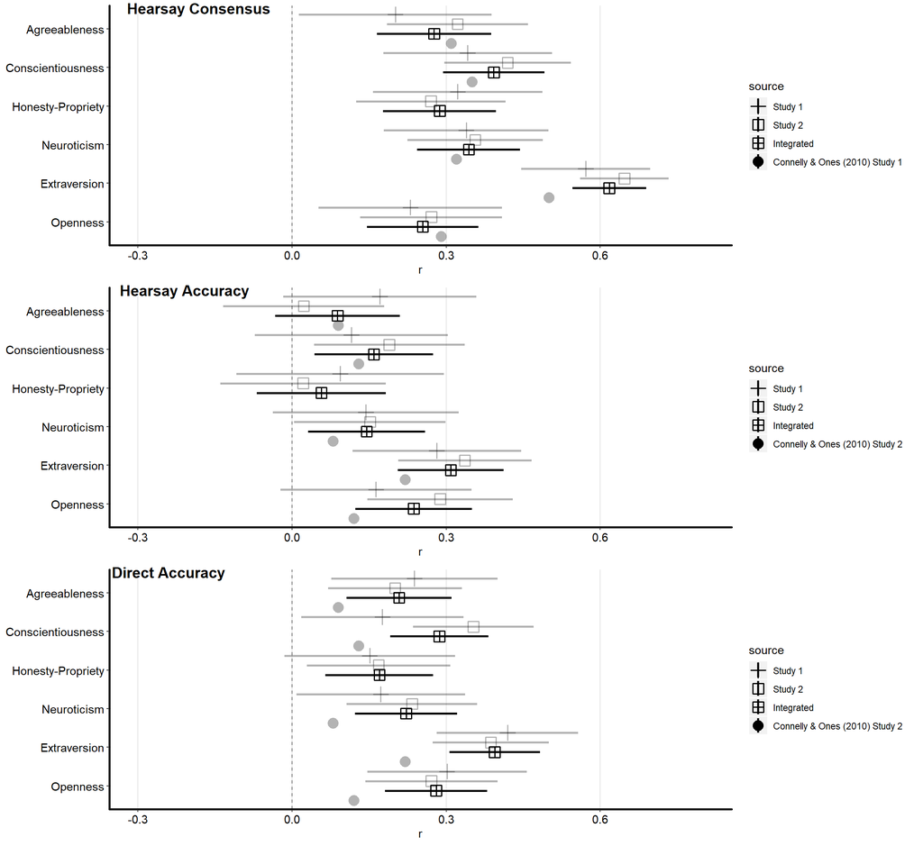

```r
plot_names <- plot_names[str_detect(plot_names, "^plot")]
cowplot::plot_grid(get(plot_names[1]), get(plot_names[2]),
                   get(plot_names[3]), nrow = 3,
                   labels = c("Hearsay Consensus",
                              "Hearsay Accuracy",
                              "Direct Accuracy"),
                   label_y = 1.01,
                   label_x = .06)
```

# Context Manipulation

## Status-relevant context and extraversion

First up, comparing hearsay consensus and accuracy for Extraversion in the status vs. control conditions.

```r
extra_status_noeq <- rep_auto_group_mod(study2,
                                        p1_reports = c("A_C_extraversion", "C_A_extraversion"),
                                        p2_reports = c("B_C_extraversion", "D_A_extraversion"),
                                        target_self = c("C_C_extraversion", "A_A_extraversion"),
                                        group_mod = "condition",
                                        groups_eql = "none",
                                        params_eql = "none",
                                        use_labs = TRUE)

extra_status_hceq <- rep_auto_group_mod(study2,
                                        p1_reports = c("A_C_extraversion", "C_A_extraversion"),
                                        p2_reports = c("B_C_extraversion", "D_A_extraversion"),
                                        target_self = c("C_C_extraversion", "A_A_extraversion"),
                                        group_mod = "condition",
                                        groups_eql = 2:3,
                                        params_eql = "hc",
                                        use_labs = TRUE)

extra_status_haeq <- rep_auto_group_mod(study2,
                                        p1_reports = c("A_C_extraversion", "C_A_extraversion"),
                                        p2_reports = c("B_C_extraversion", "D_A_extraversion"),
                                        target_self = c("C_C_extraversion", "A_A_extraversion"),
                                        group_mod = "condition",
                                        groups_eql = 2:3,
                                        params_eql = c("ha"),
                                        use_labs = TRUE)

extra_status_daeq <- rep_auto_group_mod(study2,
                                        p1_reports = c("A_C_extraversion", "C_A_extraversion"),
                                        p2_reports = c("B_C_extraversion", "D_A_extraversion"),
                                        target_self = c("C_C_extraversion", "A_A_extraversion"),
                                        group_mod = "condition",
                                        groups_eql = 2:3,
                                        params_eql = c("da"),
                                        use_labs = TRUE)
```

### Table of Model Comparison For Extraversion across Conditions

```r
extra_status_models <- c("extra_status_hceq",
                         "extra_status_haeq",
                         "extra_status_daeq")
extra_status_models %>%
  map(get) %>%
  map(anova, extra_status_noeq) %>%
  map(as.data.frame) %>%
  map(mutate, delt_aic = AIC - lag(AIC) ,
         delt_bic = BIC - lag(BIC)) %>%
  map_df(slice, -1) %>%
  cbind(comparison = c("Hearsay Consensus Equal",
                       "Hearsay Accuracy Equal",
                       "Direct Accuracy Equal")) %>%
  select(comparison, 5:9) %>%
  rename(pvalue = `Pr(>Chisq)`) %>%
  mutate(comparison = as.character(comparison),
         comparison = ifelse(comparison == "Direct Accuracy Equal",
                             paste0(comparison, footnote_marker_alphabet(1)), comparison),
         pvalue = ifelse(pvalue >= .001,
                         str_pad(str_replace(round(pvalue, 3),
                                             "0.", "."), 4,
                                 side = "right", pad ="0"),
                         "< .001")) %>%
  knitr::kable(caption = "Model Comparison Results for Status-Relevant Context and Extraversion",
               digits = c(NA, 2, 0, NA, 2, 2),
               format = "html", escape = FALSE) %>%
  kable_styling("striped", full_width = F) %>%
  footnote(general = "Each Model is Compared to the Null Model",
           alphabet = "not pre-registered")
```

Model Comparison Results for Status-Relevant Context and Extraversion

| comparison | Chisq diff | Df diff | pvalue | delt_aic | delt_bic |
| --- | --- | --- | --- | --- | --- |
| Hearsay Consensus Equal | 1.35 | 1 | .244 | -0.65 | -3.29 |
| Hearsay Accuracy Equal | 0.12 | 1 | .727 | -1.88 | -4.52 |
| Direct Accuracy Equal<sup>a</sup> | 2.22 | 1 | .136 | 0.22 | -2.42 |

Note:  
Each Model is Compared to the Null Model  
<sup>a</sup> not pre-registered

### Table of Differential Agreement for Extraversion by Condition

```r
ez_differential_group_table(extra_status_noeq) %>%
  mutate(condition = case_when(
  group_label == "grp1" ~ "Affiliation",
  group_label == "grp2" ~ "Neutral/Control",
  group_label == "grp3" ~ "Status"
  ),
  pvalue = ifelse(pvalue >= .001,
                         str_pad(str_replace(round(pvalue, 3), "0.", "."), 4,
                                 side = "right", pad ="0"),
                         "< .001")) %>%
  select(condition, everything(), -group_label) %>%
  knitr::kable(caption = "Differential Results for Extraversion Across Condition",
               digits = c(NA, NA, 2, 2, 2, 3),
               format = "html", escape = FALSE) %>%
  kable_styling("striped", full_width = F)
```

Differential Results for Extraversion Across Condition

| condition | parameter | r | ci_lower | ci_upper | pvalue |
| --- | --- | --- | --- | --- | --- |
| Affiliation | hearsay consensus | 0.69 | 0.55 | 0.82 | < .001 |
| Affiliation | hearsay accuracy | 0.27 | 0.04 | 0.50 | .022 |
| Affiliation | direct accuracy | 0.26 | 0.04 | 0.47 | .020 |
| Neutral/Control | hearsay consensus | 0.57 | 0.41 | 0.74 | < .001 |
| Neutral/Control | hearsay accuracy | 0.40 | 0.19 | 0.60 | < .001 |
| Neutral/Control | direct accuracy | 0.32 | 0.10 | 0.54 | .005 |
| Status | hearsay consensus | 0.68 | 0.54 | 0.82 | < .001 |
| Status | hearsay accuracy | 0.30 | 0.08 | 0.52 | .007 |
| Status | direct accuracy | 0.58 | 0.43 | 0.73 | < .001 |

### Plot of Hearsay Consensus & Accuracy for Extraversion in the Status vs. Control Conditions (Figure 5)

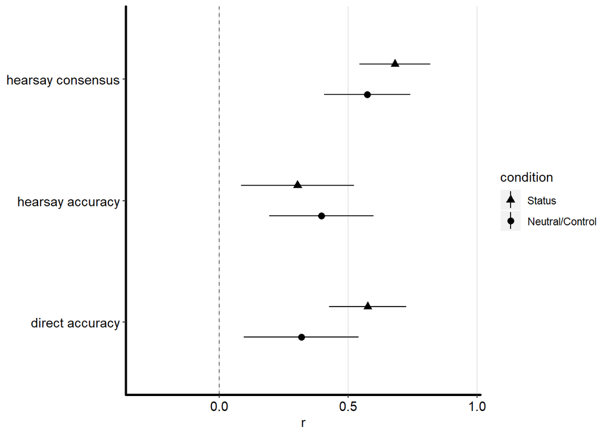

```r
extra_status_plot <- ez_differential_group_table(extra_status_noeq) %>%
  mutate(condition = case_when(group_label == "grp1" ~ "Affiliation",
  group_label == "grp2" ~ "Neutral/Control",
  group_label == "grp3" ~ "Status")) %>%
  filter(condition != "Affiliation") %>%
  ggplot(aes(x = parameter, y = r, shape = condition)) +
  geom_pointrange(aes(ymin = ci_lower, ymax = ci_upper), position = position_dodge(width = .5)) +
  theme_rep_manuscript +
  geom_hline(yintercept = 0, linetype = 2, alpha = .5) +
  scale_y_continuous(limit=c(-0.3, .95))+
  coord_flip()+
  guides(shape=guide_legend(reverse=TRUE)) +
  labs(x = NULL)
extra_status_plot
```

```r
ggsave("Plots/extraXCond.png",
       extra_status_plot,
       device = "png", height = 5, width = 9.5)
```

## Affiliation-relevant context and agreeableness

Next up, comparing hearsay consensus and accuracy for Agreeableness in the affiliation vs. control conditions.

```r
agree_affil_noeq <- rep_auto_group_mod(study2,
                                        p1_reports = c("A_C_agreeableness", "C_A_agreeableness"),
                                        p2_reports = c("B_C_agreeableness", "D_A_agreeableness"),
                                        target_self = c("C_C_agreeableness", "A_A_agreeableness"),
                                        group_mod = "condition",
                                        groups_eql = "none",
                                        params_eql = "none",
                                        use_labs = TRUE)

agree_affil_hceq <- rep_auto_group_mod(study2,
                                        p1_reports = c("A_C_agreeableness", "C_A_agreeableness"),
                                        p2_reports = c("B_C_agreeableness", "D_A_agreeableness"),
                                        target_self = c("C_C_agreeableness", "A_A_agreeableness"),
                                        group_mod = "condition",
                                        groups_eql = 1:2,
                                        params_eql = "hc",
                                        use_labs = TRUE)

agree_affil_haeq <- rep_auto_group_mod(study2,
                                        p1_reports = c("A_C_agreeableness", "C_A_agreeableness"),
                                        p2_reports = c("B_C_agreeableness", "D_A_agreeableness"),
                                        target_self = c("C_C_agreeableness", "A_A_agreeableness"),
                                        group_mod = "condition",
                                        groups_eql = 1:2,
                                        params_eql = c("ha"),
                                        use_labs = TRUE)

agree_affil_daeq <- rep_auto_group_mod(study2,
                                        p1_reports = c("A_C_agreeableness", "C_A_agreeableness"),
                                        p2_reports = c("B_C_agreeableness", "D_A_agreeableness"),
                                        target_self = c("C_C_agreeableness", "A_A_agreeableness"),
                                        group_mod = "condition",
                                        groups_eql = 1:2,
                                        params_eql = c("da"),
                                        use_labs = TRUE)
```

### Table of Model Comparison For Agreeableness across Conditions

```r
agree_affil_models <- c("agree_affil_hceq",
                         "agree_affil_haeq",
                         "agree_affil_daeq")
agree_affil_models %>%
  map(get) %>%
  map(anova, agree_affil_noeq) %>%
  map(as.data.frame) %>%
  map(mutate, delt_aic = AIC - lag(AIC) ,
         delt_bic = BIC - lag(BIC)) %>%
  map_df(slice, -1) %>%
  cbind(comparison = c("Hearsay Consensus Equal",
                       "Hearsay Accuracy Equal",
                       "Direct Accuracy Equal")) %>%
  select(comparison, 5:9) %>%
  rename(pvalue = `Pr(>Chisq)`) %>%
  mutate(comparison = as.character(comparison),
         comparison = ifelse(comparison == "Direct Accuracy Equal",
                             paste0(comparison, footnote_marker_alphabet(1)), comparison),
         pvalue = ifelse(pvalue >= .001,
                         str_pad(str_replace(round(pvalue, 3),
                                             "0.", "."), 4,
                                 side = "right", pad ="0"),
                         "< .001")) %>%
  knitr::kable(caption = "Model Comparison Results for Affiliation-Relevant Context and Agreeableness",
               digits = c(NA, 2, 0, NA, 2, 2),
               format = "html", escape = FALSE) %>%
  kable_styling("striped", full_width = F) %>%
  footnote(general = "Each Model is Compared to the Null Model",
           alphabet = "not pre-registered")
```

Model Comparison Results for Affiliation-Relevant Context and Agreeableness

| comparison | Chisq diff | Df diff | pvalue | delt_aic | delt_bic |
| --- | --- | --- | --- | --- | --- |
| Hearsay Consensus Equal | 0.11 | 1 | .741 | -1.89 | -4.54 |
| Hearsay Accuracy Equal | 0.94 | 1 | .333 | -1.06 | -3.71 |
| Direct Accuracy Equal<sup>a</sup> | 0.01 | 1 | .930 | -1.99 | -4.64 |

Note:  
Each Model is Compared to the Null Model  
<sup>a</sup> not pre-registered

### Table of Differential Agreement for Agreeableness by Condition

```r
ez_differential_group_table(agree_affil_noeq) %>%
  mutate(condition = case_when(
  group_label == "grp1" ~ "Affiliation",
  group_label == "grp2" ~ "Neutral/Control",
  group_label == "grp3" ~ "Status"
  ),
  pvalue = ifelse(pvalue >= .001,
                         str_pad(str_replace(round(pvalue, 3), "0.", "."), 4,
                                 side = "right", pad ="0"),
                         "< .001")) %>%
  select(condition, everything(), -group_label) %>%
  knitr::kable(caption = "Differential Results for Agreeableness Across Condition",
               digits = c(NA, NA, 2, 2, 2, 3),
               format = "html", escape = FALSE) %>%
  kable_styling("striped", full_width = F)
```

Differential Results for Agreeableness Across Condition

| condition | parameter | r | ci_lower | ci_upper | pvalue |
| --- | --- | --- | --- | --- | --- |
| Affiliation | hearsay consensus | 0.34 | 0.10 | 0.58 | .006 |
| Affiliation | hearsay accuracy | 0.26 | 0.00 | 0.53 | .053 |
| Affiliation | direct accuracy | 0.19 | -0.06 | 0.43 | .136 |
| Neutral/Control | hearsay consensus | 0.41 | 0.19 | 0.62 | < .001 |
| Neutral/Control | hearsay accuracy | 0.03 | -0.26 | 0.32 | .824 |
| Neutral/Control | direct accuracy | 0.21 | -0.01 | 0.43 | .060 |
| Status | hearsay consensus | 0.23 | -0.03 | 0.48 | .083 |
| Status | hearsay accuracy | -0.17 | -0.43 | 0.09 | .192 |
| Status | direct accuracy | 0.15 | -0.08 | 0.37 | .196 |

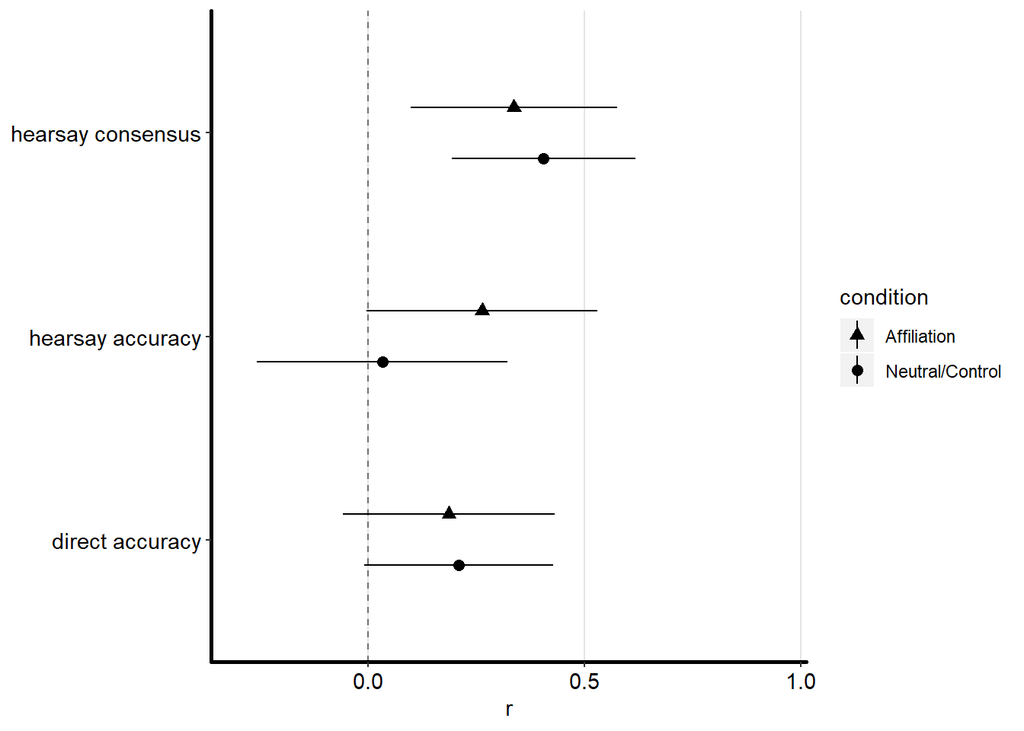

```r
agree_affil_plot <- ez_differential_group_table(agree_affil_noeq) %>%
  mutate(condition = case_when(group_label == "grp1" ~ "Affiliation",
  group_label == "grp2" ~ "Neutral/Control",
  group_label == "grp3" ~ "Status"),
  condition = fct_relevel(condition,
                                 "Neutral/Control",
                                 "Affiliation",
                                 "Status")) %>%
  filter(condition != "Status") %>%
  ggplot(aes(x = parameter, y = r, shape = condition)) +
  geom_pointrange(aes(ymin = ci_lower, ymax = ci_upper), position = position_dodge(width = .5)) +
  theme_rep_manuscript +
  geom_hline(yintercept = 0, linetype = 2, alpha = .5) +
  scale_y_continuous(limit=c(-0.3, .95))+
  coord_flip()+
  guides(shape=guide_legend(reverse=TRUE)) +
  labs(x = NULL)
agree_affil_plot
```

```r
ggsave("Plots/agreeXCond.png",
       agree_affil_plot,
       device = "png", height = 5, width = 9.5)
```

# Consequences

## Effects of reputation on leadership judgments

### Pre-registered Mediation Model: Extraversion to Leadership

This is a pre-registerd analysis looking at whether P1’s perception of thr target’s Extraversion influences P2’s perception of the target’s Extraversion, which in turn influences their perception of the target’s leadership potential. It was pre-registered as hypothesis 3 on OSF.

```r
extraversion_status_med_model_h3 <-'
# Model for A-B-C triad
B_C_contextitem_goodleader ~ b*B_C_extraversion + c*A_C_extraversion
B_C_extraversion ~ a*A_C_extraversion

# Model for C-D-A triad
D_A_contextitem_goodleader ~ b*D_A_extraversion + c*C_A_extraversion
D_A_extraversion ~ a*C_A_extraversion

# variances
B_C_contextitem_goodleader ~~ v_P2_gl*B_C_contextitem_goodleader
D_A_contextitem_goodleader ~~ v_P2_gl*D_A_contextitem_goodleader
B_C_extraversion ~~ v_P2*B_C_extraversion
D_A_extraversion ~~ v_P2*D_A_extraversion
A_C_extraversion ~~ v_P1*A_C_extraversion
C_A_extraversion ~~ v_P1*C_A_extraversion

# intercepts
B_C_contextitem_goodleader ~ int_P2_gl*1
D_A_contextitem_goodleader ~ int_P2_gl*1
B_C_extraversion ~ int_P2*1
D_A_extraversion ~ int_P2*1
A_C_extraversion ~ int_P1*1
C_A_extraversion ~ int_P1*1

# indirect (mediated) effect
indirecteffect := a*b
'
fit_extraversion_status_med_model_h3 <-sem(extraversion_status_med_model_h3,
                                            data = study2,
                                            missing="FIML",
                                            se="bootstrap",
                                            fixed.x=TRUE)

summary(fit_extraversion_status_med_model_h3)
```

```
## lavaan 0.6-5 ended normally after 24 iterations
##
##   Estimator                                         ML
##   Optimization method                           NLMINB
##   Number of free parameters                         19
##   Number of equality constraints                     9
##   Row rank of the constraints matrix                 9
##
##                                                   Used       Total
##   Number of observations                           105         108
##   Number of missing patterns                         3
##
## Model Test User Model:
##
##   Test statistic                                26.376
##   Degrees of freedom                                17
##   P-value (Chi-square)                           0.068
##
## Parameter Estimates:
##
##   Standard errors                            Bootstrap
##   Number of requested bootstrap draws             1000
##   Number of successful bootstrap draws            1000
##
## Regressions:
##                                Estimate  Std.Err  z-value  P(>|z|)
##   B_C_contextitem_goodleader ~
##     B_C_xtrvrs (b)                0.767    0.148    5.168    0.000
##     A_C_xtrvrs (c)                0.071    0.137    0.521    0.603
##   B_C_extraversion ~
##     A_C_xtrvrs (a)                0.735    0.062   11.914    0.000
##   D_A_contextitem_goodleader ~
##     D_A_xtrvrs (b)                0.767    0.148    5.168    0.000
##     C_A_xtrvrs (c)                0.071    0.137    0.521    0.603
##   D_A_extraversion ~
##     C_A_xtrvrs (a)                0.735    0.062   11.914    0.000
##
## Covariances:
##                                 Estimate  Std.Err  z-value  P(>|z|)
##  .B_C_contextitem_goodleader ~~
```

[output cut: 8 more lines]

```
##     A_C_xt  (i_P1)    3.226    0.047   68.902    0.000
##     C_A_xt  (i_P1)    3.226    0.047   68.902    0.000
##
## Variances:
##                    Estimate  Std.Err  z-value  P(>|z|)
##    .B_C_c_ (v_P2_)    0.968    0.103    9.422    0.000
##    .D_A_c_ (v_P2_)    0.968    0.103    9.422    0.000
##    .B_C_xt  (v_P2)    0.377    0.042    9.057    0.000
##    .D_A_xt  (v_P2)    0.377    0.042    9.057    0.000
##     A_C_xt  (v_P1)    0.501    0.044   11.256    0.000
##     C_A_xt  (v_P1)    0.501    0.044   11.256    0.000
##
## Defined Parameters:
##                    Estimate  Std.Err  z-value  P(>|z|)
##     indirecteffect    0.564    0.112    5.042    0.000
```

#### Table for Extraversion to Leadership Mediation model

```r
parameterestimates(fit_extraversion_status_med_model_h3) %>%
  as.data.frame() %>%
  filter(label == "a" |
         label == "b" |
         label == "c" |
         label == "indirecteffect") %>%
  rename(ci_upper = ci.upper,
         ci_lower = ci.lower) %>%
  mutate(parameter = case_when(label == "b" ~ "P2(T) Extraversion -> P2(T) Leadership",
                              label == "c" ~ "P1(T) Extraversion -> P2(T) Leadership",
                              label == "a" ~ "P1(T) Extraversion -> P2(T) Extraversion",
                              label == "indirecteffect" ~ "Mediated Effect"),
         label == fct_relevel(label,
                             "a",
                             "b",
                             "c"),
        pvalue = ifelse(pvalue >= .001,
                        str_pad(str_replace(round(pvalue, 3),
                                            "0.", "."), 4,
                                side = "right", pad ="0"),
                        "< .001"),
        est = round(est, 2),
        est = ifelse(str_detect(est, "\\..$"), paste0(est, "0"),
                   ifelse(str_detect(est, "^0$"), paste0(est, ".00"), est)),
        est = cell_spec(est, "html",
                            bold = ifelse(abs(z) > 1.96, TRUE, FALSE)),
        ci_lower = round(ci_lower, 2),
        ci_lower = ifelse(str_detect(ci_lower, "\\..$"), paste0(ci_lower, "0"),
                   ifelse(str_detect(ci_lower, "^0$"), paste0(ci_lower, ".00"), ci_lower)),
        ci_lower = cell_spec(ci_lower, "html",
                            bold = ifelse(abs(z) > 1.96, TRUE, FALSE)),
        ci_upper = round(ci_upper, 2),
        ci_upper = ifelse(str_detect(ci_upper, "\\..$"), paste0(ci_upper, "0"),
                   ifelse(str_detect(ci_upper, "^0$"), paste0(ci_upper, ".00"), ci_upper)),
        ci_upper = cell_spec(ci_upper, "html",
                            bold = ifelse(abs(z) > 1.96, TRUE, FALSE)),
        z = round(z, 2)) %>%
  arrange(label) %>%
  select(parameter, est, ci_lower, ci_upper, z, pvalue) %>%
  distinct() %>%
  knitr::kable(caption = "Extraversion and Leadership Mediation Results",
              format = "html", escape = F) %>%
 kable_styling("striped", full_width = F)
```

Extraversion and Leadership Mediation Results

| parameter | est | ci_lower | ci_upper | z | pvalue |
| --- | --- | --- | --- | --- | --- |
| P1(T) Extraversion -> P2(T) Extraversion | 0.74 | 0.62 | 0.86 | 11.91 | < .001 |
| P2(T) Extraversion -> P2(T) Leadership | 0.77 | 0.48 | 1.07 | 5.17 | < .001 |
| P1(T) Extraversion -> P2(T) Leadership | 0.07 | -0.19 | 0.36 | 0.52 | .603 |
| Mediated Effect | 0.56 | 0.35 | 0.80 | 5.04 | < .001 |

Our results are consistent with our hypothesis: P2’s perception of the target’s leadership is infleunced by their perception of the target’s Extraversion, which is in turn influenced by P1’s perception of the target’s Extraversion.

### Additional Model: All Big Six and Leadership

```r
big6_status_multi_med_model_h3alt <-'
# Model for A-B-C triad
B_C_contextitem_goodleader ~ b1*B_C_extraversion + b2*B_C_agreeableness + b3*B_C_conscientiousness + b4*B_C_neuroticism + b5*B_C_openness + b6*B_C_hp + c1*A_C_extraversion + c2*A_C_agreeableness + c3*A_C_conscientiousness + c4*A_C_neuroticism + c5*A_C_openness + c6*A_C_hp

B_C_extraversion      ~ a1*A_C_extraversion
B_C_agreeableness     ~ a2*A_C_agreeableness
B_C_conscientiousness ~ a3*A_C_conscientiousness
B_C_neuroticism       ~ a4*A_C_neuroticism
B_C_openness          ~ a5*A_C_openness
B_C_hp                ~ a6*A_C_hp

# Model for C-D-A triad
D_A_contextitem_goodleader ~ b1*D_A_extraversion + b2*D_A_agreeableness + b3*D_A_conscientiousness + b4*D_A_neuroticism + b5*D_A_openness + b6*D_A_hp + c1*C_A_extraversion + c2*C_A_agreeableness + c3*C_A_conscientiousness + c4*C_A_neuroticism + c5*C_A_openness + c6*C_A_hp

D_A_extraversion      ~ a1*C_A_extraversion
D_A_agreeableness     ~ a2*C_A_agreeableness
D_A_conscientiousness ~ a3*C_A_conscientiousness
D_A_neuroticism       ~ a4*C_A_neuroticism
D_A_openness          ~ a5*C_A_openness
D_A_hp                ~ a6*C_A_hp

# variances
B_C_contextitem_goodleader ~~ v_P2_gl*B_C_contextitem_goodleader
D_A_contextitem_goodleader ~~ v_P2_gl*D_A_contextitem_goodleader
B_C_extraversion ~~ v_P2_ex*B_C_extraversion
D_A_extraversion ~~ v_P2_ex*D_A_extraversion
B_C_agreeableness ~~ v_P2_ag*B_C_agreeableness
D_A_agreeableness ~~ v_P2_ag*D_A_agreeableness
B_C_conscientiousness ~~ v_P2_co*B_C_conscientiousness
D_A_conscientiousness ~~ v_P2_co*D_A_conscientiousness
B_C_neuroticism ~~ v_P2_ne*B_C_neuroticism
D_A_neuroticism ~~ v_P2_ne*D_A_neuroticism
B_C_openness ~~ v_P2_op*B_C_openness
D_A_openness ~~ v_P2_op*D_A_openness
B_C_hp ~~ v_P2_hp*B_C_hp
D_A_hp ~~ v_P2_hp*D_A_hp

A_C_extraversion ~~ v_P1_ex*A_C_extraversion
C_A_extraversion ~~ v_P1_ex*C_A_extraversion
A_C_agreeableness ~~ v_P1_ag*A_C_agreeableness
C_A_agreeableness ~~ v_P1_ag*C_A_agreeableness
A_C_conscientiousness ~~ v_P1_co*A_C_conscientiousness
C_A_conscientiousness ~~ v_P1_co*C_A_conscientiousness
A_C_neuroticism ~~ v_P1_ne*A_C_neuroticism
C_A_neuroticism ~~ v_P1_ne*C_A_neuroticism
A_C_openness ~~ v_P1_op*A_C_openness
C_A_openness ~~ v_P1_op*C_A_openness
A_C_hp ~~ v_P1_hp*A_C_hp
C_A_hp ~~ v_P1_hp*C_A_hp


# intercepts

B_C_contextitem_goodleader ~ int_P2_gl*1
D_A_contextitem_goodleader ~ int_P2_gl*1
B_C_extraversion ~ int_P2_ex*1
D_A_extraversion ~ int_P2_ex*1
B_C_agreeableness ~ int_P2_ag*1
D_A_agreeableness ~ int_P2_ag*1
B_C_conscientiousness ~ int_P2_co*1
D_A_conscientiousness ~ int_P2_co*1
B_C_neuroticism ~ int_P2_ne*1
D_A_neuroticism ~ int_P2_ne*1
B_C_openness ~ int_P2_op*1
D_A_openness ~ int_P2_op*1
B_C_hp ~ int_P2_hp*1
D_A_hp ~ int_P2_hp*1

A_C_extraversion ~ int_P1_ex*1
C_A_extraversion ~ int_P1_ex*1
A_C_agreeableness ~ int_P1_ag*1
C_A_agreeableness ~ int_P1_ag*1
A_C_conscientiousness ~ int_P1_co*1
C_A_conscientiousness ~ int_P1_co*1
A_C_neuroticism ~ int_P1_ne*1
C_A_neuroticism ~ int_P1_ne*1
A_C_openness ~ int_P1_op*1
C_A_openness ~ int_P1_op*1
A_C_hp ~ int_P1_hp*1
C_A_hp ~ int_P1_hp*1


# indirect (mediated) effect
indirect_ex := a1*b1
indirect_ag := a2*b2
indirect_co := a3*b3
indirect_ne := a4*b4
indirect_op := a5*b5
indirect_hp := a6*b6
'
fit_big6_status_multi_med_model_h3alt <-sem(big6_status_multi_med_model_h3alt,
                                            data = study2,
                                            missing = "FIML",
                                            se = "bootstrap",
                                            fixed.x = TRUE)

summary(fit_big6_status_multi_med_model_h3alt)
```

```
## lavaan 0.6-5 ended normally after 93 iterations
##
##   Estimator                                         ML
##   Optimization method                           NLMINB
##   Number of free parameters                         89
##   Number of equality constraints                    44
##   Row rank of the constraints matrix                44
##
##                                                   Used       Total
##   Number of observations                           105         108
##   Number of missing patterns                         3
##
## Model Test User Model:
##
##   Test statistic                              1001.333
##   Degrees of freedom                               332
##   P-value (Chi-square)                           0.000
##
## Parameter Estimates:
##
##   Standard errors                            Bootstrap
##   Number of requested bootstrap draws             1000
##   Number of successful bootstrap draws            1000
##
## Regressions:
##                                Estimate  Std.Err  z-value  P(>|z|)
##   B_C_contextitem_goodleader ~
##     B_C_xtrvr (b1)                0.491    0.151    3.247    0.001
##     B_C_grbln (b2)               -0.253    0.252   -1.000    0.317
##     B_C_cnscn (b3)                0.599    0.197    3.034    0.002
##     B_C_nrtcs (b4)               -0.310    0.204   -1.518    0.129
##     B_C_pnnss (b5)                0.606    0.198    3.059    0.002
##     B_C_hp    (b6)               -0.274    0.248   -1.102    0.271
##     A_C_xtrvr (c1)                0.245    0.174    1.407    0.159
##     A_C_grbln (c2)                0.137    0.211    0.650    0.516
##     A_C_cnscn (c3)               -0.005    0.142   -0.035    0.972
##     A_C_nrtcs (c4)                0.186    0.179    1.036    0.300
##     A_C_pnnss (c5)               -0.079    0.133   -0.595    0.552
##     A_C_hp    (c6)                0.114    0.192    0.595    0.552
##   B_C_extraversion ~
```

[output cut: 93 more lines]

```
##     A_C_  (v_P1_n)    0.353    0.033   10.786    0.000
##     C_A_  (v_P1_n)    0.353    0.033   10.786    0.000
##     A_C_  (v_P1_p)    0.326    0.041    7.977    0.000
##     C_A_  (v_P1_p)    0.326    0.041    7.977    0.000
##     A_C_  (v_P1_h)    0.335    0.026   12.707    0.000
##     C_A_  (v_P1_h)    0.335    0.026   12.707    0.000
##
## Defined Parameters:
##                    Estimate  Std.Err  z-value  P(>|z|)
##     indirect_ex       0.361    0.112    3.213    0.001
##     indirect_ag      -0.079    0.082   -0.959    0.338
##     indirect_co       0.256    0.099    2.595    0.009
##     indirect_ne      -0.106    0.072   -1.471    0.141
##     indirect_op       0.118    0.050    2.366    0.018
##     indirect_hp      -0.071    0.066   -1.087    0.277
```